# CS 4650/7650 - Natural Language - HW - 1

Georgia Tech, Summer 2025 (Instructor: Kartik Goyal)

Welcome to the first full programming assignment for CS 4650/7650!

In this assignment, you will be implementing different deep learning models for text classification using the [20 Newsgroups](http://qwone.com/~jason/20Newsgroups/). It is esentially classifying news articles into different topics. This assignment will start with with data preprocessing techniques, implementing a baseline, and building up from there to more advanced model. It will cover basics of attention mechanism, something very central to modern NLP systems, and present you an opportunity to analyse different aspects of your training model.

This assignment will help you diver deeper into the world of Neural Networks and how to implement them for one application in Natural Language Processing. You are expected to have a good understanding of NumPy and PyTorch before starting this assignment.

- NumPy Quickstarter Guide: https://numpy.org/doc/stable/user/quickstart.html
- A good tutorial on PyTorch: https://www.youtube.com/watch?v=OIenNRt2bjg
- Detailed Documentation of PyTorch: https://pytorch.org/docs/stable/index.html
- Lecture Material on PyTorch and HuggingFace: https://github.com/neelabhsinha/cs7650-gatech-nlp-pytorch-huggingface-tutorial

DO NOT CHANGE the names of any of the files and contents outside the cells where you have to write code.

NOTE: DO NOT USE ANY OTHER EXTERNAL LIBRARIES FOR THIS ASSIGNMENT

DEADLINE: July 21, 2025, 11:59 PM

| Section | Part | Points |
| --- | --- | --- |
| 1 | Loading and Preprocessing Data | 7 |
| 2 | Neural Bag of Words (NBOW) | 3 |
| 3 | Model Training (utilities for all models) | 15 |
| 4 | Deep Averaging Networks (DANs) | 8 |
| 5 | Attention-based Models | 30 |
| 6 | Perceptron and Hinge Losses | 16 |
| 7 | Analysis | 21 |
| 8 | Bonus: Improving Attention Models | 10 |
| - | Total | 100 + 10 = 110 |

All the best and happy coding!

## 0. Setup

```python
%load_ext autoreload
%autoreload 2

import sys

# Check what version of Python is running
print(sys.version)
```

```
3.11.13 (main, Jun  5 2025, 13:12:00) [GCC 11.2.0]
```

```python
# export
import os
```

```python
# folder_path = '/content/drive/My Drive/path/to/folder/HW0'
# the above is what folder path should look like the folder path if you execute in colab
folder_path = '.'

# Files in the folder -
os.listdir(folder_path)
os.chdir(folder_path)
```

```python
# DO NOT CHANGE THIS CELL
# RUN THIS CELL ONLY IF RUNNING ON PACE-ICE

# You can ignore this cell if you have already changed the symlink of .cache/ to a location in scratch folder


# override the huggingface cache path and nltk cache path
dirs = {
    "HF_HOME":"~/scratch/hf_cache",
    "TRITON_CACHE_DIR":"~/scratch/triton_cache",
    "TORCHINDUCTOR_CACHE_DIR":"~/scratch/inductor_cache",
    'NLTK_DATA':"~/scratch/nltk_data"
}

for name in dirs:
    d = dirs[name]
    path = os.path.expanduser(d)
    print(name)
    print(path)
    os.makedirs(path, exist_ok=True)
    # making sure the cache dirs are rwx for owner
    os.chmod(path, 0o700)
    os.environ[name] = path
```

```
HF_HOME
/home/jblevins32/scratch/hf_cache
TRITON_CACHE_DIR
/home/jblevins32/scratch/triton_cache
TORCHINDUCTOR_CACHE_DIR
/home/jblevins32/scratch/inductor_cache
NLTK_DATA
/home/jblevins32/scratch/nltk_data
```

```python
# export
# Importing required libraries
# Do not change the libraries already imported or import additional libraries
import torch
import torch.nn as nn
import random
import numpy as np
from collections import Counter
import re
import html
import pandas as pd
from tqdm import tqdm
import torch.nn as nn
import torch.nn.functional as F
from torch.utils.data import Dataset, RandomSampler, DataLoader
from torch.nn.utils.rnn import pad_sequence
from sklearn.metrics import accuracy_score, f1_score, confusion_matrix, ConfusionMatrixDisplay
import matplotlib.pyplot as plt
```

```python
# export
# SOME UTILITY FUNCTIONS - DO NOT CHANGE
def save_checkpoint(model, model_name, loss_fn='ce'):
    file_path = os.path.join(os.getcwd(), 'model_weights', f'checkpoint_{model_name}_{loss_fn}.pt')
    os.makedirs(os.path.join(os.getcwd(), 'model_weights'), exist_ok=True)
    checkpoint = { # create a dictionary with all the state information
        'model_state_dict': model.state_dict()
    }
    torch.save(checkpoint, file_path)
    print(f"Checkpoint saved to {file_path}")

def load_checkpoint(model, model_name, loss_fn='ce', map_location='cpu'):
    file_path = os.path.join(os.getcwd(), 'model_weights', f'checkpoint_{model_name}_{loss_fn}.pt')
    checkpoint = torch.load(file_path, map_location=map_location) # load the checkpoint, ensure correct device
    model.load_state_dict(checkpoint['model_state_dict'])
```

```python
# SOME UTILITY FUNCTIONS - DO NOT CHANGE
def plot_loss(train_loss_over_time, val_loss_over_time, model_name):
    epochs = range(1, len(train_loss_over_time) + 1)

    plt.figure(figsize=(10, 6))
    plt.plot(epochs, train_loss_over_time, color='red', label='Train Loss')
    plt.plot(epochs, val_loss_over_time, color='blue', label='Val Loss')

    plt.xlabel('Epochs')
    plt.ylabel('Loss')
    plt.title(f'Training and Validation Loss for {model_name}')
    plt.legend()
    plt.grid(True)
    plt.show()
```

```python
#export
# Defining global constants - DO NOT CHANGE THESE VALUES (except batch size if you have memory issues)
RANDOM_SEED = 42
PADDING_VALUE = 0
UNK_VALUE     = 1
BATCH_SIZE = 128

torch.manual_seed(RANDOM_SEED)
random.seed(RANDOM_SEED)
np.random.seed(RANDOM_SEED)
device = torch.device('cuda' if torch.cuda.is_available() else('mps' if torch.backends.mps.is_available() else 'cpu'))
```

```python
# This is how we select a GPU if it's available on your computer or in the Colab environment.
print('Device of execution - ', device)
```

```
Device of execution -  cpu
```

## 1. Preprocessing [7 points - Programming]

### 1.1. Data Cleaning Methods [0 points]

The following cell defines some methods to clean the dataset. Do not edit it, but feel free to take a look at some of the operations it's doing.

```python
#export
# example code taken from fast-bert
# DO NOT CHANGE THIS CELL

def spec_add_spaces(t: str) -> str:
    "Add spaces around / and # in `t`. \n"
    return re.sub(r"([/#\n])", r" \1 ", t)

def rm_useless_spaces(t: str) -> str:
    "Remove multiple spaces in `t`."
    return re.sub(" {2,}", " ", t)

def replace_multi_newline(t: str) -> str:
    return re.sub(r"(\n(\s)*){2,}", "\n", t)

def fix_html(x: str) -> str:
    "List of replacements from html strings in `x`."
    re1 = re.compile(r"  +")
    x = (
        x.replace("#39;", "'")
        .replace("amp;", "&")
        .replace("#146;", "'")
        .replace("nbsp;", " ")
        .replace("#36;", "$")
        .replace("\\n", "\n")
        .replace("quot;", "'")
        .replace("<br />", "\n")
        .replace('\\"', '"')
        .replace(" @.@ ", ".")
        .replace(" @-@ ", "-")
        .replace(" @,@ ", ",")
        .replace("\\", " \\ ")
    )
    return re1.sub(" ", html.unescape(x))

def clean_text(input_text):
    text = fix_html(input_text)
    text = replace_multi_newline(text)
    text = spec_add_spaces(text)
    text = rm_useless_spaces(text)
    text = text.strip()
    return text
```

### 1.2. Data Cleaning and Tokenizing [0 points]

Clean the data using the methods above and tokenize it using NLTK

```python
# DO NOT CHANGE THIS CELL
# Downloading the NLTK tokenizer
import nltk
nltk.download('punkt')
nltk.download('punkt_tab')
# Tokenizing the text
df = pd.read_csv("vocab.csv")
df["tokenized"] = df["data"].apply(lambda x: nltk.word_tokenize(clean_text(x.lower())))
func = lambda x: int(x) if x.isdigit() else x
df['target'] = df['target'].apply(func)
print(df.shape)
```

```
(16962, 4)
```

```python
# DO NOT CHANGE THESE VALUES
# Divide the dataset into training and validation sets
# The following two lines are used to load the indices of the training and validation sets
train_indices = np.load("train_indices.npy")
val_indices = np.load("valid_indices.npy")
# The following two lines are used to select the training and validation sets from the dataframe based on the indices loaded above
train_data = df.iloc[train_indices].reset_index(drop=True)
val_data = df.iloc[val_indices].reset_index(drop=True)
func = lambda x: int(x) if str(x).isdigit() else x
val_data['target'] = val_data['target'].apply(func)
val_data = val_data.iloc[1:, :].reset_index(drop=True)
```

Here's what the dataset looks like. You can index into specific rows with pandas, and try to guess some of these yourself :). If you're unfamiliar with pandas, it's a extremely useful and popular library for data analysis and manipulation. You can find their documentation [here](https://pandas.pydata.org/docs/).

Pandas primary data structure is a DataFrame. The following cell will print out the basic information of this structure, including the labeled axes (both columns and rows) as well as show you what the first n (default=5) rows look like

```python
# Print training and validation set heads
train_data.head()
```

|  | data | target | target_names | tokenized |
| --- | --- | --- | --- | --- |
| 0 | From: Mamatha Devineni Ratnam <mr47+@andrew.cm... | 9 | rec.sport.baseball | [from, :, mamatha, devineni, ratnam, <, mr47+,... |
| 1 | From: glazier@isr.harvard.edu (Andrew Baker Gl... | 6 | misc.forsale | [from, :, glazier, @, isr.harvard.edu, (, andr... |
| 2 | From: simon@dcs.warwick.ac.uk (Simon Clippingd... | 0 | alt.atheism | [from, :, simon, @, dcs.warwick.ac.uk, (, simo... |
| 3 | From: keith@cco.caltech.edu (Keith Allan Schne... | 0 | alt.atheism | [from, :, keith, @, cco.caltech.edu, (, keith,... |
| 4 | From: mz@moscom.com (Matthew Zenkar)\\nSubject... | 1 | comp.graphics | [from, :, mz, @, moscom.com, (, matthew, zenka... |

```python
# DO NOT CHANGE THIS CELL
id2label = dict(zip(df['target'], df['target_names']))
id2label = {k: id2label[k] for k in id2label if isinstance(k, int)}
id2label = {k: id2label[k] for k in sorted(id2label)}
id2label
```

```
{0: 'alt.atheism',
 1: 'comp.graphics',
 2: 'comp.os.ms-windows.misc',
 3: 'comp.sys.ibm.pc.hardware',
 4: 'comp.sys.mac.hardware',
 5: 'comp.windows.x',
 6: 'misc.forsale',
 7: 'rec.autos',
 8: 'rec.motorcycles',
 9: 'rec.sport.baseball',
 10: 'rec.sport.hockey',
 11: 'sci.crypt',
 12: 'sci.electronics',
 13: 'sci.med',
 14: 'sci.space',
 15: 'soc.religion.christian',
 16: 'talk.politics.guns',
 17: 'talk.politics.mideast',
 18: 'talk.politics.misc',
 19: 'talk.religion.misc'}
```

This is a dictionary which maps ids to label names. It will be handy in the later part of the assignment.

### 1.3. Vocabulary Building [2 points - Programming]

Generate a vocabulary map for all the words in your dataset

Now that we've loaded this dataset, we need to create a vocab map for words, which will map tokens to numbers. This will be useful later, since torch PyTorch use tensors of sequences of numbers as inputs. **Go to the following cell, and fill out generate_vocab_map.**

```python
# export

def generate_vocab_map(df, cutoff=2):
    """
    This method takes a dataframe and builds a vocabulary to unique number map.
    It uses the cutoff argument to remove rare words occurring <= cutoff times.
    "" and "UNK" are reserved tokens in our vocab that will be useful later.
    You'll also find the Counter imported for you to be useful as well.

    Args:
        df (pandas.DataFrame) : The entire dataset this mapping is built from
        cutoff (int) : We exclude words from the vocab that appear less than or equal to cutoff

    Returns:
        vocab (dict[str] = int) : In vocab, each str is a unique token, and each dict[str] is a
            unique integer ID. Only elements that appear > cutoff times appear in vocab.
        reversed_vocab (dict[int] = str) : A reversed version of vocab, which allows us to retrieve
            words given their unique integer ID. This map will allow us to "decode" integer
            sequences we'll encode using vocab!
    """
    vocab = {"": PADDING_VALUE, "UNK": UNK_VALUE}
    count = Counter(vocab.keys())
    reversed_vocab = {}

    ## YOUR CODE STARTS HERE ##
    # hint: start by iterating over df["tokenized"]
    for tokens in df["tokenized"]:
        for token in tokens:
            if token not in vocab:
                count.update([token])
                if count[token] > cutoff:
                    vocab[token] = len(vocab)

    # Create the reversed vocabulary
    for item in vocab.items():
        reversed_vocab[item[1]] = item[0]

    ## YOUR CODE ENDS HERE ##

    return vocab, reversed_vocab
```

With the methods you have implemented above, you can now generate your dictionaries mapping from word tokens to IDs (and vice versa).

```python
# DO NOT CHANGE THIS CELL
train_vocab, reverse_vocab = generate_vocab_map(train_data)
```

```python
# Check Vocabulary Size - DO NOT CHANGE THIS VALUE
assert len(train_vocab) == 60233, f"Vocabulary is of incorrect size: {len(train_vocab)}"

# No error means you've passed the test!
```

### 1.4. Building a Dataset Class [2 points - Programming]

PyTorch has custom Dataset Classes that have very useful extensions, we want to turn our current pandas DataFrame into a subclass of Dataset so that we can iterate and sample through it for minibatch updates. **In the following cell, fill out the HeadlineDataset class.** Refer to PyTorch documentation on [Dataset Classes](https://pytorch.org/tutorials/beginner/basics/data_tutorial.html) for help.

```python
#export

class HeadlineDataset(Dataset):
    """
    This class takes a Pandas DataFrame and wraps in a Torch Dataset.
    Read more about Torch Datasets here:
    https://pytorch.org/tutorials/beginner/basics/data_tutorial.html
    """
    def __init__(self, vocab, df, max_length=200):
        """
        Initialize the class with appropriate instance variables. In this method, we
        STRONGLY recommend storing the dataframe itself as an instance variable, and
        keeping this method very simple. Leave processing to __getitem__.

        Args:
            vocab (dict[str] = int) : In vocab, each str is a unique token, and each dict[str] is a
                unique integer ID. Only elements that appear > cutoff times appear in vocab.
            df (pandas.DataFrame) : The entire dataset this mapping is built from
            max_length (int) : The max length of a headline we'll allow in our dataset.

        Returns:
            None
        """

        ## YOUR CODE STARTS HERE - initialize parameters ##

        self.vocab = vocab
        self.df = df
        self.max_length = max_length

        ## YOUR CODE ENDS HERE ##

    def __len__(self):
        """
        This method returns the length of the underlying dataframe,
        Args:
            None
        Returns:
            df_len (int) : The length of the underlying dataframe
        """

        df_len = None

        ## YOUR CODE STARTS HERE ##

        df_len = len(self.df)

        ## YOUR CODE ENDS HERE ##

        return df_len

    def __getitem__(self, index: int):
        """
        This method converts a dataframe row (row["tokenized"]) to an encoded torch LongTensor,
        using our vocab map created using generate_vocab_map. Restricts the encoded headline
        length to max_length.

        The purpose of this method is to convert the row - a list of words - into a corresponding
        list of numbers.

        i.e. using a map of {"hi": 2, "hello": 3, "UNK": 0}
        this list ["hi", "hello", "NOT_IN_DICT"] will turn into [2, 3, 0]

        Args:
            index (int) : The index of the dataframe we want to retrieve.

        Returns:
            tokenized_word_tensor (torch.LongTensor) : A 1D tensor of type Long, that has each
                token in the dataframe mapped to a number. These numbers are retrieved from the
                vocab_map we created in generate_vocab_map.

                IMPORTANT: If we filtered out the word because it's infrequent (and it doesn't
                exist in the vocab) we need to replace it w/ the UNK token

            curr_label (int) : Label index of the class between 0 to len(num_classes) - 1 representing which
            class label does this data instance belong to
        """

        tokenized_word_tensor = []

        ## YOUR CODE STARTS HERE ##

        # Iterate through words to create tokenized_word_tensor
        for word in self.df.iloc[index]["tokenized"]:
            if word not in self.vocab:
                tokenized_word_tensor.append(self.vocab["UNK"])
            else:
                tokenized_word_tensor.append(self.vocab[word])

            if len(tokenized_word_tensor) >= self.max_length:
                break

        tokenized_word_tensor = torch.LongTensor(tokenized_word_tensor)
        curr_label = self.df.iloc[index]["target"]

        ## YOUR CODE ENDS HERE ##

        return tokenized_word_tensor, curr_label
```

```python
# DO NOT CHANGE THIS CELL
train_dataset = HeadlineDataset(train_vocab, train_data)
val_dataset   = HeadlineDataset(train_vocab, val_data)

# Now that we're wrapping our dataframes in PyTorch datsets, we can make use of PyTorch Random Samplers, they'll define how our DataLoaders sample elements from the HeadlineDatasets
train_sampler = RandomSampler(train_dataset)
val_sampler   = RandomSampler(val_dataset)
```

```python
# Check Dataset Lengths - DO NOT CHANGE THESE VALUES
assert len(train_dataset) == 15076, f"Training Dataset is of incorrect size {len(train_dataset)}"
assert len(val_dataset)   ==  1885, f"Validation Dataset is of incorrect size {len(val_dataset)}"

# No error means you've passed the test!
```

### 1.5. Finalizing our DataLoader [3 points - Programming]

We can now use PyTorch DataLoaders to batch our data for us. **In the following cell fill out collate_fn.** Refer to PyTorch documentation on [DataLoaders](https://pytorch.org/tutorials/beginner/basics/data_tutorial.html) for help. Apply padding and other post-processing required here.

```python
#export

def collate_fn(batch, padding_value=PADDING_VALUE):
    """
    This function is passed as a parameter to Torch DataSampler. collate_fn collects
    batched rows, in the form of tuples, from a DataLoader and applies some final
    pre-processing.

    Objective:
    In our case, we need to take the batched input array of 1D tokenized_word_tensors,
    and create a 2D tensor that's padded to be the max length from all our tokenized_word_tensors
    in a batch. We're moving from a Python array of tuples, to a padded 2D tensor.

    *HINT*: you're allowed to use torch.nn.utils.rnn.pad_sequence (ALREADY IMPORTED)

    Finally, you can read more about collate_fn here: https://pytorch.org/docs/stable/data.html

    :param batch: PythonArray[tuple(tokenized_word_tensor: 1D Torch.LongTensor, curr_label: int)] of length BATCH_SIZE
    :param padding_value: int

    :return padded_tokens: 2D LongTensor of shape (BATCH_SIZE, max len of all tokenized_word_tensor))
    :return y_labels: 1D FloatTensor of shape (BATCH_SIZE)
    """

    ## YOUR CODE STARTS HERE - take the input and target from batch, pad the tokens, convert batches to tensor ##

    # Unzip the batch
    token_tensors, labels = zip(*batch)

    # Pad the token tensors to the maximum length in the batch
    padded_tokens = torch.nn.utils.rnn.pad_sequence(token_tensors, batch_first=True, padding_value=padding_value)

    y_labels = torch.tensor(labels, dtype=torch.long)  # Convert labels to a tensor of type long


    ## YOUR CODE ENDS HERE ##

    return padded_tokens, y_labels
```

```python
# DO NOT CHANGE THIS CELL
train_iterator = DataLoader(train_dataset, batch_size=BATCH_SIZE, sampler=train_sampler, collate_fn=collate_fn)
val_iterator   = DataLoader(val_dataset, batch_size=BATCH_SIZE, sampler=val_sampler, collate_fn=collate_fn)
```

```python
# Use this to test your collate_fn implementation.
# You can look at the shapes of x and y or put print statements in collate_fn while running this snippet
# DO NOT CHANGE THIS CELL

for x, y in train_iterator:
    print(f'x: {x.shape}')
    print(f'y: {y.shape}')
    break
```

```
x: torch.Size([128, 200])
y: torch.Size([128])
```

## 2. Neural Bag of Words (NBOW) [3 pts - Programming]

Let's move to modeling, now that we have dataset iterators that batch our data for us. The first model is a simple model called NBOW-RAND.

In the following code block, you'll build a feed-forward neural network implementing a neural bag-of-words baseline, NBOW-RAND, described in section 2.1 of [this paper](https://www.aclweb.org/anthology/P15-1162.pdf). You'll find [this](https://pytorch.org/docs/stable/nn.html) page useful for understanding the different layers and [this](https://pytorch.org/tutorials/beginner/nlp/sequence_models_tutorial.html) page useful for how to put them into action.

The core idea behind this baseline is that after we embed each word for a document, we average the embeddings to produce a single vector that hopefully captures some general information spread across the sequence of embeddings. This means we first turn each document of length *n* into a matrix of *nxd*, where *d* is the dimension of the embedding. Then we average this matrix to produce a vector of length *d*, summarizing the contents of the document and proceed with the rest of the network.

While you're working through this implementation, keep in mind how the dimensions change and what each axes represents, as documents will be passed in as minibatches requiring careful selection of which axes you apply certain operations too. Stick to only the architecture described in the instructions below, do not add additional layers, this will impact the validity of local checks.

Refer to the following equation on how to define NBOW -

$$ h_{avg} = \frac{1}{n} \sum_t emb(x_t) $$

The probability of a data instance belonging to class $y_i$ is given by:

$$ p(y|x) = softmax(w^T h_{avg}) $$

where $w \in R^d$ is a parameter vector.

*HINT*: In the forward step, the BATCH_SIZE is the first dimension.

*Hint*: Make sure to handle the case where the input contains pad tokens. We don't want to consider them in our average.

#### 2.1. Define the NBOW model class [3 points]

```python
#export

class NBOW(nn.Module):
    # Instantiate layers for your model-
    #
    # Your model architecture will be a feed-forward neural network.
    #
    # You'll need 3 nn.Modules:
    # 1. An embeddings layer (see nn.Embedding)
    # 2. A linear layer (see nn.Linear)
    #
    # HINT: In the forward step, the BATCH_SIZE is the first dimension.
    #
    def __init__(self, vocab_size, embedding_dim, num_classes=20):
        super().__init__()
        ## YOUR CODE STARTS HERE ##

        # batch size x vocab size x embedding_dim x num_classes
        self.embedding = nn.Embedding(vocab_size, embedding_dim)
        self.linear = nn.Linear(embedding_dim, num_classes, bias=False)
        self.softmax = nn.Softmax(dim=-1)

        ## YOUR CODE ENDS HERE ##

    # Complete the forward pass of the model.
    #
    # Use the output of the embedding layer to create
    # the average vector, which will be input into the
    # linear layer.
    #
    # args:
    # x - 2D LongTensor of shape (BATCH_SIZE, max len of all tokenized_word_tensor))
    #     This is the same output that comes out of the collate_fn function you completed
    def forward(self, x):
        ## Hint: Make sure to handle the case where x contains pad tokens. We don't want to consider them in our average.
        ## YOUR CODE STARTS HERE ##
        # print(x.shape)
        avg = self.get_h_avg(x)
        out = self.linear(avg)
        return out

        ## YOUR CODE ENDS HERE ##

    def get_embeddings(self, x):
        '''
        This function returns the embeddings of the input x
        '''
        ### YOUR CODE STARTS HERE ###

        return self.embedding(x)

        ### YOUR CODE ENDS HERE ###

    def set_embedding_weight(self, weight):
        '''
        This function sets the embedding weights to the input weight. Ensure you aren't recording gradients for this.
        Hint: Refer to nn.Parameter to do this.
        Args:
            weight: torch.tensor of shape (vocab_size, embedding_dim)
        '''
        ### YOUR CODE STARTS HERE ###
        with torch.no_grad():
            self.embedding.weight = nn.Parameter(weight, requires_grad=False)

        ### YOUR CODE ENDS HERE ###

    def get_h_avg(self, x):
        '''
        This function returns the average of the embeddings of the input x
        '''
        ### YOUR CODE STARTS HERE ###
        embeddings = self.get_embeddings(x)
        mask = (x!= PADDING_VALUE)

        # Count the number of non-padding tokens in each sequence for averaging later
        num_non_pads = mask.sum(dim=1).unsqueeze(-1)

        # Apply the mask to the embeddings
        embeddings = embeddings * mask.unsqueeze(-1)

        avg =  embeddings.sum(dim=1)/num_non_pads # gives batch_size x 1

        return avg
        ### YOUR CODE ENDS HERE ###
```

```python
# local test for sanity:
# DO NOT CHANGE THIS CELL

def nbow_test_local():
    embedding_dim = 10
    vocab_size = 5
    model = NBOW(vocab_size=vocab_size, embedding_dim=embedding_dim)
    for _, module in model.named_parameters():
        if hasattr(module, "data"):
            nn.init.constant_(module, 0.1)
    input = torch.arange(12).reshape(2,6) % vocab_size
    expected_result = torch.tensor(
        [[0.1000, 0.1000, 0.1000, 0.1000, 0.1000, 0.1000, 0.1000, 0.1000, 0.1000,
         0.1000, 0.1000, 0.1000, 0.1000, 0.1000, 0.1000, 0.1000, 0.1000, 0.1000,
         0.1000, 0.1000],
        [0.1000, 0.1000, 0.1000, 0.1000, 0.1000, 0.1000, 0.1000, 0.1000, 0.1000,
         0.1000, 0.1000, 0.1000, 0.1000, 0.1000, 0.1000, 0.1000, 0.1000, 0.1000,
         0.1000, 0.1000]]
    )
    with torch.no_grad():
        local_result = model(input)
    if torch.allclose(expected_result, local_result, rtol=0.001):
        print("Passed local check")
    else:
        print(f"Test failed, expected value was\n{expected_result}\nbut you got:\n{local_result}")

def nbow_test_local_embeddings():
    embedding_dim = 3
    vocab_size = 5
    model = NBOW(embedding_dim=embedding_dim, vocab_size=vocab_size)
    model.set_embedding_weight(torch.arange(15).reshape(5,3) / 50)
    embeddings = model.get_embeddings(torch.tensor([[1,2,3,4,1],[1,2,3,0,0]]))
    correct_embeddings = torch.tensor([[[0.0600, 0.0800, 0.1000],
                                        [0.1200, 0.1400, 0.1600],
                                        [0.1800, 0.2000, 0.2200],
                                        [0.2400, 0.2600, 0.2800],
                                        [0.0600, 0.0800, 0.1000]],

                                        [[0.0600, 0.0800, 0.1000],
                                        [0.1200, 0.1400, 0.1600],
                                        [0.1800, 0.2000, 0.2200],
                                        [0.0000, 0.0200, 0.0400],
                                        [0.0000, 0.0200, 0.0400]]])
    if torch.allclose(embeddings, correct_embeddings, rtol=0.001):
        print("Passed local embedding test")
    else:
        print(f"Embedding Test failed, expected value was\n{correct_embeddings}\nbut you got:\n{embeddings}")
def nbow_test_local_h_avg():
    embedding_dim = 3
    vocab_size = 5
    model = NBOW(embedding_dim=embedding_dim, vocab_size=vocab_size)
    model.set_embedding_weight(torch.arange(15).reshape(5,3) / 50)
    h_avg = model.get_h_avg(torch.tensor([[1,2,3,4,1],[1,2,3,0,0]]))
    correct_h_avg = torch.tensor([[0.1320, 0.1520, 0.1720],
                                  [0.1200, 0.1400, 0.1600]])
    if torch.allclose(h_avg, correct_h_avg, rtol=0.001):
        print("Passed local h_avg test")
    else:
        print(f"h_avg Test failed, expected value was\n{correct_h_avg}\nbut you got:\n{h_avg}")
nbow_test_local()
nbow_test_local_embeddings()
nbow_test_local_h_avg()
```

```
Passed local check
Passed local embedding test
Passed local h_avg test
```

## 3. Model Training [12 points - Programming + 3 points - Non-programming]

Training a PyTorch model involves several key components:

- **Training Loop**: This is the process where the model learns from the training data. In each iteration, the model processes the input data, makes predictions, calculates the loss, and updates its weights using backpropagation.
- **Validation Loop**: Performed after the training loop, this evaluates the model on a separate dataset (validation data) to check its performance. It helps in detecting overfitting.
- **Optimizer**: This is an algorithm that updates the model's weights during training. Common optimizers include SGD, Adam, etc.
- **Criterion (Loss Function)**: This measures how well the model is performing. It calculates the difference between the model's predictions and the actual data. Common loss functions include Mean Squared Error for regression tasks and Cross Entropy Loss for classification.

During training, the optimizer uses the gradient of the loss function to adjust the model's parameters. The model's performance is evaluated periodically on the validation set to monitor its generalization capability. This process continues for a specified number of epochs or until the model achieves a desired level of accuracy.

*Note - In the following code cells (of this section), the above components will be defined. These functions/objects will be used to train and evaluate all your models in this assignment. So, make sure to implement these in a generic way, so that they can be used for all the models.*

### 3.0. Evaluation Metrics [0 points]

Accuracy is a measure used to evaluate classification models, representing the ratio of correctly predicted observations to the total observations. It's simple and intuitive but may not be suitable for imbalanced datasets, as it can be misleading if the class distribution is skewed.

The F1-score, on the other hand, combines precision and recall into a single number. It is particularly useful when dealing with imbalanced datasets or when the cost of false positives and false negatives varies. F1-score provides a better measure of the incorrectly classified cases than the Accuracy Metric. It's calculated as the harmonic mean of precision and recall, thus balancing the two aspects of model performance.

You can read about the terms mentioned above here: https://scikit-learn.org/stable/modules/model_evaluation.html

For this assignment, we are already defining the above metrics for you to use in your implementation

```python
#export
# DO NOT CHANGE THIS CELL
def get_accuracy_and_f1_score(y_true, y_predicted):
    """
    This function takes in two numpy arrays and computes the accuracy and F1 score
    between them. You can use the imported sklearn functions to do this.

    Args:
        y_true (list) : A 1D numpy array of ground truth labels
        y_predicted (list) : A 1D numpy array of predicted labels

    Returns:
        accuracy (float) : The accuracy of the predictions
        f1_score (float) : The F1 score of the predictions
    """

    # Get the accuracy
    accuracy = accuracy_score(y_true, y_predicted)

    # Get the F1 score
    f1 = f1_score(y_true, y_predicted, average='macro')

    return accuracy, f1
```

```python
# DO NOT CHANGE THIS CELL
def plot_confusion_matrix(y_true, y_pred, classes):
    cm = confusion_matrix(y_true, y_pred, labels=range(len(classes)))
    disp = ConfusionMatrixDisplay(confusion_matrix=cm, display_labels=classes)
    disp.plot(cmap=plt.cm.Blues)
    plt.xticks(rotation=90)
    plt.show()
```

### 3.1. Criterion [2 points - Programming]

Criterion in PyTorch, refers to the loss function used to evaluate the model's performance. It quantifies how far off the model's predictions are from the actual target values

In PyTorch, **nn.CrossEntropyLoss()** is used for classification tasks. It first does a softmax on the scores, and then calculates the negative log likelihood. This is why you don't need to do sotmax in the model, you can return the scores. In the cell below, implement this.

```python
#export

def get_criterion(loss_type='ce'):

    ## YOUR CODE STARTS HERE ##

    criterion = nn.CrossEntropyLoss()

    ## YOUR CODE ENDS HERE ##

    return criterion
```

### 3.2. Optimizer [2 points - Programming]

In PyTorch, an optimizer is a tool that updates the weights of the neural network to minimize the loss. Among these, Adam (Adaptive Moment Estimation) is a widely-used optimizer. Adam combines the best properties of the AdaGrad and RMSProp algorithms to handle sparse gradients on noisy problems. It's known for its effectiveness in deep learning models, especially where large datasets and high-dimensional spaces are involved. Adam adjusts the learning rate during training, making it efficient and effective across a wide range of tasks and model architectures.

In the cell below, define your optimizer. We recommend using Adam, but you are free to experiment with other optimizers as well.

The following function takes a model and learning rate value as input, and defines an optimizer for that model's parameters with that learning rate.

*HINT: model.parameters() can give you all the parameters of a PyTorch model*

```python
#export
def get_optimizer(model, learning_rate):
    """
    This function takes a model and a learning rate, and returns an optimizer.
    Feel free to experiment with different optimizers.
    """

    ## YOUR CODE STARTS HERE ##

    optimizer = torch.optim.Adam(model.parameters(), lr=learning_rate)

    ## YOUR CODE ENDS HERE ##

    return optimizer
```

### 3.3. Training Loop [3 points - Programming]

The training loop function in PyTorch is a critical component where the actual learning from data occurs. It typically involves iterating over the training dataset, feeding the data to the model, computing the loss (difference between the predictions and true values), and updating the model's weights.

Creating a training loop involves several steps:

1. Iterate Over Dataset: Loop through the training dataset, often in mini-batches.
2. Forward Pass: Feed the input data to the model to get predictions.
3. Compute Loss: Calculate the loss using a loss function.
4. Backward Pass: Perform backpropagation by calling loss.backward(), which computes the gradient of the loss function with respect to each weight.
5. Update Weights: Use an optimizer (like SGD or Adam) to adjust the weights based on the gradients calculated.
6. Zero the Gradients: Reset the gradients to zero after each mini-batch to prevent accumulation of gradients from multiple passes.

This loop repeats for a specified number of epochs or until a certain level of accuracy or loss is achieved.

In the end, return the mean loss over all samples for this particular iteration

```python
#export
def train_loop(model, criterion, optimizer, iterator, epoch, save_every=10):
    """
    This function is used to train a model for one epoch.
    :param model: The model to be trained
    :param criterion: The loss function
    :param optim: The optimizer
    :param iterator: The training data iterator
    :return: The average loss for this epoch
    """
    model.train() # Is used to put the model in training mode
    total_loss = 0
    for x, y in tqdm(iterator, total=len(iterator), desc="Training Model"):
        ### YOUR CODE STARTS HERE ###

        out = model(x.to(device))
        loss = criterion(out, y.to(device))
        optimizer.zero_grad()  # Zero the gradients before backward pass
        loss.backward()  # Backward pass to compute gradients
        optimizer.step()  # Update the model parameters
        total_loss += loss.item()

        ### YOUR CODE ENDS HERE ###

    average_loss = total_loss / len(iterator)
    return average_loss
```

### 3.4. Validation Loop [3 points - Programming]

The validation loop in PyTorch is where the model's performance is evaluated on a dataset different from the one used for training. It does not involve updating the model's weights, focusing instead on assessing how well the model generalizes to new data. Here's how it typically works:

1. Iterate Over Validation Dataset: Loop through the validation dataset, usually in mini-batches, without the need for shuffling as in the training loop.
2. Forward Pass: Feed the input data to the model to obtain predictions.
3. Compute Loss: Calculate the loss (e.g., Cross-Entropy, Mean Squared Error) to assess the performance on the validation dataset.
4. Calculate Metrics: Besides loss, other performance metrics like accuracy, F1 score, etc., are computed to evaluate model performance.

Note: No Backpropagation: Unlike the training loop, there is no backward pass or weight updates.

The validation loop is crucial for monitoring overfitting and tuning hyperparameters. It provides insight into how the model is likely to perform on unseen data.

```python
# export
def val_loop(model, criterion, iterator):
    """
    This function is used to evaluate a model on the validation set.
    :param model: The model to be evaluated
    :param iterator: The validation data iterator
    :return: true: a Python boolean array of all the ground truth values
             pred: a Python boolean array of all model predictions.
            average_loss: The average loss over the validation set
    """

    true, pred = [], []
    total_loss = 0
    model.eval()
    for x, y in tqdm(iterator, total=len(iterator), desc="Evaluating Model"):
    ### YOUR CODE STARTS HERE ###

        out = model(x.to(device))
        loss = criterion(out, y.to(device))
        total_loss += loss.item()

        true.extend(y.cpu().numpy())
        pred.extend(torch.argmax(out, dim=1).cpu().numpy())

    ### YOUR CODE ENDS HERE ###
    average_loss = total_loss / len(iterator)
    return true, pred, average_loss
```

### 3.5. Training NBOW [3 points - Non-programming]

Assign and tune the below hyperparameters to optimize your model. Make sure that the output graph of the cell where training happens is clear in your submission.

```python
#export
# Assigning hyperparameters and training parameters
# Experiment with different values for these hyperparaters to optimize your model's performance
def get_hyperparams_nbow():
  ### your hyper parameters
  learning_rate = 0.001
  epochs = 150
  embedding_dim = 100
  ###
  return learning_rate, epochs, embedding_dim
```

Since the NBOW model is rather basic, assuming you haven't added any additional layers, there's really only one hyperparameter for the model architecture: the size of the embedding dimension.

The vocab_size parameter here is based on the number of unique words kept in the vocab after removing those occurring too infrequently, so this is determined by our dataset and is in turn not a true hyperparameter (though the cutoff we used previously might be). The embedding_dim parameter dictates what size vector each word can be embedded as.

A special note concerning the model initialization: We're specifically sending the model to the device set in Part 1, to speed up training if the GPU is available. **Be aware**, you'll have to ensure other tensors are on the same device inside your training and validation loops.

```python
# export
def get_nbow_model(vocab_size, embedding_dim):
    """
    This function returns an instance of the NBOW model.
    """
    model = None
    # Define a model and return
    # YOUR CODE STARTS HERE

    model = NBOW(vocab_size=vocab_size, embedding_dim=embedding_dim)

    # YOUR CODE ENDS HERE
    return model
```

```python
t=1
assert t == 2, "Please ensure you have run the previous cells before running this cell."
```

[output not shown]

```python
# This is the main training loop. You'll need to complete the train_loop and val_loop functions.
# You'll also need to complete the criterion and optimizer functions.
# Feel free to experiment with different optimizers and learning rates.
# Do not change anything else in this cell
learning_rate, epochs, embedding_dim = get_hyperparams_nbow()
nbow_model = get_nbow_model(vocab_size= len(train_vocab.keys()), embedding_dim = embedding_dim).to(device)
criterion = get_criterion()
optimizer = get_optimizer(nbow_model, learning_rate)
train_loss_over_time_nbow = []
val_loss_over_time_nbow = []
for epoch in range(epochs):
    train_loss = train_loop(nbow_model, criterion, optimizer, train_iterator, epoch, save_every=2)
    true, pred, val_loss = val_loop(nbow_model, criterion, val_iterator)
    accuracy, f1 = get_accuracy_and_f1_score(true, pred)
    print(f"Epoch {epoch+1} -- Train_Loss: {train_loss} -- Val_Loss: {val_loss} -- Val_Accuracy: {accuracy} -- Val_F1: {f1}")
    train_loss_over_time_nbow.append(train_loss)
    val_loss_over_time_nbow.append(val_loss)
save_checkpoint(nbow_model, 'nbow')
```

```
Epoch 1 -- Train_Loss: 2.9585591898126116 -- Val_Loss: 2.9160719394683836 -- Val_Accuracy: 0.15862068965517243 -- Val_F1: 0.12194906583161216
```

```
Epoch 2 -- Train_Loss: 2.854133692838378 -- Val_Loss: 2.7969975312550863 -- Val_Accuracy: 0.25411140583554376 -- Val_F1: 0.22716584450341765
```

```
Epoch 3 -- Train_Loss: 2.700552841364327 -- Val_Loss: 2.629970741271973 -- Val_Accuracy: 0.3623342175066313 -- Val_F1: 0.33821250805015873
```

```
Epoch 4 -- Train_Loss: 2.5008650149329235 -- Val_Loss: 2.428655989964803 -- Val_Accuracy: 0.44297082228116713 -- Val_F1: 0.4141395309575853
```

```
Epoch 5 -- Train_Loss: 2.2685051752349077 -- Val_Loss: 2.2082247893015543 -- Val_Accuracy: 0.53315649867374 -- Val_F1: 0.5094018957306125
```

```
Epoch 6 -- Train_Loss: 2.0151205376043158 -- Val_Loss: 1.9726858059565227 -- Val_Accuracy: 0.6079575596816976 -- Val_F1: 0.5842526521506645
```

```
Epoch 7 -- Train_Loss: 1.7568685796301244 -- Val_Loss: 1.747322964668274 -- Val_Accuracy: 0.6615384615384615 -- Val_F1: 0.6369476299626631
```

```
Epoch 8 -- Train_Loss: 1.5116832337136996 -- Val_Loss: 1.541643500328064 -- Val_Accuracy: 0.6944297082228117 -- Val_F1: 0.6734680454417059
```

```
Epoch 9 -- Train_Loss: 1.2910262103808128 -- Val_Loss: 1.3568494319915771 -- Val_Accuracy: 0.7352785145888594 -- Val_F1: 0.7207025211506223
```

```
Epoch 10 -- Train_Loss: 1.1005388159873122 -- Val_Loss: 1.1984430789947509 -- Val_Accuracy: 0.7602122015915119 -- Val_F1: 0.7471046648838339
```

```
Epoch 11 -- Train_Loss: 0.9394857620788832 -- Val_Loss: 1.0656962792078655 -- Val_Accuracy: 0.7946949602122015 -- Val_F1: 0.7837419255240514
```

```
Epoch 12 -- Train_Loss: 0.8052554241681503 -- Val_Loss: 0.9591168642044068 -- Val_Accuracy: 0.8063660477453581 -- Val_F1: 0.7977513612327771
```

```
Epoch 13 -- Train_Loss: 0.6937616674576775 -- Val_Loss: 0.8681727131207784 -- Val_Accuracy: 0.8270557029177719 -- Val_F1: 0.818805455373532
```

```
Epoch 14 -- Train_Loss: 0.6016940626047426 -- Val_Loss: 0.7945315877596537 -- Val_Accuracy: 0.8387267904509284 -- Val_F1: 0.8329103556556966
```

```
Epoch 15 -- Train_Loss: 0.5239766010288465 -- Val_Loss: 0.7306176265080769 -- Val_Accuracy: 0.8477453580901857 -- Val_F1: 0.8416668920352344
```

```
Epoch 16 -- Train_Loss: 0.4595043000023244 -- Val_Loss: 0.6759235461552938 -- Val_Accuracy: 0.8567639257294429 -- Val_F1: 0.8514441729180536
```

```
Epoch 17 -- Train_Loss: 0.40448704210378356 -- Val_Loss: 0.6329938709735871 -- Val_Accuracy: 0.8594164456233422 -- Val_F1: 0.8547965367720213
```

```
Epoch 18 -- Train_Loss: 0.35809721835589003 -- Val_Loss: 0.5888974487781524 -- Val_Accuracy: 0.870026525198939 -- Val_F1: 0.8656592619147008
```

```
Epoch 19 -- Train_Loss: 0.3181119782187171 -- Val_Loss: 0.559171320994695 -- Val_Accuracy: 0.8753315649867374 -- Val_F1: 0.8715862230687916
```

```
Epoch 20 -- Train_Loss: 0.2833795269667092 -- Val_Loss: 0.5293297747770945 -- Val_Accuracy: 0.8779840848806366 -- Val_F1: 0.8748269654156614
```

```
Epoch 21 -- Train_Loss: 0.2533210495770988 -- Val_Loss: 0.507978500922521 -- Val_Accuracy: 0.8854111405835544 -- Val_F1: 0.8817166907298724
```

```
Epoch 22 -- Train_Loss: 0.22689222910646664 -- Val_Loss: 0.48106166124343874 -- Val_Accuracy: 0.8912466843501327 -- Val_F1: 0.887466270461403
```

```
Epoch 23 -- Train_Loss: 0.20394149119571103 -- Val_Loss: 0.4625580708185832 -- Val_Accuracy: 0.8960212201591512 -- Val_F1: 0.8924951854267567
```

```
Epoch 24 -- Train_Loss: 0.18361058269264335 -- Val_Loss: 0.44457999666531883 -- Val_Accuracy: 0.8960212201591512 -- Val_F1: 0.8926644531330258
```

```
Epoch 25 -- Train_Loss: 0.1656654790296393 -- Val_Loss: 0.4298419674237569 -- Val_Accuracy: 0.8992042440318302 -- Val_F1: 0.8957092203463579
```

```
Epoch 26 -- Train_Loss: 0.14942414566116818 -- Val_Loss: 0.41831334233283995 -- Val_Accuracy: 0.9013262599469496 -- Val_F1: 0.898200606494615
```

```
Epoch 27 -- Train_Loss: 0.13509722483360162 -- Val_Loss: 0.4062244832515717 -- Val_Accuracy: 0.9039787798408488 -- Val_F1: 0.9012076365712381
```

```
Epoch 28 -- Train_Loss: 0.12239189117641772 -- Val_Loss: 0.3907366176446279 -- Val_Accuracy: 0.9055702917771883 -- Val_F1: 0.9023120281592746
```

```
Epoch 29 -- Train_Loss: 0.11088603296143523 -- Val_Loss: 0.38514338036378226 -- Val_Accuracy: 0.9071618037135278 -- Val_F1: 0.904527557043657
```

```
Epoch 30 -- Train_Loss: 0.1005047297073623 -- Val_Loss: 0.3710360238949458 -- Val_Accuracy: 0.9055702917771883 -- Val_F1: 0.9023380312297133
```

```
Epoch 31 -- Train_Loss: 0.09130643137683303 -- Val_Loss: 0.3660912990570068 -- Val_Accuracy: 0.9103448275862069 -- Val_F1: 0.9068754828127459
```

```
Epoch 32 -- Train_Loss: 0.08293329693882143 -- Val_Loss: 0.35913487275441486 -- Val_Accuracy: 0.9114058355437665 -- Val_F1: 0.9079601903475207
```

```
Epoch 33 -- Train_Loss: 0.07549464317449069 -- Val_Loss: 0.3518919845422109 -- Val_Accuracy: 0.9114058355437665 -- Val_F1: 0.9079819647800609
```

```
Epoch 34 -- Train_Loss: 0.06878721246779976 -- Val_Loss: 0.3436595986286799 -- Val_Accuracy: 0.9119363395225464 -- Val_F1: 0.9086644730550416
```

```
Epoch 35 -- Train_Loss: 0.06268094388483944 -- Val_Loss: 0.3362257828315099 -- Val_Accuracy: 0.9119363395225464 -- Val_F1: 0.9084192585835231
```

```
Epoch 36 -- Train_Loss: 0.05718251548202361 -- Val_Loss: 0.333185609181722 -- Val_Accuracy: 0.9124668435013262 -- Val_F1: 0.9091345935923064
```

```
Epoch 37 -- Train_Loss: 0.05216660502098375 -- Val_Loss: 0.3299025923013687 -- Val_Accuracy: 0.9114058355437665 -- Val_F1: 0.9076890864945544
```

```
Epoch 38 -- Train_Loss: 0.04766049408117088 -- Val_Loss: 0.3259482681751251 -- Val_Accuracy: 0.9145888594164456 -- Val_F1: 0.9107354827328044
```

```
Epoch 39 -- Train_Loss: 0.04355877135896077 -- Val_Loss: 0.3202552795410156 -- Val_Accuracy: 0.9140583554376658 -- Val_F1: 0.9104557014193893
```

```
Epoch 40 -- Train_Loss: 0.039925595382386346 -- Val_Loss: 0.316031884153684 -- Val_Accuracy: 0.9140583554376658 -- Val_F1: 0.910283394172402
```

```
Epoch 41 -- Train_Loss: 0.03660485955049931 -- Val_Loss: 0.31474411189556123 -- Val_Accuracy: 0.9145888594164456 -- Val_F1: 0.9109153891564595
```

```
Epoch 42 -- Train_Loss: 0.0335602963627395 -- Val_Loss: 0.30994466642538704 -- Val_Accuracy: 0.9140583554376658 -- Val_F1: 0.9104850946850943
```

```
Epoch 43 -- Train_Loss: 0.030752382209619223 -- Val_Loss: 0.30352721114953357 -- Val_Accuracy: 0.9156498673740053 -- Val_F1: 0.9119748125556614
```

```
Epoch 44 -- Train_Loss: 0.028292784104281564 -- Val_Loss: 0.30259817639986675 -- Val_Accuracy: 0.9172413793103448 -- Val_F1: 0.9137433319351969
```

```
Epoch 45 -- Train_Loss: 0.026033890899270773 -- Val_Loss: 0.29940170447031655 -- Val_Accuracy: 0.9172413793103448 -- Val_F1: 0.9137699768107238
```

```
Epoch 46 -- Train_Loss: 0.02393275188376843 -- Val_Loss: 0.29960828125476835 -- Val_Accuracy: 0.9177718832891246 -- Val_F1: 0.9144377448593477
```

```
Epoch 47 -- Train_Loss: 0.022040197515260367 -- Val_Loss: 0.29683014154434206 -- Val_Accuracy: 0.9188328912466843 -- Val_F1: 0.915354127841429
```

```
Epoch 48 -- Train_Loss: 0.02035598926467158 -- Val_Loss: 0.2931577702363332 -- Val_Accuracy: 0.9177718832891246 -- Val_F1: 0.9144833075818269
```

```
Epoch 49 -- Train_Loss: 0.018823768327928196 -- Val_Loss: 0.2929665396610896 -- Val_Accuracy: 0.9177718832891246 -- Val_F1: 0.9145666377482813
```

```
Epoch 50 -- Train_Loss: 0.01734907238475852 -- Val_Loss: 0.2898034503062566 -- Val_Accuracy: 0.9193633952254642 -- Val_F1: 0.9159885496662012
```

```
Epoch 51 -- Train_Loss: 0.016069099149208958 -- Val_Loss: 0.28655692636966706 -- Val_Accuracy: 0.9188328912466843 -- Val_F1: 0.9155828816109318
```

```
Epoch 52 -- Train_Loss: 0.014833106706708165 -- Val_Loss: 0.2866183231274287 -- Val_Accuracy: 0.919893899204244 -- Val_F1: 0.9168660849448834
```

```
Epoch 53 -- Train_Loss: 0.013711905998761877 -- Val_Loss: 0.2869360993305842 -- Val_Accuracy: 0.919893899204244 -- Val_F1: 0.9169215423366358
```

```
Epoch 54 -- Train_Loss: 0.012744724821551876 -- Val_Loss: 0.28384348650773367 -- Val_Accuracy: 0.919893899204244 -- Val_F1: 0.9168790109386398
```

```
Epoch 55 -- Train_Loss: 0.011804329065637569 -- Val_Loss: 0.2815361311038335 -- Val_Accuracy: 0.9209549071618037 -- Val_F1: 0.9179179143840683
```

```
Epoch 56 -- Train_Loss: 0.010964332231304656 -- Val_Loss: 0.2814542333285014 -- Val_Accuracy: 0.9209549071618037 -- Val_F1: 0.9179079371477608
```

```
Epoch 57 -- Train_Loss: 0.01017202147661503 -- Val_Loss: 0.28258420825004577 -- Val_Accuracy: 0.9220159151193634 -- Val_F1: 0.918895632696009
```

```
Epoch 58 -- Train_Loss: 0.009457223399510701 -- Val_Loss: 0.28371384739875793 -- Val_Accuracy: 0.9220159151193634 -- Val_F1: 0.9188551666419011
```

```
Epoch 59 -- Train_Loss: 0.008807944781068017 -- Val_Loss: 0.27820706566174824 -- Val_Accuracy: 0.9214854111405836 -- Val_F1: 0.9183944048003431
```

```
Epoch 60 -- Train_Loss: 0.008230800866701846 -- Val_Loss: 0.2799158900976181 -- Val_Accuracy: 0.9209549071618037 -- Val_F1: 0.9178840213640209
```

```
Epoch 61 -- Train_Loss: 0.007679290680798812 -- Val_Loss: 0.2783393224080404 -- Val_Accuracy: 0.9230769230769231 -- Val_F1: 0.9203224066170221
```

```
Epoch 62 -- Train_Loss: 0.007201626123386925 -- Val_Loss: 0.27476517657438915 -- Val_Accuracy: 0.9236074270557029 -- Val_F1: 0.9209016659171867
```

```
Epoch 63 -- Train_Loss: 0.00672454298158192 -- Val_Loss: 0.28035644590854647 -- Val_Accuracy: 0.9225464190981433 -- Val_F1: 0.9194957927545907
```

```
Epoch 64 -- Train_Loss: 0.006289237999688771 -- Val_Loss: 0.27577734291553496 -- Val_Accuracy: 0.9236074270557029 -- Val_F1: 0.9204338545106238
```

```
Epoch 65 -- Train_Loss: 0.005884599621344547 -- Val_Loss: 0.2806573669115702 -- Val_Accuracy: 0.9236074270557029 -- Val_F1: 0.9204830644173858
```

```
Epoch 66 -- Train_Loss: 0.005534156083555545 -- Val_Loss: 0.2733294566472371 -- Val_Accuracy: 0.9225464190981433 -- Val_F1: 0.9198007274154023
```

```
Epoch 67 -- Train_Loss: 0.005207695212941301 -- Val_Loss: 0.27714723845322925 -- Val_Accuracy: 0.9236074270557029 -- Val_F1: 0.9206643660073228
```

```
Epoch 68 -- Train_Loss: 0.0048643144210642674 -- Val_Loss: 0.27581014633178713 -- Val_Accuracy: 0.9225464190981433 -- Val_F1: 0.9196406463531647
```

```
Epoch 69 -- Train_Loss: 0.00458548078510784 -- Val_Loss: 0.2771168356140455 -- Val_Accuracy: 0.9225464190981433 -- Val_F1: 0.9197981142851843
```

```
Epoch 70 -- Train_Loss: 0.004334676385288901 -- Val_Loss: 0.2715999921162923 -- Val_Accuracy: 0.9241379310344827 -- Val_F1: 0.9214430141858859
```

```
Epoch 71 -- Train_Loss: 0.004067353276788431 -- Val_Loss: 0.2768077149987221 -- Val_Accuracy: 0.9246684350132626 -- Val_F1: 0.9219353752505685
```

```
Epoch 72 -- Train_Loss: 0.003839329589489784 -- Val_Loss: 0.2721222013235092 -- Val_Accuracy: 0.9257294429708223 -- Val_F1: 0.9230225245356974
```

```
Epoch 73 -- Train_Loss: 0.0036364755320946796 -- Val_Loss: 0.27257656355698906 -- Val_Accuracy: 0.9241379310344827 -- Val_F1: 0.921256373804597
```

```
Epoch 74 -- Train_Loss: 0.003437148467282433 -- Val_Loss: 0.2737133949995041 -- Val_Accuracy: 0.9230769230769231 -- Val_F1: 0.9204306811938651
```

```
Epoch 75 -- Train_Loss: 0.003240676924302164 -- Val_Loss: 0.27563342650731404 -- Val_Accuracy: 0.9236074270557029 -- Val_F1: 0.920886203469372
```

```
Epoch 76 -- Train_Loss: 0.003060138630443963 -- Val_Loss: 0.27193620006243385 -- Val_Accuracy: 0.9246684350132626 -- Val_F1: 0.9218668033501791
```

```
Epoch 77 -- Train_Loss: 0.0028799113618225743 -- Val_Loss: 0.2740272929271062 -- Val_Accuracy: 0.9251989389920424 -- Val_F1: 0.9225391082847144
```

```
Epoch 78 -- Train_Loss: 0.00273392050748028 -- Val_Loss: 0.2737345864375432 -- Val_Accuracy: 0.9246684350132626 -- Val_F1: 0.9220602181820376
```

```
Epoch 79 -- Train_Loss: 0.002598851333151303 -- Val_Loss: 0.270709028840065 -- Val_Accuracy: 0.9236074270557029 -- Val_F1: 0.9208215216377097
```

```
Epoch 80 -- Train_Loss: 0.0024566975485344053 -- Val_Loss: 0.27194912830988566 -- Val_Accuracy: 0.9246684350132626 -- Val_F1: 0.9220661958206001
```

```
Epoch 81 -- Train_Loss: 0.0023227318306453526 -- Val_Loss: 0.27180103659629823 -- Val_Accuracy: 0.9251989389920424 -- Val_F1: 0.9225946058494443
```

```
Epoch 82 -- Train_Loss: 0.0022149279183842304 -- Val_Loss: 0.2732941538095474 -- Val_Accuracy: 0.9246684350132626 -- Val_F1: 0.9220461180658596
```

```
Epoch 83 -- Train_Loss: 0.0020925064834616132 -- Val_Loss: 0.2718729078769684 -- Val_Accuracy: 0.9251989389920424 -- Val_F1: 0.922580296600288
```

```
Epoch 84 -- Train_Loss: 0.0019663308152210726 -- Val_Loss: 0.27581097384293873 -- Val_Accuracy: 0.9246684350132626 -- Val_F1: 0.9220840730491162
```

```
Epoch 85 -- Train_Loss: 0.0019147603168799463 -- Val_Loss: 0.2748431354761124 -- Val_Accuracy: 0.9251989389920424 -- Val_F1: 0.9228711900922184
```

```
Epoch 86 -- Train_Loss: 0.001797629592809984 -- Val_Loss: 0.2758883059024811 -- Val_Accuracy: 0.9262599469496021 -- Val_F1: 0.923956772462043
```

```
Epoch 87 -- Train_Loss: 0.0017049142403204498 -- Val_Loss: 0.27446598211924234 -- Val_Accuracy: 0.9236074270557029 -- Val_F1: 0.9214364449535744
```

```
Epoch 88 -- Train_Loss: 0.0016682885830898342 -- Val_Loss: 0.270758843421936 -- Val_Accuracy: 0.9236074270557029 -- Val_F1: 0.9213464989211364
```

```
Epoch 89 -- Train_Loss: 0.0015663593860493058 -- Val_Loss: 0.2744073251883189 -- Val_Accuracy: 0.9257294429708223 -- Val_F1: 0.9234754321278364
```

```
Epoch 90 -- Train_Loss: 0.0014893911380352359 -- Val_Loss: 0.27185953557491305 -- Val_Accuracy: 0.9246684350132626 -- Val_F1: 0.92251898321182
```

```
Epoch 91 -- Train_Loss: 0.0014202105901519751 -- Val_Loss: 0.27461239298184714 -- Val_Accuracy: 0.9246684350132626 -- Val_F1: 0.9224506933132295
```

```
Epoch 92 -- Train_Loss: 0.0013693244560519075 -- Val_Loss: 0.2721404085556666 -- Val_Accuracy: 0.9251989389920424 -- Val_F1: 0.9229052467603566
```

```
Epoch 93 -- Train_Loss: 0.0012859817460116189 -- Val_Loss: 0.2748372107744217 -- Val_Accuracy: 0.9246684350132626 -- Val_F1: 0.9224635960983434
```

```
Epoch 94 -- Train_Loss: 0.001233650442465382 -- Val_Loss: 0.27681830326716106 -- Val_Accuracy: 0.926790450928382 -- Val_F1: 0.9244474460723933
```

```
Epoch 95 -- Train_Loss: 0.0011795961845101851 -- Val_Loss: 0.2752297009030978 -- Val_Accuracy: 0.9246684350132626 -- Val_F1: 0.922464954370318
```

```
Epoch 96 -- Train_Loss: 0.0011250454603429977 -- Val_Loss: 0.27176860968271893 -- Val_Accuracy: 0.9236074270557029 -- Val_F1: 0.9214418644531955
```

```
Epoch 97 -- Train_Loss: 0.0010939339026354916 -- Val_Loss: 0.27401158064603803 -- Val_Accuracy: 0.9241379310344827 -- Val_F1: 0.9219488238170864
```

```
Epoch 98 -- Train_Loss: 0.0010494765933105816 -- Val_Loss: 0.27727889468272526 -- Val_Accuracy: 0.9246684350132626 -- Val_F1: 0.9224781915297642
```

```
Epoch 99 -- Train_Loss: 0.0009950300300261006 -- Val_Loss: 0.2739016056060791 -- Val_Accuracy: 0.9246684350132626 -- Val_F1: 0.9225811207763105
```

```
Epoch 100 -- Train_Loss: 0.0009576085258385767 -- Val_Loss: 0.2754478265841802 -- Val_Accuracy: 0.9262599469496021 -- Val_F1: 0.9241129950152785
```

```
Epoch 101 -- Train_Loss: 0.0009035284148027994 -- Val_Loss: 0.27749491930007936 -- Val_Accuracy: 0.9251989389920424 -- Val_F1: 0.9232776176247933
```

```
Epoch 102 -- Train_Loss: 0.0008960627362238622 -- Val_Loss: 0.27633877595265705 -- Val_Accuracy: 0.9257294429708223 -- Val_F1: 0.9237215722304324
```

```
Epoch 103 -- Train_Loss: 0.0008508882907582289 -- Val_Loss: 0.27630303700764974 -- Val_Accuracy: 0.9251989389920424 -- Val_F1: 0.9231426469562634
```

```
Epoch 104 -- Train_Loss: 0.0008361101193921799 -- Val_Loss: 0.2784747670094172 -- Val_Accuracy: 0.9257294429708223 -- Val_F1: 0.9237078217827435
```

```
Epoch 105 -- Train_Loss: 0.0007826957328272668 -- Val_Loss: 0.28073847393194834 -- Val_Accuracy: 0.926790450928382 -- Val_F1: 0.9248758041879788
```

```
Epoch 106 -- Train_Loss: 0.0007736394557977585 -- Val_Loss: 0.2747765431801478 -- Val_Accuracy: 0.9257294429708223 -- Val_F1: 0.9236772707334413
```

```
Epoch 107 -- Train_Loss: 0.0007435345714684907 -- Val_Loss: 0.27603085736433663 -- Val_Accuracy: 0.926790450928382 -- Val_F1: 0.9247213281956256
```

```
Epoch 108 -- Train_Loss: 0.0006966235993431991 -- Val_Loss: 0.2776843249797821 -- Val_Accuracy: 0.9257294429708223 -- Val_F1: 0.9236772707334413
```

```
Epoch 109 -- Train_Loss: 0.0006771167069111193 -- Val_Loss: 0.2796679486831029 -- Val_Accuracy: 0.9262599469496021 -- Val_F1: 0.9242458166533492
```

```
Epoch 110 -- Train_Loss: 0.0006508370706026237 -- Val_Loss: 0.2818333198626836 -- Val_Accuracy: 0.9246684350132626 -- Val_F1: 0.9228104428467099
```

```
Epoch 111 -- Train_Loss: 0.000634477614135071 -- Val_Loss: 0.2817357614636421 -- Val_Accuracy: 0.9262599469496021 -- Val_F1: 0.9241585014472978
```

```
Epoch 112 -- Train_Loss: 0.0006412983718091401 -- Val_Loss: 0.28486050963401793 -- Val_Accuracy: 0.9278514588859417 -- Val_F1: 0.9257444436923036
```

```
Epoch 113 -- Train_Loss: 0.0005806640718651194 -- Val_Loss: 0.27625453621149065 -- Val_Accuracy: 0.9257294429708223 -- Val_F1: 0.9236519283598718
```

```
Epoch 114 -- Train_Loss: 0.0005792583262703728 -- Val_Loss: 0.2807288174827894 -- Val_Accuracy: 0.926790450928382 -- Val_F1: 0.9248264513406461
```

```
Epoch 115 -- Train_Loss: 0.0005480190494859402 -- Val_Loss: 0.2824877639611562 -- Val_Accuracy: 0.9262599469496021 -- Val_F1: 0.9242501409170304
```

```
Epoch 116 -- Train_Loss: 0.0005421573577978514 -- Val_Loss: 0.28284464379151664 -- Val_Accuracy: 0.926790450928382 -- Val_F1: 0.9246960500082697
```

```
Epoch 117 -- Train_Loss: 0.0005297972868794528 -- Val_Loss: 0.28515737454096474 -- Val_Accuracy: 0.9262599469496021 -- Val_F1: 0.924381343185131
```

```
Epoch 118 -- Train_Loss: 0.0005045582463134127 -- Val_Loss: 0.2861548438668251 -- Val_Accuracy: 0.926790450928382 -- Val_F1: 0.9247336150992325
```

```
Epoch 119 -- Train_Loss: 0.0005121554340032655 -- Val_Loss: 0.28368760645389557 -- Val_Accuracy: 0.926790450928382 -- Val_F1: 0.924850404433915
```

```
Epoch 120 -- Train_Loss: 0.0004794409571825211 -- Val_Loss: 0.28330862522125244 -- Val_Accuracy: 0.9262599469496021 -- Val_F1: 0.9244024244677149
```

```
Epoch 121 -- Train_Loss: 0.0004612295475237908 -- Val_Loss: 0.2823100676139196 -- Val_Accuracy: 0.9262599469496021 -- Val_F1: 0.9241180728651818
```

```
Epoch 122 -- Train_Loss: 0.0004673030681121834 -- Val_Loss: 0.2833599130312602 -- Val_Accuracy: 0.9262599469496021 -- Val_F1: 0.9242078474057308
```

```
Epoch 123 -- Train_Loss: 0.00046208613195507865 -- Val_Loss: 0.28443342049916587 -- Val_Accuracy: 0.9262599469496021 -- Val_F1: 0.9241672400372151
```

```
Epoch 124 -- Train_Loss: 0.00040856478227720735 -- Val_Loss: 0.28975070267915726 -- Val_Accuracy: 0.9273209549071618 -- Val_F1: 0.9252739790991722
```

```
Epoch 125 -- Train_Loss: 0.000401570027476074 -- Val_Loss: 0.28552825897932055 -- Val_Accuracy: 0.9278514588859417 -- Val_F1: 0.9257584526544717
```

```
Epoch 126 -- Train_Loss: 0.0003948798125670923 -- Val_Loss: 0.2875960479180018 -- Val_Accuracy: 0.9273209549071618 -- Val_F1: 0.925296450119264
```

```
Epoch 127 -- Train_Loss: 0.00037126052120584063 -- Val_Loss: 0.29078150590260826 -- Val_Accuracy: 0.9273209549071618 -- Val_F1: 0.9252594505176646
```

```
Epoch 128 -- Train_Loss: 0.0003695717296993234 -- Val_Loss: 0.28445745408535006 -- Val_Accuracy: 0.9273209549071618 -- Val_F1: 0.9251705264732261
```

```
Epoch 129 -- Train_Loss: 0.0003731791664719467 -- Val_Loss: 0.28797147870063783 -- Val_Accuracy: 0.926790450928382 -- Val_F1: 0.9245990941598267
```

```
Epoch 130 -- Train_Loss: 0.00035710254266278 -- Val_Loss: 0.2931646595398585 -- Val_Accuracy: 0.9257294429708223 -- Val_F1: 0.923770555297906
```

```
Epoch 131 -- Train_Loss: 0.0003343407467998647 -- Val_Loss: 0.2901396224896113 -- Val_Accuracy: 0.9251989389920424 -- Val_F1: 0.9232989385840782
```

```
Epoch 132 -- Train_Loss: 0.0003416453081149099 -- Val_Loss: 0.2869976058602333 -- Val_Accuracy: 0.9262599469496021 -- Val_F1: 0.924140068978762
```

```
Epoch 133 -- Train_Loss: 0.000331107573756372 -- Val_Loss: 0.2925598194201787 -- Val_Accuracy: 0.926790450928382 -- Val_F1: 0.9247175576851234
```

```
Epoch 134 -- Train_Loss: 0.0003112861201262311 -- Val_Loss: 0.2943828523159027 -- Val_Accuracy: 0.926790450928382 -- Val_F1: 0.9247355186568262
```

```
Epoch 135 -- Train_Loss: 0.00030543973717628384 -- Val_Loss: 0.28963401218255364 -- Val_Accuracy: 0.9251989389920424 -- Val_F1: 0.9232620968895813
```

```
Epoch 136 -- Train_Loss: 0.0003000978180722795 -- Val_Loss: 0.29456848800182345 -- Val_Accuracy: 0.9278514588859417 -- Val_F1: 0.9255686663315386
```

```
Epoch 137 -- Train_Loss: 0.0002875314298531305 -- Val_Loss: 0.2922925223906835 -- Val_Accuracy: 0.926790450928382 -- Val_F1: 0.9245990941598267
```

```
Epoch 138 -- Train_Loss: 0.0002768946520148548 -- Val_Loss: 0.29461410343647004 -- Val_Accuracy: 0.926790450928382 -- Val_F1: 0.9246465946123879
```

```
Epoch 139 -- Train_Loss: 0.0002823175344297019 -- Val_Loss: 0.2956360548734665 -- Val_Accuracy: 0.9257294429708223 -- Val_F1: 0.9237134673512039
```

```
Epoch 140 -- Train_Loss: 0.0002789596856018761 -- Val_Loss: 0.2934053937594096 -- Val_Accuracy: 0.9246684350132626 -- Val_F1: 0.9227975410017054
```

```
Epoch 141 -- Train_Loss: 0.00026005035338669784 -- Val_Loss: 0.2959655751784643 -- Val_Accuracy: 0.9262599469496021 -- Val_F1: 0.9242992789283125
```

```
Epoch 142 -- Train_Loss: 0.0002838008311886431 -- Val_Loss: 0.29699376225471497 -- Val_Accuracy: 0.9257294429708223 -- Val_F1: 0.923817170897434
```

```
Epoch 143 -- Train_Loss: 0.00027373255650642113 -- Val_Loss: 0.29956891387701035 -- Val_Accuracy: 0.926790450928382 -- Val_F1: 0.9246688452273062
```

```
Epoch 144 -- Train_Loss: 0.00024609275366810064 -- Val_Loss: 0.2988616615533829 -- Val_Accuracy: 0.9273209549071618 -- Val_F1: 0.9251909886858065
```

```
Epoch 145 -- Train_Loss: 0.00025244413089979897 -- Val_Loss: 0.3012827724218369 -- Val_Accuracy: 0.9251989389920424 -- Val_F1: 0.9231783791747545
```

```
Epoch 146 -- Train_Loss: 0.00021958751937236847 -- Val_Loss: 0.29892417838176094 -- Val_Accuracy: 0.9273209549071618 -- Val_F1: 0.9252484810387095
```

```
Epoch 147 -- Train_Loss: 0.0002184759944503963 -- Val_Loss: 0.30012391209602357 -- Val_Accuracy: 0.9262599469496021 -- Val_F1: 0.9241178049221785
```

```
Epoch 148 -- Train_Loss: 0.00022226553843766097 -- Val_Loss: 0.2981007883946101 -- Val_Accuracy: 0.9262599469496021 -- Val_F1: 0.9242371028277263
```

```
Epoch 149 -- Train_Loss: 0.00023975667715865834 -- Val_Loss: 0.2989153971274694 -- Val_Accuracy: 0.9251989389920424 -- Val_F1: 0.9231477958750972
```

```
Epoch 150 -- Train_Loss: 0.00022454372370024647 -- Val_Loss: 0.3040603240331014 -- Val_Accuracy: 0.9257294429708223 -- Val_F1: 0.9237574259151046
Checkpoint saved to /home/jblevins32/NLP_HW1/model_weights/checkpoint_nbow_ce.pt
```

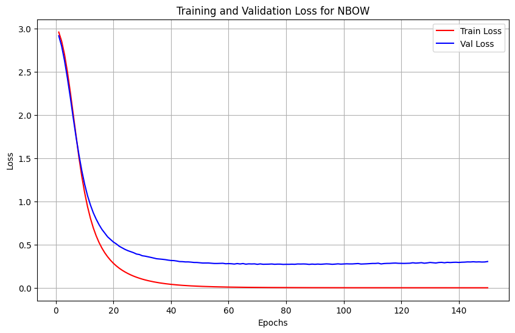

```python
# DO NOT CHANGE THIS CELL - retain the outputs in submission PDF for credits
plot_loss(train_loss_over_time_nbow, val_loss_over_time_nbow, 'NBOW')
```

### 3.6. Model Evaluation [2 points - Programming]

The final points for this will be awarded as per Gradescope's test split, which is different from the local versions. The cell below is just for a sanity check. Your metrics here may not exactly match with the ones on Gradescope, but if your model is fairly generalized, it should not be far off.

- 0 points for accuracy <= 84%
- 1 point for accuracy > 84% but <= 88%
- 2 points for accuracy > 88%

```python
# load best model from checkpoint
# DO NOT CHANGE THIS CELL
learning_rate, epochs, embedding_dim = get_hyperparams_nbow()
nbow_model = get_nbow_model(vocab_size= len(train_vocab.keys()), embedding_dim = embedding_dim).to(device)
load_checkpoint(nbow_model, 'nbow', map_location=device)

# evaluate model
true, pred, val_loss = val_loop(nbow_model, criterion, val_iterator)
accuracy, f1 = get_accuracy_and_f1_score(true, pred)
print(f"Final Validation Accuracy: {accuracy}")
print(f"Final Validation F1-Score: {f1}")
```

```
Final Validation Accuracy: 0.9257294429708223
Final Validation F1-Score: 0.9237574259151046
```

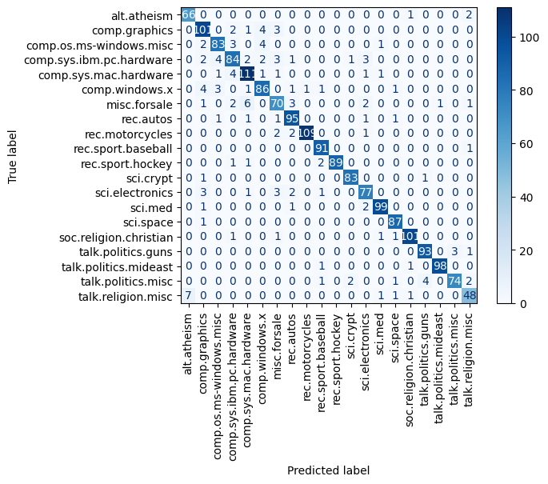

```python
# DO NOT CHANGE THIS CELL
plot_confusion_matrix(true, pred, classes=id2label.values())
```

## 4. Simple Deep Averaging Networks (DAN) [5 points - Programming + 3 points - Non-programming]

Now, let's look at how to improve performance of the NBOW model. One such way without drastically changing the model complexity is DAN.

The core idea of a DAN is to simplify the process of understanding text by averaging the embeddings of words in a sentence or document. This creates a single vector representation that captures the overall meaning of the text.

In implementation, a DAN typically involves the following steps:

1. Convert each token into an embedding.
2. Average these embeddings to create a single vector that represents the entire document.
3. Pass this averaged vector through one hidden fully connected neural network layer.
4. Use ReLU activation
5. Use the output of these layers for tasks like classification.

This approach is simpler and often faster than more complex architectures like LSTMs or Transformers, while still providing robust performance for many tasks. However, it might not capture nuances in language as effectively as these more complex models.

*NOTE*: Use the same approach to handle pad_tokens as you used in NBOW.

### 4.1. Model Definition [3 points - Programming]

Refer to the following equation on how to define DAN -

$$ h_{avg} = \frac{1}{n} \sum_t emb(x_t) $$$$ h_2 = (w_1h_{avg}) $$$$ h'_{2} = max(0, h_2) $$

The probability of a data instance belonging to class $y_i$ is given by:

$$ p(y|x) = softmax(w_2^T h'_{2} + b) $$

where $w \in R^d$ is a parameter vector.

*Hint*: Make sure to handle the case where the input contains pad tokens. We don't want to consider them in our average.

```python
# export
class DAN(nn.Module):
    # Instantiate layers for your model-
    #
    # Your model architecture will be a feed-forward neural network.
    #
    # You'll need 5 nn.Modules:
    # 1. An embeddings layer (see nn.Embedding)
    # 2. A linear layer (see nn.Linear)
    # 3. A ReLU activation (see nn.ReLU)
    # 4. A linear layer (see nn.Linear)
    #
    def __init__(self, vocab_size, embedding_dim, hidden_dim, num_classes=20):
        # voab_size is the size of the vocabulary
        # use bias in your hidden layer
        # embedding_dim is the dimension of the word embeddings
        # hidden_dim is the dimension of the hidden layer outputs, i.e., the 2nd module as per the definition above
        super().__init__()
        ## YOUR CODE STARTS HERE ##

        self.vocab_size = vocab_size
        self.embedding_dim = embedding_dim
        self.hidden_dim = hidden_dim
        self.num_classes = num_classes

        self.embedding = nn.Embedding(vocab_size, embedding_dim) # 2 x 5
        self.hidden = nn.Linear(embedding_dim, hidden_dim, bias=False) # 1 x 3
        self.relu = nn.ReLU()
        self.linear = nn.Linear(hidden_dim, num_classes, bias=True)

        ## YOUR CODE ENDS HERE ##

    # Complete the forward pass of the model.
    #
    # Use the output of the embedding layer to create
    # the average vector, which will be input into the
    # linear layer.
    #
    # args:
    # x - 2D LongTensor of shape (BATCH_SIZE, max len of all tokenized_word_tensor))
    #     This is the same output that comes out of the collate_fn function you completed
    def forward(self, x):
        ## YOUR CODE STARTS HERE ##
        hidden = self.get_hidden(x)
        relu_out = self.relu(hidden)
        lin_out = self.linear(relu_out)
        return lin_out

        ## YOUR CODE ENDS HERE ##

    def get_embeddings(self, x):
        '''
        This function returns the embeddings of the input x
        '''
        ### YOUR CODE STARTS HERE ###

        return self.embedding(x)

        ### YOUR CODE ENDS HERE ###

    def set_embedding_weight(self, weight):
        '''
        This function sets the embedding weights to the input weight ensure you aren't recording gradients for this
        Args:
            weight: torch.tensor of shape (vocab_size, embedding_dim)
        '''
        ### YOUR CODE STARTS HERE ###

        self.embedding.weight = nn.Parameter(weight, requires_grad=False)

        ### YOUR CODE ENDS HERE ###

    def get_hidden(self, x):
        '''
        This function returns the embeddings of the input x
        '''
        ### YOUR CODE STARTS HERE ###

        embeddings = self.get_embeddings(x)

        mask = (x!= PADDING_VALUE)

        # Count the number of non-padding tokens in each sequence for averaging later
        num_non_pads = mask.sum(dim=1).unsqueeze(-1)

        # Apply the mask to the embeddings
        embeddings = embeddings * mask.unsqueeze(-1)

        avg_embeddings = embeddings.sum(dim=1)/num_non_pads # gives batch_size x 1

        return self.hidden(avg_embeddings)

        ### YOUR CODE ENDS HERE ###

    def set_hidden_weight(self, weight, bias):
        '''
        This function sets the embedding weights to the input weight ensure you aren't recording gradients for this
        Args:
            weight: torch.tensor of shape (embedding_dim, hidden_dim)
            bias: torch.tensor of shape (1, hidden_dim)
        '''
        ### YOUR CODE STARTS HERE ###

        self.hidden.weight = nn.Parameter(weight, requires_grad=False)
        self.hidden.bias = nn.Parameter(bias.view(-1), requires_grad=False)

        ### YOUR CODE ENDS HERE ###
```

```python
# local test for sanity:
# DO NOT CHANGE THIS CELL
def dan_test_local_embeddings():
    embedding_dim = 3
    vocab_size = 5
    model = DAN(embedding_dim=embedding_dim, vocab_size=vocab_size, hidden_dim=10)
    model.set_embedding_weight(torch.arange(15).reshape(5,3) / 50)
    embeddings = model.get_embeddings(torch.tensor([[1,2,3,4,1],[1,2,3,0,0]]))
    correct_embeddings = torch.tensor([[[0.0600, 0.0800, 0.1000],
                                        [0.1200, 0.1400, 0.1600],
                                        [0.1800, 0.2000, 0.2200],
                                        [0.2400, 0.2600, 0.2800],
                                        [0.0600, 0.0800, 0.1000]],

                                        [[0.0600, 0.0800, 0.1000],
                                        [0.1200, 0.1400, 0.1600],
                                        [0.1800, 0.2000, 0.2200],
                                        [0.0000, 0.0200, 0.0400],
                                        [0.0000, 0.0200, 0.0400]]])
    if torch.allclose(embeddings, correct_embeddings, rtol=0.001):
        print("Passed local embedding test")
    else:
        print(f"Embedding Test failed, expected value was\n{correct_embeddings}\nbut you got:\n{embeddings}")

def dan_test_local_hidden_layer():
    vocab_size = 5
    embedding_dim = 3
    hidden_dim = 3

    model = DAN(vocab_size, embedding_dim, hidden_dim)
    model.set_embedding_weight(torch.arange(15).reshape(5,3) / 50)
    model.set_hidden_weight(torch.arange(9).reshape(embedding_dim, hidden_dim) / 50, torch.arange(3).reshape(1, hidden_dim) / 50)

    output = model.get_hidden(torch.tensor([[1,2,3,4,1],[1,2,3,0,0]]))
    correct_output = torch.tensor([[0.0099, 0.0573, 0.1046],
                                    [0.0092, 0.0544, 0.0996]])

    if torch.allclose(output, correct_output, atol=0.001):
        print("Passed local hidden layer test")
    else:
        print(f"Embedding Test failed, expected value was\n{correct_output}\nbut you got:\n{output}")

dan_test_local_embeddings()
dan_test_local_hidden_layer()
```

```
Passed local embedding test
Passed local hidden layer test
```

### 4.2. DAN Training [3 points - Non-programming]

In this section (and all later sections), you will leverage the same functions defined in Section 3 to train your DAN. To do this, simply initialize your DAN Model and pass that object to the training and evaluation loop to train your model.

Assign and tune the below hyperparameters to optimize your model

```python
# export
def get_dan_model(vocab_size, embedding_dim, hidden_dim):
    """
    This function returns an instance of the DAN model. Initialize the DAN model here and return it. Note that the hidden_dim will be the dimension of the hidden layer in DAN.
    """
    ## YOUR CODE STARTS HERE ##

    model = DAN(vocab_size=vocab_size, embedding_dim=embedding_dim, hidden_dim=hidden_dim)

    ## YOUR CODE ENDS HERE ##
    return model
```

```python
#export
# Assign hyperparameters and training parameters
# Experiment with different values for these hyperparaters to optimize your model's performance
def get_hyperparams_dan():
  ### your hyper parameters
    learning_rate = 0.001
    epochs = 150
    hidden_layer_dimensions = 100
    embedding_dim = 100
    ###
    return learning_rate, epochs, hidden_layer_dimensions, embedding_dim
```

```python
# This is the main training loop. You'll need to complete the train_loop and val_loop functions.
# You'll also need to complete the criterion and optimizer functions.
# Feel free to experiment with different optimizers and learning rates.
# Do not change anything else in this cell
learning_rate, epochs, hidden_layer_dimensions, embedding_dim = get_hyperparams_dan()
dan_model = get_dan_model(len(train_vocab.keys()), embedding_dim, hidden_layer_dimensions).to(device)
criterion = get_criterion()
optimizer = get_optimizer(dan_model, learning_rate)
train_loss_over_time_dan = []
val_loss_over_time_dan = []
for epoch in range(epochs):
    train_loss = train_loop(dan_model, criterion, optimizer, train_iterator, epoch, save_every=2)
    true, pred, val_loss = val_loop(dan_model, criterion, val_iterator)
    accuracy, f1 = get_accuracy_and_f1_score(true, pred)
    train_loss_over_time_dan.append(train_loss)
    val_loss_over_time_dan.append(val_loss)
    print(f"Epoch {epoch+1} -- Train_Loss: {train_loss} -- Val_Loss: {val_loss} -- Val_Accuracy: {accuracy} -- Val_F1: {f1}")

save_checkpoint(dan_model, 'dan')
```

```
Epoch 1 -- Train_Loss: 2.909276899644884 -- Val_Loss: 2.7778541405995685 -- Val_Accuracy: 0.14907161803713528 -- Val_F1: 0.0926738458301409
```

```
Epoch 2 -- Train_Loss: 2.5997894133551647 -- Val_Loss: 2.4117671489715575 -- Val_Accuracy: 0.26047745358090185 -- Val_F1: 0.21890730031503763
```

```
Epoch 3 -- Train_Loss: 2.1804013050208657 -- Val_Loss: 2.006922157605489 -- Val_Accuracy: 0.42015915119363395 -- Val_F1: 0.37842651165507546
```

```
Epoch 4 -- Train_Loss: 1.7375524892645366 -- Val_Loss: 1.6373154322306316 -- Val_Accuracy: 0.526790450928382 -- Val_F1: 0.4989584365249419
```

```
Epoch 5 -- Train_Loss: 1.3464010014372356 -- Val_Loss: 1.3323453982671103 -- Val_Accuracy: 0.6143236074270557 -- Val_F1: 0.5981079984151868
```

```
Epoch 6 -- Train_Loss: 1.042219018532058 -- Val_Loss: 1.1112155079841615 -- Val_Accuracy: 0.676923076923077 -- Val_F1: 0.6654792936982666
```

```
Epoch 7 -- Train_Loss: 0.8068768447738582 -- Val_Loss: 0.9403775731722513 -- Val_Accuracy: 0.7283819628647215 -- Val_F1: 0.719097493530401
```

```
Epoch 8 -- Train_Loss: 0.6287095395185179 -- Val_Loss: 0.8256392518679301 -- Val_Accuracy: 0.7623342175066313 -- Val_F1: 0.7545200891055731
```

```
Epoch 9 -- Train_Loss: 0.4930570731728764 -- Val_Loss: 0.735285480817159 -- Val_Accuracy: 0.7909814323607427 -- Val_F1: 0.7855968135557152
```

```
Epoch 10 -- Train_Loss: 0.3867694919897338 -- Val_Loss: 0.6595482468605042 -- Val_Accuracy: 0.8164456233421751 -- Val_F1: 0.8136412901821938
```

```
Epoch 11 -- Train_Loss: 0.30766024516295576 -- Val_Loss: 0.5944335361321768 -- Val_Accuracy: 0.8291777188328913 -- Val_F1: 0.8251816402159158
```

```
Epoch 12 -- Train_Loss: 0.24447935996419293 -- Val_Loss: 0.568142294883728 -- Val_Accuracy: 0.8339522546419098 -- Val_F1: 0.8319922847088057
```

```
Epoch 13 -- Train_Loss: 0.19532024645704335 -- Val_Loss: 0.5338541189829509 -- Val_Accuracy: 0.8381962864721485 -- Val_F1: 0.8356783659787365
```

```
Epoch 14 -- Train_Loss: 0.1578789104597043 -- Val_Loss: 0.5215594192345937 -- Val_Accuracy: 0.8461538461538461 -- Val_F1: 0.8439058186217145
```

```
Epoch 15 -- Train_Loss: 0.12644752942151943 -- Val_Loss: 0.5017413715521495 -- Val_Accuracy: 0.8482758620689655 -- Val_F1: 0.8460823938870267
```

```
Epoch 16 -- Train_Loss: 0.10279100647164603 -- Val_Loss: 0.48209375341733296 -- Val_Accuracy: 0.8530503978779841 -- Val_F1: 0.8501859940585115
```

```
Epoch 17 -- Train_Loss: 0.08348013501677473 -- Val_Loss: 0.47699477275212604 -- Val_Accuracy: 0.8514588859416445 -- Val_F1: 0.850091328010403
```

```
Epoch 18 -- Train_Loss: 0.06837855323644007 -- Val_Loss: 0.469673885901769 -- Val_Accuracy: 0.8578249336870026 -- Val_F1: 0.8549229006877814
```

```
Epoch 19 -- Train_Loss: 0.05607334104508667 -- Val_Loss: 0.4639546205600103 -- Val_Accuracy: 0.8620689655172413 -- Val_F1: 0.859036025775669
```

```
Epoch 20 -- Train_Loss: 0.046293931523874655 -- Val_Loss: 0.46137418150901793 -- Val_Accuracy: 0.8625994694960212 -- Val_F1: 0.8595560290858147
```

```
Epoch 21 -- Train_Loss: 0.03831622416500823 -- Val_Loss: 0.460919717947642 -- Val_Accuracy: 0.8657824933687003 -- Val_F1: 0.8628391607015292
```

```
Epoch 22 -- Train_Loss: 0.03189745419106241 -- Val_Loss: 0.4628366688887278 -- Val_Accuracy: 0.8641909814323607 -- Val_F1: 0.8611379485956011
```

```
Epoch 23 -- Train_Loss: 0.026809776107133445 -- Val_Loss: 0.4598242700099945 -- Val_Accuracy: 0.8684350132625994 -- Val_F1: 0.8670732116113671
```

```
Epoch 24 -- Train_Loss: 0.022729267137346125 -- Val_Loss: 0.45596199333667753 -- Val_Accuracy: 0.8694960212201591 -- Val_F1: 0.8662146119533929
```

```
Epoch 25 -- Train_Loss: 0.01928329271248589 -- Val_Loss: 0.4621310830116272 -- Val_Accuracy: 0.870026525198939 -- Val_F1: 0.8670454795305702
```

```
Epoch 26 -- Train_Loss: 0.016392110041895155 -- Val_Loss: 0.46443338990211486 -- Val_Accuracy: 0.8673740053050398 -- Val_F1: 0.865492595857493
```

```
Epoch 27 -- Train_Loss: 0.014082391055742815 -- Val_Loss: 0.47323262294133506 -- Val_Accuracy: 0.8689655172413793 -- Val_F1: 0.8670475800602222
```

```
Epoch 28 -- Train_Loss: 0.012233127117693678 -- Val_Loss: 0.4637882481018702 -- Val_Accuracy: 0.8721485411140584 -- Val_F1: 0.8692348093506428
```

```
Epoch 29 -- Train_Loss: 0.010551579478117874 -- Val_Loss: 0.4662009418010712 -- Val_Accuracy: 0.8689655172413793 -- Val_F1: 0.8670937202437733
```

```
Epoch 30 -- Train_Loss: 0.009237576414183792 -- Val_Loss: 0.4759365181128184 -- Val_Accuracy: 0.8716180371352785 -- Val_F1: 0.8692494668424174
```

```
Epoch 31 -- Train_Loss: 0.008171620176931432 -- Val_Loss: 0.4809941232204437 -- Val_Accuracy: 0.8721485411140584 -- Val_F1: 0.8695088933272437
```

```
Epoch 32 -- Train_Loss: 0.007261952043952957 -- Val_Loss: 0.48536348740259805 -- Val_Accuracy: 0.8732095490716181 -- Val_F1: 0.871079497408426
```

```
Epoch 33 -- Train_Loss: 0.006497743415204271 -- Val_Loss: 0.4848022003968557 -- Val_Accuracy: 0.8748010610079575 -- Val_F1: 0.8721093290315232
```

```
Epoch 34 -- Train_Loss: 0.005957963517314549 -- Val_Loss: 0.4810366710027059 -- Val_Accuracy: 0.870026525198939 -- Val_F1: 0.8674633420105099
```

```
Epoch 35 -- Train_Loss: 0.0053051064517033305 -- Val_Loss: 0.4801608184973399 -- Val_Accuracy: 0.8748010610079575 -- Val_F1: 0.8720411316659865
```

```
Epoch 36 -- Train_Loss: 0.004891126282450001 -- Val_Loss: 0.4952244957288106 -- Val_Accuracy: 0.8716180371352785 -- Val_F1: 0.8689824619694472
```

```
Epoch 37 -- Train_Loss: 0.004481733460926404 -- Val_Loss: 0.48962252140045165 -- Val_Accuracy: 0.8737400530503979 -- Val_F1: 0.8708513518063203
```

```
Epoch 38 -- Train_Loss: 0.003952622710592981 -- Val_Loss: 0.49468489090601603 -- Val_Accuracy: 0.8737400530503979 -- Val_F1: 0.8713915568119257
```

```
Epoch 39 -- Train_Loss: 0.0036467174837618308 -- Val_Loss: 0.48780266046524046 -- Val_Accuracy: 0.8753315649867374 -- Val_F1: 0.8726135760609175
```

```
Epoch 40 -- Train_Loss: 0.0033732805957512584 -- Val_Loss: 0.4965668678283691 -- Val_Accuracy: 0.8763925729442971 -- Val_F1: 0.8736030117880602
```

```
Epoch 41 -- Train_Loss: 0.0031640951223750363 -- Val_Loss: 0.4885792672634125 -- Val_Accuracy: 0.8785145888594165 -- Val_F1: 0.8753950437838498
```

```
Epoch 42 -- Train_Loss: 0.0030129449787328682 -- Val_Loss: 0.49882778724034627 -- Val_Accuracy: 0.8774535809018568 -- Val_F1: 0.8748361971724462
```

```
Epoch 43 -- Train_Loss: 0.002755116887382721 -- Val_Loss: 0.5109207967917124 -- Val_Accuracy: 0.8779840848806366 -- Val_F1: 0.8750562939890209
```

```
Epoch 44 -- Train_Loss: 0.002654815922388649 -- Val_Loss: 0.508293894926707 -- Val_Accuracy: 0.8758620689655172 -- Val_F1: 0.8728043204253778
```

```
Epoch 45 -- Train_Loss: 0.002510227962945572 -- Val_Loss: 0.49736724694569906 -- Val_Accuracy: 0.8779840848806366 -- Val_F1: 0.8754402701647124
```

```
Epoch 46 -- Train_Loss: 0.0022631637545862883 -- Val_Loss: 0.5010319113731384 -- Val_Accuracy: 0.8790450928381963 -- Val_F1: 0.8765263470094066
```

```
Epoch 47 -- Train_Loss: 0.0023584889841928953 -- Val_Loss: 0.5270486891269683 -- Val_Accuracy: 0.8763925729442971 -- Val_F1: 0.874390917724245
```

```
Epoch 48 -- Train_Loss: 0.0020180739165417912 -- Val_Loss: 0.50767942070961 -- Val_Accuracy: 0.8816976127320955 -- Val_F1: 0.8786577322213512
```

```
Epoch 49 -- Train_Loss: 0.0020977608530024475 -- Val_Loss: 0.511074823141098 -- Val_Accuracy: 0.880106100795756 -- Val_F1: 0.8768402748820552
```

```
Epoch 50 -- Train_Loss: 0.0019244902226600354 -- Val_Loss: 0.5206416169802348 -- Val_Accuracy: 0.880106100795756 -- Val_F1: 0.8780260838955856
```

```
Epoch 51 -- Train_Loss: 0.0016781346215392953 -- Val_Loss: 0.5284583946069081 -- Val_Accuracy: 0.8795755968169762 -- Val_F1: 0.8766537619513768
```

```
Epoch 52 -- Train_Loss: 0.0015782404871523318 -- Val_Loss: 0.5144819815953573 -- Val_Accuracy: 0.8795755968169762 -- Val_F1: 0.8779112310237334
```

```
Epoch 53 -- Train_Loss: 0.0016404203256647403 -- Val_Loss: 0.5223121523857117 -- Val_Accuracy: 0.8827586206896552 -- Val_F1: 0.8799598211165645
```

```
Epoch 54 -- Train_Loss: 0.0014395620003026927 -- Val_Loss: 0.5270570009946823 -- Val_Accuracy: 0.8827586206896552 -- Val_F1: 0.8801294296584036
```

```
Epoch 55 -- Train_Loss: 0.0013701192478716405 -- Val_Loss: 0.5156065384546916 -- Val_Accuracy: 0.8843501326259947 -- Val_F1: 0.88183850359381
```

```
Epoch 56 -- Train_Loss: 0.0012987379531743067 -- Val_Loss: 0.5402372340361278 -- Val_Accuracy: 0.8790450928381963 -- Val_F1: 0.8763448990760173
```

```
Epoch 57 -- Train_Loss: 0.0012198448473670503 -- Val_Loss: 0.5546325743198395 -- Val_Accuracy: 0.8721485411140584 -- Val_F1: 0.871441627777576
```

```
Epoch 58 -- Train_Loss: 0.0017896351272287637 -- Val_Loss: 0.5317580362161001 -- Val_Accuracy: 0.880106100795756 -- Val_F1: 0.8783266408886161
```

```
Epoch 59 -- Train_Loss: 0.001094373008404006 -- Val_Loss: 0.5213485221068065 -- Val_Accuracy: 0.8854111405835544 -- Val_F1: 0.8827826835608986
```

```
Epoch 60 -- Train_Loss: 0.0010095482829749047 -- Val_Loss: 0.5624191641807557 -- Val_Accuracy: 0.8758620689655172 -- Val_F1: 0.8727122405651049
```

```
Epoch 61 -- Train_Loss: 0.0008996998897647106 -- Val_Loss: 0.541430018345515 -- Val_Accuracy: 0.8838196286472149 -- Val_F1: 0.8815027764674577
```

```
Epoch 62 -- Train_Loss: 0.0009731533073906992 -- Val_Loss: 0.5508968154589335 -- Val_Accuracy: 0.8859416445623343 -- Val_F1: 0.8835661049927757
```

```
Epoch 63 -- Train_Loss: 0.0010446196725844578 -- Val_Loss: 0.5491502324740092 -- Val_Accuracy: 0.8816976127320955 -- Val_F1: 0.8791335912807581
```

```
Epoch 64 -- Train_Loss: 0.001173992001972461 -- Val_Loss: 0.5484948952992758 -- Val_Accuracy: 0.8816976127320955 -- Val_F1: 0.8792808407414991
```

```
Epoch 65 -- Train_Loss: 0.0010155506933480895 -- Val_Loss: 0.5483793358008067 -- Val_Accuracy: 0.8827586206896552 -- Val_F1: 0.880915990128897
```

```
Epoch 66 -- Train_Loss: 0.001163525640411042 -- Val_Loss: 0.5500157058238984 -- Val_Accuracy: 0.8870026525198939 -- Val_F1: 0.8843686474232053
```

```
Epoch 67 -- Train_Loss: 0.0007079743502229468 -- Val_Loss: 0.5444498836994172 -- Val_Accuracy: 0.8822281167108753 -- Val_F1: 0.8793970579282686
```

```
Epoch 68 -- Train_Loss: 0.001008173458843484 -- Val_Loss: 0.6025711556275686 -- Val_Accuracy: 0.8795755968169762 -- Val_F1: 0.8766327808570453
```

```
Epoch 69 -- Train_Loss: 0.0013062721931018425 -- Val_Loss: 0.5747658828894298 -- Val_Accuracy: 0.8790450928381963 -- Val_F1: 0.8768859549800372
```

```
Epoch 70 -- Train_Loss: 0.0006215729987716413 -- Val_Loss: 0.559854284922282 -- Val_Accuracy: 0.8843501326259947 -- Val_F1: 0.8817478410304911
```

```
Epoch 71 -- Train_Loss: 0.000850892845754338 -- Val_Loss: 0.5507280617952347 -- Val_Accuracy: 0.8864721485411141 -- Val_F1: 0.8843765348880362
```

```
Epoch 72 -- Train_Loss: 0.0012017005667414999 -- Val_Loss: 0.5701743086179097 -- Val_Accuracy: 0.8859416445623343 -- Val_F1: 0.8829420335270696
```

```
Epoch 73 -- Train_Loss: 0.0008608083430849316 -- Val_Loss: 0.5780167440573375 -- Val_Accuracy: 0.8870026525198939 -- Val_F1: 0.8841990630747801
```

```
Epoch 74 -- Train_Loss: 0.001105949528980507 -- Val_Loss: 0.5705101311206817 -- Val_Accuracy: 0.8859416445623343 -- Val_F1: 0.8831878762506793
```

```
Epoch 75 -- Train_Loss: 0.0007935015603572415 -- Val_Loss: 0.5670121173063914 -- Val_Accuracy: 0.8891246684350133 -- Val_F1: 0.8863609824495073
```

```
Epoch 76 -- Train_Loss: 0.0008388623049910875 -- Val_Loss: 0.6505114277203877 -- Val_Accuracy: 0.8779840848806366 -- Val_F1: 0.8771892141722587
```

```
Epoch 77 -- Train_Loss: 0.0009171648774299991 -- Val_Loss: 0.5886797825495402 -- Val_Accuracy: 0.8806366047745358 -- Val_F1: 0.8787848141196444
```

```
Epoch 78 -- Train_Loss: 0.0011597815378158653 -- Val_Loss: 0.5729331076145172 -- Val_Accuracy: 0.8827586206896552 -- Val_F1: 0.8804000997514878
```

```
Epoch 79 -- Train_Loss: 0.0012288175119280467 -- Val_Loss: 0.577756808201472 -- Val_Accuracy: 0.8870026525198939 -- Val_F1: 0.8842522929447743
```

```
Epoch 80 -- Train_Loss: 0.0008775094128534458 -- Val_Loss: 0.5800744295120239 -- Val_Accuracy: 0.8854111405835544 -- Val_F1: 0.8830681819138789
```

```
Epoch 81 -- Train_Loss: 0.0003315624011427922 -- Val_Loss: 0.5673224886258443 -- Val_Accuracy: 0.8912466843501327 -- Val_F1: 0.8882222475785315
```

```
Epoch 82 -- Train_Loss: 0.0003278805563888331 -- Val_Loss: 0.5735061407089234 -- Val_Accuracy: 0.890185676392573 -- Val_F1: 0.8870970583936574
```

```
Epoch 83 -- Train_Loss: 0.00044319923598762264 -- Val_Loss: 0.6023636480172475 -- Val_Accuracy: 0.8816976127320955 -- Val_F1: 0.8795438574733774
```

```
Epoch 84 -- Train_Loss: 0.000706294922688897 -- Val_Loss: 0.5752458800872167 -- Val_Accuracy: 0.8859416445623343 -- Val_F1: 0.8844882707445196
```

```
Epoch 85 -- Train_Loss: 0.0007965811333726101 -- Val_Loss: 0.5827752391497294 -- Val_Accuracy: 0.8875331564986737 -- Val_F1: 0.8854040245464784
```

```
Epoch 86 -- Train_Loss: 0.000493464079520012 -- Val_Loss: 0.6410974343617757 -- Val_Accuracy: 0.8785145888594165 -- Val_F1: 0.8788663796487614
```

```
Epoch 87 -- Train_Loss: 0.0008221743867009428 -- Val_Loss: 0.5779946108659109 -- Val_Accuracy: 0.8896551724137931 -- Val_F1: 0.8869821381071468
```

```
Epoch 88 -- Train_Loss: 0.0005209938893331436 -- Val_Loss: 0.5974848330020904 -- Val_Accuracy: 0.8864721485411141 -- Val_F1: 0.8841663248936331
```

```
Epoch 89 -- Train_Loss: 0.0007649786595905779 -- Val_Loss: 0.6269358853499095 -- Val_Accuracy: 0.8822281167108753 -- Val_F1: 0.8805094566931937
```

```
Epoch 90 -- Train_Loss: 0.0004920299072521521 -- Val_Loss: 0.5796161075433095 -- Val_Accuracy: 0.8912466843501327 -- Val_F1: 0.888267520550207
```

```
Epoch 91 -- Train_Loss: 0.0004206954259736171 -- Val_Loss: 0.6197695275147755 -- Val_Accuracy: 0.8864721485411141 -- Val_F1: 0.8845601150866882
```

```
Epoch 92 -- Train_Loss: 0.0005767352487687199 -- Val_Loss: 0.615677539507548 -- Val_Accuracy: 0.8875331564986737 -- Val_F1: 0.885707978807209
```

```
Epoch 93 -- Train_Loss: 0.00032273885209194256 -- Val_Loss: 0.6051601906617482 -- Val_Accuracy: 0.8891246684350133 -- Val_F1: 0.8870744486757216
```

```
Epoch 94 -- Train_Loss: 0.0003945573648629992 -- Val_Loss: 0.5883112370967865 -- Val_Accuracy: 0.893368700265252 -- Val_F1: 0.8913725627987736
```

```
Epoch 95 -- Train_Loss: 0.00032840984970219217 -- Val_Loss: 0.6187720467646917 -- Val_Accuracy: 0.8843501326259947 -- Val_F1: 0.8820176787857893
```

```
Epoch 96 -- Train_Loss: 0.00030417510150350683 -- Val_Loss: 0.5976001222928365 -- Val_Accuracy: 0.8891246684350133 -- Val_F1: 0.8859509932348594
```

```
Epoch 97 -- Train_Loss: 0.00033858849412539156 -- Val_Loss: 0.6338070730368296 -- Val_Accuracy: 0.8859416445623343 -- Val_F1: 0.884096409481882
```

```
Epoch 98 -- Train_Loss: 0.0005476889834842611 -- Val_Loss: 0.6115030745665232 -- Val_Accuracy: 0.8891246684350133 -- Val_F1: 0.8859505616703922
```

```
Epoch 99 -- Train_Loss: 0.0008484579777698747 -- Val_Loss: 0.6105726599693299 -- Val_Accuracy: 0.8827586206896552 -- Val_F1: 0.8808212873224068
```

```
Epoch 100 -- Train_Loss: 0.0005737353288060473 -- Val_Loss: 0.6169169962406158 -- Val_Accuracy: 0.8885941644562334 -- Val_F1: 0.8858891951106687
```

```
Epoch 101 -- Train_Loss: 0.0007185303283669351 -- Val_Loss: 0.6010221560796102 -- Val_Accuracy: 0.8923076923076924 -- Val_F1: 0.8896597371360011
```

```
Epoch 102 -- Train_Loss: 0.0005076977059939901 -- Val_Loss: 0.6681755979855856 -- Val_Accuracy: 0.8811671087533156 -- Val_F1: 0.878205175769345
```

```
Epoch 103 -- Train_Loss: 0.0008371283645181516 -- Val_Loss: 0.6133175671100617 -- Val_Accuracy: 0.8907161803713528 -- Val_F1: 0.8880633436038694
```

```
Epoch 104 -- Train_Loss: 0.0004797661897748061 -- Val_Loss: 0.6630081335703532 -- Val_Accuracy: 0.8827586206896552 -- Val_F1: 0.8813676893737579
```

```
Epoch 105 -- Train_Loss: 0.0009740500638946611 -- Val_Loss: 0.6069258073965709 -- Val_Accuracy: 0.8891246684350133 -- Val_F1: 0.8865248039237084
```

```
Epoch 106 -- Train_Loss: 0.0005009213117912206 -- Val_Loss: 0.6026277641455332 -- Val_Accuracy: 0.8938992042440318 -- Val_F1: 0.8911511475437297
```

```
Epoch 107 -- Train_Loss: 0.0005105639516163353 -- Val_Loss: 0.6006049950917561 -- Val_Accuracy: 0.8944297082228116 -- Val_F1: 0.8912171581215278
```

```
Epoch 108 -- Train_Loss: 0.00016568157799788346 -- Val_Loss: 0.6174563030401866 -- Val_Accuracy: 0.8880636604774536 -- Val_F1: 0.8853482488604716
```

```
Epoch 109 -- Train_Loss: 0.00024402205419885262 -- Val_Loss: 0.6126749237378438 -- Val_Accuracy: 0.8928381962864721 -- Val_F1: 0.8908665693138461
```

```
Epoch 110 -- Train_Loss: 0.0005154437174157573 -- Val_Loss: 0.6213581283887227 -- Val_Accuracy: 0.8907161803713528 -- Val_F1: 0.8876635822659107
```

```
Epoch 111 -- Train_Loss: 0.00042697297269916234 -- Val_Loss: 0.6033592949310939 -- Val_Accuracy: 0.8949602122015915 -- Val_F1: 0.8926014732278833
```

```
Epoch 112 -- Train_Loss: 0.0003510358946479786 -- Val_Loss: 0.6113934099674225 -- Val_Accuracy: 0.8954907161803713 -- Val_F1: 0.8928625822433478
```

```
Epoch 113 -- Train_Loss: 0.00023103228801057597 -- Val_Loss: 0.6346349994341532 -- Val_Accuracy: 0.8875331564986737 -- Val_F1: 0.8848835858728993
```

```
Epoch 114 -- Train_Loss: 0.00020428433726457594 -- Val_Loss: 0.6029959738254547 -- Val_Accuracy: 0.8970822281167109 -- Val_F1: 0.8944092997691099
```

```
Epoch 115 -- Train_Loss: 0.00023838423365274232 -- Val_Loss: 0.6442223290602366 -- Val_Accuracy: 0.8880636604774536 -- Val_F1: 0.8858090102752149
```

```
Epoch 116 -- Train_Loss: 0.0010269904625555821 -- Val_Loss: 0.6439615388711294 -- Val_Accuracy: 0.8896551724137931 -- Val_F1: 0.8868582355992721
```

```
Epoch 117 -- Train_Loss: 0.0003325511068905436 -- Val_Loss: 0.6204693237940471 -- Val_Accuracy: 0.8960212201591512 -- Val_F1: 0.8929136914159322
```

```
Epoch 118 -- Train_Loss: 0.00033305697464946485 -- Val_Loss: 0.6404988845189412 -- Val_Accuracy: 0.890185676392573 -- Val_F1: 0.8870425066373959
```

```
Epoch 119 -- Train_Loss: 0.00017023009872823653 -- Val_Loss: 0.621049694220225 -- Val_Accuracy: 0.8960212201591512 -- Val_F1: 0.8929175224975772
```

```
Epoch 120 -- Train_Loss: 9.707215216452422e-05 -- Val_Loss: 0.6415604035059611 -- Val_Accuracy: 0.890185676392573 -- Val_F1: 0.88708616812555
```

```
Epoch 121 -- Train_Loss: 0.00033882835113202466 -- Val_Loss: 0.6412715097268422 -- Val_Accuracy: 0.8912466843501327 -- Val_F1: 0.8882229262284452
```

```
Epoch 122 -- Train_Loss: 0.00022465115724163158 -- Val_Loss: 0.653710949420929 -- Val_Accuracy: 0.8896551724137931 -- Val_F1: 0.8869023222799359
```

```
Epoch 123 -- Train_Loss: 0.0003270629885403234 -- Val_Loss: 0.6195172290007274 -- Val_Accuracy: 0.896551724137931 -- Val_F1: 0.8933738368244505
```

```
Epoch 124 -- Train_Loss: 0.0003792334561571267 -- Val_Loss: 0.6450246651967366 -- Val_Accuracy: 0.8907161803713528 -- Val_F1: 0.8877861837282592
```

```
Epoch 125 -- Train_Loss: 0.00022911388125945544 -- Val_Loss: 0.6485361317793529 -- Val_Accuracy: 0.8907161803713528 -- Val_F1: 0.8878685057353627
```

```
Epoch 126 -- Train_Loss: 0.0001205941663772399 -- Val_Loss: 0.625773549079895 -- Val_Accuracy: 0.8944297082228116 -- Val_F1: 0.8915564854807675
```

```
Epoch 127 -- Train_Loss: 0.00017647520400899694 -- Val_Loss: 0.6554076294104259 -- Val_Accuracy: 0.8907161803713528 -- Val_F1: 0.887631620636885
```

```
Epoch 128 -- Train_Loss: 0.0001660032785135411 -- Val_Loss: 0.638267974058787 -- Val_Accuracy: 0.8944297082228116 -- Val_F1: 0.8926884099541518
```

```
Epoch 129 -- Train_Loss: 0.00022128934497848572 -- Val_Loss: 0.6672724425792694 -- Val_Accuracy: 0.8928381962864721 -- Val_F1: 0.890123147991139
```

```
Epoch 130 -- Train_Loss: 0.0003850479512324054 -- Val_Loss: 0.6444476147492727 -- Val_Accuracy: 0.8907161803713528 -- Val_F1: 0.8878576221201928
```

```
Epoch 131 -- Train_Loss: 0.00020224713675507717 -- Val_Loss: 0.6317411561806997 -- Val_Accuracy: 0.8960212201591512 -- Val_F1: 0.8942350456650237
```

```
Epoch 132 -- Train_Loss: 0.0002655179620379093 -- Val_Loss: 0.6293583432833354 -- Val_Accuracy: 0.8960212201591512 -- Val_F1: 0.8933663955636746
```

```
Epoch 133 -- Train_Loss: 3.326507043065079e-05 -- Val_Loss: 0.6268526623646419 -- Val_Accuracy: 0.8944297082228116 -- Val_F1: 0.8914355904148493
```

```
Epoch 134 -- Train_Loss: 3.6863621867808634e-05 -- Val_Loss: 0.6360319544871648 -- Val_Accuracy: 0.8976127320954908 -- Val_F1: 0.8947884194607637
```

```
Epoch 135 -- Train_Loss: 5.1211472282375325e-05 -- Val_Loss: 0.6313304245471955 -- Val_Accuracy: 0.8970822281167109 -- Val_F1: 0.8942590749106939
```

```
Epoch 136 -- Train_Loss: 0.00010032919435500736 -- Val_Loss: 0.6417965412139892 -- Val_Accuracy: 0.8986737400530505 -- Val_F1: 0.8956844530851624
```

```
Epoch 137 -- Train_Loss: 0.00016870686856961228 -- Val_Loss: 0.6435319860776265 -- Val_Accuracy: 0.8960212201591512 -- Val_F1: 0.8931147377531488
```

```
Epoch 138 -- Train_Loss: 0.00030786118995203683 -- Val_Loss: 0.6564194083213806 -- Val_Accuracy: 0.893368700265252 -- Val_F1: 0.8918430630021786
```

```
Epoch 139 -- Train_Loss: 0.00045371079980183003 -- Val_Loss: 0.7221480925877889 -- Val_Accuracy: 0.8870026525198939 -- Val_F1: 0.8838160761706476
```

```
Epoch 140 -- Train_Loss: 0.000971699496330522 -- Val_Loss: 0.7262048741181691 -- Val_Accuracy: 0.8843501326259947 -- Val_F1: 0.8840226042995581
```

```
Epoch 141 -- Train_Loss: 0.0008674062036280409 -- Val_Loss: 0.6585919936498006 -- Val_Accuracy: 0.8923076923076924 -- Val_F1: 0.8901622737909719
```

```
Epoch 142 -- Train_Loss: 0.00016735818297871385 -- Val_Loss: 0.6485374569892883 -- Val_Accuracy: 0.8970822281167109 -- Val_F1: 0.8950581505865929
```

```
Epoch 143 -- Train_Loss: 0.00017503318247621546 -- Val_Loss: 0.6368370026350021 -- Val_Accuracy: 0.8944297082228116 -- Val_F1: 0.8917694416147508
```

```
Epoch 144 -- Train_Loss: 5.7578268713429786e-05 -- Val_Loss: 0.6891225397586822 -- Val_Accuracy: 0.8885941644562334 -- Val_F1: 0.8872905828111948
```

```
Epoch 145 -- Train_Loss: 0.001161336136238649 -- Val_Loss: 0.6639135857423146 -- Val_Accuracy: 0.8960212201591512 -- Val_F1: 0.8932081976043955
```

```
Epoch 146 -- Train_Loss: 0.0005588288025106614 -- Val_Loss: 0.656792817513148 -- Val_Accuracy: 0.896551724137931 -- Val_F1: 0.8939573376193778
```

```
Epoch 147 -- Train_Loss: 0.00039352203201954163 -- Val_Loss: 0.673591156800588 -- Val_Accuracy: 0.8944297082228116 -- Val_F1: 0.8914550797616323
```

```
Epoch 148 -- Train_Loss: 0.00012700503484242197 -- Val_Loss: 0.7006618718306223 -- Val_Accuracy: 0.890185676392573 -- Val_F1: 0.8875303279872699
```

```
Epoch 149 -- Train_Loss: 0.00012959231218192762 -- Val_Loss: 0.6737117528915405 -- Val_Accuracy: 0.8938992042440318 -- Val_F1: 0.8910355174908208
```

```
Epoch 150 -- Train_Loss: 2.34146868028108e-05 -- Val_Loss: 0.6668238202730815 -- Val_Accuracy: 0.8944297082228116 -- Val_F1: 0.8919230926195209
Checkpoint saved to /home/jblevins32/NLP_HW1/model_weights/checkpoint_dan_ce.pt
```

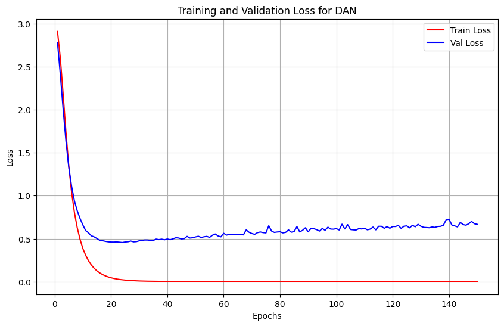

```python
# DO NOT CHANGE THIS CELL - retain the outputs in submission PDF to get credits
plot_loss(train_loss_over_time_dan, val_loss_over_time_dan, 'DAN')
```

### 4.3. Model Evaluation [2 points - Programming]

The final points for this will be awarded as per Gradescope's test split, which is different from the local versions. The cell below is just for a sanity check. Your metrics here may not exactly match with the ones on Gradescope, but if your model is fairly generalized, it should not be far off.

- 0 points for accuracy <= 84%
- 1 point for accuracy > 84% but <= 88%
- 2 points for accuracy > 88%

```python
# DO NOT CHANGE THIS CELL
learning_rate, epochs, hidden_layer_dimensions, embedding_dim = get_hyperparams_dan()
dan_model = get_dan_model(len(train_vocab.keys()), embedding_dim, hidden_layer_dimensions).to(device)
load_checkpoint(dan_model, 'dan', map_location=device)

true, pred, val_loss = val_loop(dan_model, criterion, val_iterator)
accuracy, f1 = get_accuracy_and_f1_score(true, pred)
print(f"Final Validation Accuracy: {accuracy}")
print(f"Final Validation F1-Score: {f1}")
```

```
Final Validation Accuracy: 0.8944297082228116
Final Validation F1-Score: 0.8919230926195209
```

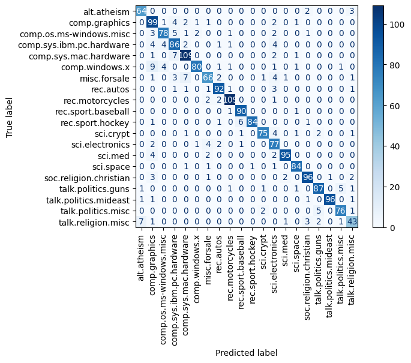

```python
# DO NOT CHANGE THIS CELL
plot_confusion_matrix(true, pred, classes=id2label.values())
```

## 5. Attention-based Models [21 points - Programming + 9 points - Non-programming]

In the simplest terms, attention allows a network to differentially focus on specific input words rather considering their importance equally, as done in the previous sections by averaging. For example, often times the mere presence of word "election" is enough to ascertain the category of the sentence to be politics.

There are various types of attention which we will dsicuss in much more depth throughout course. This section is just to provide a conceptual flavor of attention as a concept. In the below parts, you will work with three different simple types of attention.

### 5.1. Attention-weighted NBOW [7 points - Programming + 3 points - Non-programming]

You will now define an encoder that uses a simple attention function to produce a weight for each word in the sentence followed by a sum of the attention-weighted word embeddings. Simple attention allows the model to learn a weight vector $\alpha_t$ which represents how important will different tokens in a document be.

Consider $u$ to be a single attention head (a learnable PyTorch parameter). With this,

$$ \alpha_t \varpropto \exp\{cos(u,emb(x_t))\} $$

*Note*: This needs to be normalized.

$$ h_{att} = \sum_t \alpha_t emb(x_t) $$

The probability of a data instance belonging to class $y_i$ is given by:

$$ p(y|x) = softmax(w^T h_{att}) $$

where $w \in R^d$ is a parameter vector.

In this model, the unnormalized attention weight for a word $x$ is computed using the cosine similarity between a learnable parameter $u$ and the word embedding for $x$ followed by exponentiation. To get normalized weights $\alpha_t$, normalize across all words in the sentence. Then multiply the attention weights by the word embeddings and sum the attention-weighted embeddings.

*HINT*: See if Softmax function can help with this

*Hint*: Make sure to handle the case where the input contains pad tokens.

#### 5.1.1. Model Definition [5 points - Programming]

Define your simple attention model below.

```python
#export

class SimpleAttentionNBOW(nn.Module):
    """
    This class implements the Attention-weighted Neural Bag of Words model.
    """

    def __init__(self, vocab_size, embedding_dim, num_classes=20):
        super(SimpleAttentionNBOW, self).__init__()
        ## YOUR CODE STARTS HERE ##

        self.vocab_size = vocab_size
        self.embedding_dim = embedding_dim
        self.num_classes = num_classes

        self.embedding = nn.Embedding(vocab_size, embedding_dim)  # Embedding layer
        self.attention = nn.Parameter(torch.randn(embedding_dim), requires_grad=True)  # Attention layer
        self.linear = nn.Linear(embedding_dim, num_classes, bias=False)  # Linear layer for classification

        ## YOUR CODE ENDS HERE ##

    def forward(self, x):
        ## YOUR CODE STARTS HERE ##

        attn = self.get_attention_matrix(x)  # Get attention weights
        embeddings = self.get_embeddings(x)  # Get embeddings
        hidden = (embeddings * attn.unsqueeze(-1)).sum(dim=1)  # Apply attention weights
        predictions = self.linear(hidden)  # Pass through linear layer

        ## YOUR CODE ENDS HERE ##

        return predictions

    def get_embeddings(self, x):
        '''
        This function returns the embeddings of the input x
        '''
        ### YOUR CODE STARTS HERE ###

        return self.embedding(x)

        ### YOUR CODE ENDS HERE ###

    def set_embedding_weight(self, weight):
        '''
        This function sets the embedding weights to the input weight ensure you aren't recording gradients for this
        Args:
            weight: torch.tensor of shape (vocab_size, embedding_dim)
        '''
        ### YOUR CODE STARTS HERE ###

        self.embedding.weight = nn.Parameter(weight, requires_grad=False)

        ### YOUR CODE ENDS HERE ###

    def set_attention_weights(self, weight):
        '''
        This function sets the attention weights to the input weight ensure you aren't recording gradients for this
        Args:
            weight: torch.tensor of shape (embedding_dim)
        '''
        ### YOUR CODE STARTS HERE ###

        self.attention = nn.Parameter(weight, requires_grad=False)

        ### YOUR CODE ENDS HERE ###

    def get_attention_matrix(self, x):
        '''
        This function returns the normalized attention matrix for the input x
        Args:
            x: torch.tensor of shape (BATCH_SIZE, max seq length in batch))
        Returns:
            attention_weights: torch.tensor of shape (BATCH_SIZE, max seq length in batch))
        '''
        ### YOUR CODE STARTS HERE ###
        embeddings = self.get_embeddings(x)
        attn = self.attention.expand(embeddings.size(0), embeddings.size(1), -1)
        cos_sim = torch.cosine_similarity(embeddings, attn, dim=-1)

        # Mask to ignore padding tokens
        mask = (x != 0)
        cos_sim = cos_sim.masked_fill(~mask, float('-inf'))

        return torch.softmax(cos_sim, dim=-1) * mask.float()

        ### YOUR CODE ENDS HERE ###
```

```python
# local test for sanity:
# DO NOT CHANGE THIS CELL
def simple_attention_nbow_test_local_embeddings():
    model = SimpleAttentionNBOW(embedding_dim=3, vocab_size=5)
    model.set_embedding_weight(torch.arange(15).reshape(5,3) / 50)
    embeddings = model.get_embeddings(torch.tensor([[1,2,3,4,1],[1,2,3,0,0]]))
    correct_embeddings = torch.tensor([[[0.0600, 0.0800, 0.1000],
                                        [0.1200, 0.1400, 0.1600],
                                        [0.1800, 0.2000, 0.2200],
                                        [0.2400, 0.2600, 0.2800],
                                        [0.0600, 0.0800, 0.1000]],

                                        [[0.0600, 0.0800, 0.1000],
                                        [0.1200, 0.1400, 0.1600],
                                        [0.1800, 0.2000, 0.2200],
                                        [0.0000, 0.0200, 0.0400],
                                        [0.0000, 0.0200, 0.0400]]])
    if torch.allclose(embeddings, correct_embeddings, rtol=0.001):
        print("Passed local embedding test")
    else:
        print(f"Embedding Test failed, expected value was\n{correct_embeddings}\nbut you got:\n{embeddings}")
def simple_attention_nbow_test_local_attn():
    model = SimpleAttentionNBOW(embedding_dim=3, vocab_size=5)
    model.set_embedding_weight(torch.arange(15).reshape(5,3) / 50)
    model.set_attention_weights(torch.tensor([0.1, 0.2, 0.3]))
    attention_weights = model.get_attention_matrix(torch.tensor([[1,2,3,4,1],[1,2,3,0,0]]))
    correct_attention_weights = torch.tensor([[0.2033, 0.1995, 0.1975, 0.1964, 0.2033],
                                              [0.3387, 0.3323, 0.3290, 0.0000, 0.0000]])
    if torch.allclose(attention_weights, correct_attention_weights, rtol=0.001):
        print("Passed local Attn test")
    else:
        print(f"Attn Test failed, expected value was\n{correct_attention_weights}\nbut you got:\n{attention_weights}")

simple_attention_nbow_test_local_embeddings()
simple_attention_nbow_test_local_attn()
```

```
Passed local embedding test
Passed local Attn test
```

#### 5.1.2. Model Training [3 points - Non-Programming]

Assign and tune the below hyperparameters to optimize your model

```python
#export
# Assign hyperparameters and training parameters
# Experiment with different values for these hyperparaters to optimize your model's performance
def get_hyperparams_simple_attention():
  ### your hyper parameters
    learning_rate = 0.001
    epochs = 100
    embedding_dim = 64
    return learning_rate, epochs, embedding_dim
```

```python
# export
def get_simple_attention_model(vocab_size, embedding_dim):
    """
    This function returns an instance of the SimpleAttentionNBOW model. Initialize the SimpleAttentionNBOW model here and return it.
    """
    ## YOUR CODE STARTS HERE ##

    model = SimpleAttentionNBOW(vocab_size=vocab_size, embedding_dim=embedding_dim)

    ## YOUR CODE ENDS HERE ##
    return model
```

```python
# This is the main training loop. You'll need to complete the train_loop and val_loop functions.
# You'll also need to complete the criterion and optimizer functions.
# Feel free to experiment with different optimizers and learning rates.
# Do not change anything else in this cell
learning_rate, epochs, embedding_dim = get_hyperparams_simple_attention()
simple_attention_model = get_simple_attention_model(vocab_size=len(train_vocab.keys()),embedding_dim=embedding_dim).to(device)
criterion = get_criterion()
train_loss_over_time_sa = []
val_loss_over_time_sa = []
optimizer = get_optimizer(simple_attention_model, learning_rate)
for epoch in range(epochs):
    train_loss = train_loop(simple_attention_model, criterion, optimizer, train_iterator, epoch, save_every=2)
    true, pred, val_loss = val_loop(simple_attention_model, criterion, val_iterator)
    accuracy, f1 = get_accuracy_and_f1_score(true, pred)
    train_loss_over_time_sa.append(train_loss)
    val_loss_over_time_sa.append(val_loss)
    print(f"Epoch {epoch+1} -- Train_Loss: {train_loss} -- Val_Loss: {val_loss} -- Val_Accuracy: {accuracy} -- Val_F1: {f1}")
save_checkpoint(simple_attention_model, 'simple_attention')
```

```
Epoch 1 -- Train_Loss: 2.9657716912738348 -- Val_Loss: 2.932321612040202 -- Val_Accuracy: 0.15278514588859415 -- Val_F1: 0.11254538842010162
```

```
Epoch 2 -- Train_Loss: 2.8859146712190014 -- Val_Loss: 2.839094813664754 -- Val_Accuracy: 0.2403183023872679 -- Val_F1: 0.21123641706031426
```

```
Epoch 3 -- Train_Loss: 2.762287133831089 -- Val_Loss: 2.695765988032023 -- Val_Accuracy: 0.3140583554376658 -- Val_F1: 0.28264118445752184
```

```
Epoch 4 -- Train_Loss: 2.590745837001477 -- Val_Loss: 2.5163469473520914 -- Val_Accuracy: 0.3941644562334218 -- Val_F1: 0.36524347944470237
```

```
Epoch 5 -- Train_Loss: 2.3809519278801092 -- Val_Loss: 2.3116973559061686 -- Val_Accuracy: 0.4843501326259947 -- Val_F1: 0.4581084056310319
```

```
Epoch 6 -- Train_Loss: 2.1393915950241738 -- Val_Loss: 2.076266900698344 -- Val_Accuracy: 0.5580901856763926 -- Val_F1: 0.5321272021293021
```

```
Epoch 7 -- Train_Loss: 1.8759391651315205 -- Val_Loss: 1.8372441291809083 -- Val_Accuracy: 0.6408488063660478 -- Val_F1: 0.6186095936913707
```

```
Epoch 8 -- Train_Loss: 1.6096841268620248 -- Val_Loss: 1.6009438514709473 -- Val_Accuracy: 0.6976127320954907 -- Val_F1: 0.6787511924562728
```

```
Epoch 9 -- Train_Loss: 1.360779512736757 -- Val_Loss: 1.3870463530222574 -- Val_Accuracy: 0.7421750663129973 -- Val_F1: 0.728430432380667
```

```
Epoch 10 -- Train_Loss: 1.1418218971309015 -- Val_Loss: 1.205099089940389 -- Val_Accuracy: 0.7803713527851459 -- Val_F1: 0.7719867494303329
```

```
Epoch 11 -- Train_Loss: 0.9579388559874842 -- Val_Loss: 1.055695605278015 -- Val_Accuracy: 0.803183023872679 -- Val_F1: 0.7980563166372747
```

```
Epoch 12 -- Train_Loss: 0.8066307518441799 -- Val_Loss: 0.9270911574363708 -- Val_Accuracy: 0.8254641909814323 -- Val_F1: 0.8216854384257589
```

```
Epoch 13 -- Train_Loss: 0.6835159033031787 -- Val_Loss: 0.8284170587857564 -- Val_Accuracy: 0.8450928381962864 -- Val_F1: 0.8428909108993077
```

```
Epoch 14 -- Train_Loss: 0.583546113412259 -- Val_Loss: 0.7477890928586324 -- Val_Accuracy: 0.8503978779840848 -- Val_F1: 0.8486369783530673
```

```
Epoch 15 -- Train_Loss: 0.5019650257239907 -- Val_Loss: 0.6836634159088135 -- Val_Accuracy: 0.8625994694960212 -- Val_F1: 0.8596583681961555
```

```
Epoch 16 -- Train_Loss: 0.43475157401319275 -- Val_Loss: 0.6251341064771017 -- Val_Accuracy: 0.8673740053050398 -- Val_F1: 0.8644635261975134
```

```
Epoch 17 -- Train_Loss: 0.378700796325328 -- Val_Loss: 0.5812376976013184 -- Val_Accuracy: 0.8716180371352785 -- Val_F1: 0.8685732146011841
```

```
Epoch 18 -- Train_Loss: 0.33216367624068666 -- Val_Loss: 0.5405002435048422 -- Val_Accuracy: 0.8795755968169762 -- Val_F1: 0.876773677419566
```

```
Epoch 19 -- Train_Loss: 0.29252876707557907 -- Val_Loss: 0.5057528555393219 -- Val_Accuracy: 0.8854111405835544 -- Val_F1: 0.883424623548877
```

```
Epoch 20 -- Train_Loss: 0.2588810971227743 -- Val_Loss: 0.4785796284675598 -- Val_Accuracy: 0.8907161803713528 -- Val_F1: 0.8887514862519744
```

```
Epoch 21 -- Train_Loss: 0.2297487959770833 -- Val_Loss: 0.4584022025267283 -- Val_Accuracy: 0.8938992042440318 -- Val_F1: 0.8911299606926433
```

```
Epoch 22 -- Train_Loss: 0.20467689267154468 -- Val_Loss: 0.4345740079879761 -- Val_Accuracy: 0.8986737400530505 -- Val_F1: 0.8959747365384534
```

```
Epoch 23 -- Train_Loss: 0.18272204962322267 -- Val_Loss: 0.4159305969874064 -- Val_Accuracy: 0.9050397877984084 -- Val_F1: 0.9022931009610499
```

```
Epoch 24 -- Train_Loss: 0.16363738830816948 -- Val_Loss: 0.4024808625380198 -- Val_Accuracy: 0.906631299734748 -- Val_F1: 0.9036592937706885
```

```
Epoch 25 -- Train_Loss: 0.14656941384329633 -- Val_Loss: 0.3876411199569702 -- Val_Accuracy: 0.9071618037135278 -- Val_F1: 0.9039297273593384
```

```
Epoch 26 -- Train_Loss: 0.13168641520758806 -- Val_Loss: 0.37576450904210407 -- Val_Accuracy: 0.9087533156498674 -- Val_F1: 0.9056537295101466
```

```
Epoch 27 -- Train_Loss: 0.11840437674673937 -- Val_Loss: 0.36423463026682534 -- Val_Accuracy: 0.9135278514588859 -- Val_F1: 0.9104828363219688
```

```
Epoch 28 -- Train_Loss: 0.10657566908936379 -- Val_Loss: 0.3522161185741425 -- Val_Accuracy: 0.9145888594164456 -- Val_F1: 0.9113916158287113
```

```
Epoch 29 -- Train_Loss: 0.09610346351134574 -- Val_Loss: 0.34640951255957286 -- Val_Accuracy: 0.9183023872679045 -- Val_F1: 0.915650450943331
```

```
Epoch 30 -- Train_Loss: 0.0866893754672196 -- Val_Loss: 0.33844460745652516 -- Val_Accuracy: 0.9193633952254642 -- Val_F1: 0.9167571816010216
```

```
Epoch 31 -- Train_Loss: 0.07827352587196787 -- Val_Loss: 0.33300547500451405 -- Val_Accuracy: 0.9214854111405836 -- Val_F1: 0.9194026696208774
```

```
Epoch 32 -- Train_Loss: 0.07073291258539184 -- Val_Loss: 0.324541375041008 -- Val_Accuracy: 0.9220159151193634 -- Val_F1: 0.9196698836415125
```

```
Epoch 33 -- Train_Loss: 0.06398308065609407 -- Val_Loss: 0.3200487385193507 -- Val_Accuracy: 0.9225464190981433 -- Val_F1: 0.9204201603459449
```

```
Epoch 34 -- Train_Loss: 0.05789012686049534 -- Val_Loss: 0.31278216540813447 -- Val_Accuracy: 0.9230769230769231 -- Val_F1: 0.9208875219517282
```

```
Epoch 35 -- Train_Loss: 0.05249914683212163 -- Val_Loss: 0.3078949848810832 -- Val_Accuracy: 0.9246684350132626 -- Val_F1: 0.9226046898657101
```

```
Epoch 36 -- Train_Loss: 0.04753222300718397 -- Val_Loss: 0.3064188301563263 -- Val_Accuracy: 0.9262599469496021 -- Val_F1: 0.9243704274908741
```

```
Epoch 37 -- Train_Loss: 0.043192882311798755 -- Val_Loss: 0.2999684284130732 -- Val_Accuracy: 0.9273209549071618 -- Val_F1: 0.9251632054992125
```

```
Epoch 38 -- Train_Loss: 0.03923370345037872 -- Val_Loss: 0.2989019145568212 -- Val_Accuracy: 0.9257294429708223 -- Val_F1: 0.923466195135372
```

```
Epoch 39 -- Train_Loss: 0.035691061451778576 -- Val_Loss: 0.2959068735440572 -- Val_Accuracy: 0.9273209549071618 -- Val_F1: 0.9255831264063087
```

```
Epoch 40 -- Train_Loss: 0.032473668629713986 -- Val_Loss: 0.29173047343889874 -- Val_Accuracy: 0.9294429708222812 -- Val_F1: 0.9272325678659014
```

```
Epoch 41 -- Train_Loss: 0.029635167349193057 -- Val_Loss: 0.2881899744272232 -- Val_Accuracy: 0.9289124668435014 -- Val_F1: 0.9266304495606397
```

```
Epoch 42 -- Train_Loss: 0.02701897578219236 -- Val_Loss: 0.29008669356505073 -- Val_Accuracy: 0.9310344827586207 -- Val_F1: 0.9287264870411551
```

```
Epoch 43 -- Train_Loss: 0.024689928139165297 -- Val_Loss: 0.28290388683478035 -- Val_Accuracy: 0.929973474801061 -- Val_F1: 0.9277262437812052
```

```
Epoch 44 -- Train_Loss: 0.022567069015891877 -- Val_Loss: 0.28042713304360706 -- Val_Accuracy: 0.9310344827586207 -- Val_F1: 0.929088147023138
```

```
Epoch 45 -- Train_Loss: 0.020678978855327025 -- Val_Loss: 0.27934787968794506 -- Val_Accuracy: 0.9305039787798408 -- Val_F1: 0.9282529674626794
```

```
Epoch 46 -- Train_Loss: 0.0189499618738132 -- Val_Loss: 0.2791593611240387 -- Val_Accuracy: 0.9315649867374005 -- Val_F1: 0.929648245112136
```

```
Epoch 47 -- Train_Loss: 0.01737907097153997 -- Val_Loss: 0.27400726278622944 -- Val_Accuracy: 0.9305039787798408 -- Val_F1: 0.9284090378639712
```

```
Epoch 48 -- Train_Loss: 0.015968678684873602 -- Val_Loss: 0.27242907385031384 -- Val_Accuracy: 0.9305039787798408 -- Val_F1: 0.928772158869419
```

```
Epoch 49 -- Train_Loss: 0.014719081170446539 -- Val_Loss: 0.27433160146077473 -- Val_Accuracy: 0.9305039787798408 -- Val_F1: 0.928509665499368
```

```
Epoch 50 -- Train_Loss: 0.013513966992308023 -- Val_Loss: 0.2737166742483775 -- Val_Accuracy: 0.9326259946949602 -- Val_F1: 0.9310822711564983
```

```
Epoch 51 -- Train_Loss: 0.012471777659256831 -- Val_Loss: 0.27217396994431814 -- Val_Accuracy: 0.9310344827586207 -- Val_F1: 0.9297167426355685
```

```
Epoch 52 -- Train_Loss: 0.011495137441177236 -- Val_Loss: 0.2705077519019445 -- Val_Accuracy: 0.9310344827586207 -- Val_F1: 0.9293893459243545
```

```
Epoch 53 -- Train_Loss: 0.010612510357809773 -- Val_Loss: 0.26828335026899974 -- Val_Accuracy: 0.9310344827586207 -- Val_F1: 0.92904094786893
```

```
Epoch 54 -- Train_Loss: 0.00981164085520905 -- Val_Loss: 0.26796204249064126 -- Val_Accuracy: 0.9320954907161804 -- Val_F1: 0.9299517974671916
```

```
Epoch 55 -- Train_Loss: 0.009048748122117782 -- Val_Loss: 0.2661073962847392 -- Val_Accuracy: 0.9320954907161804 -- Val_F1: 0.9303737005589447
```

```
Epoch 56 -- Train_Loss: 0.008371124395279813 -- Val_Loss: 0.26726113458474476 -- Val_Accuracy: 0.9315649867374005 -- Val_F1: 0.9295450656886283
```

```
Epoch 57 -- Train_Loss: 0.007782495864745924 -- Val_Loss: 0.2655160814523697 -- Val_Accuracy: 0.9331564986737401 -- Val_F1: 0.9309719072742448
```

```
Epoch 58 -- Train_Loss: 0.007226434078509525 -- Val_Loss: 0.26514985760053 -- Val_Accuracy: 0.9347480106100796 -- Val_F1: 0.9333270510058528
```

```
Epoch 59 -- Train_Loss: 0.006719109452313791 -- Val_Loss: 0.2699272314707438 -- Val_Accuracy: 0.9342175066312998 -- Val_F1: 0.9328964827958043
```

```
Epoch 60 -- Train_Loss: 0.006250379613000836 -- Val_Loss: 0.26479812065760294 -- Val_Accuracy: 0.9347480106100796 -- Val_F1: 0.9332210471663999
```

```
Epoch 61 -- Train_Loss: 0.005832485941443908 -- Val_Loss: 0.26188341428836187 -- Val_Accuracy: 0.9342175066312998 -- Val_F1: 0.9320477824716449
```

```
Epoch 62 -- Train_Loss: 0.0054528208082478685 -- Val_Loss: 0.26743391205867134 -- Val_Accuracy: 0.9347480106100796 -- Val_F1: 0.9331834537425273
```

```
Epoch 63 -- Train_Loss: 0.0050909862719413085 -- Val_Loss: 0.2615089058876038 -- Val_Accuracy: 0.9342175066312998 -- Val_F1: 0.9324276120424912
```

```
Epoch 64 -- Train_Loss: 0.004761480846663274 -- Val_Loss: 0.26364836742480596 -- Val_Accuracy: 0.9347480106100796 -- Val_F1: 0.9331711967670924
```

```
Epoch 65 -- Train_Loss: 0.00447008989542186 -- Val_Loss: 0.2630359619855881 -- Val_Accuracy: 0.9326259946949602 -- Val_F1: 0.9299190450136235
```

```
Epoch 66 -- Train_Loss: 0.004173160382641195 -- Val_Loss: 0.2636049896478653 -- Val_Accuracy: 0.9358090185676392 -- Val_F1: 0.9344245795096151
```

```
Epoch 67 -- Train_Loss: 0.003914833439798173 -- Val_Loss: 0.2634228110313416 -- Val_Accuracy: 0.9347480106100796 -- Val_F1: 0.9324771879151239
```

```
Epoch 68 -- Train_Loss: 0.00369358788366761 -- Val_Loss: 0.2667257209618886 -- Val_Accuracy: 0.9336870026525199 -- Val_F1: 0.9317513455780192
```

```
Epoch 69 -- Train_Loss: 0.0034620910952009765 -- Val_Loss: 0.2631253133217494 -- Val_Accuracy: 0.9342175066312998 -- Val_F1: 0.9326208780824112
```

```
Epoch 70 -- Train_Loss: 0.0032825946069906576 -- Val_Loss: 0.2634735157092412 -- Val_Accuracy: 0.9336870026525199 -- Val_F1: 0.9311798829656468
```

```
Epoch 71 -- Train_Loss: 0.0030766316744798828 -- Val_Loss: 0.2609853823979696 -- Val_Accuracy: 0.9326259946949602 -- Val_F1: 0.9304635085293128
```

```
Epoch 72 -- Train_Loss: 0.0029024108938509757 -- Val_Loss: 0.261768185098966 -- Val_Accuracy: 0.9347480106100796 -- Val_F1: 0.9330758447801987
```

```
Epoch 73 -- Train_Loss: 0.0027380299347973727 -- Val_Loss: 0.2614910195271174 -- Val_Accuracy: 0.9342175066312998 -- Val_F1: 0.9326072472853593
```

```
Epoch 74 -- Train_Loss: 0.00258335340728636 -- Val_Loss: 0.2690152108669281 -- Val_Accuracy: 0.9336870026525199 -- Val_F1: 0.9314764727053187
```

```
Epoch 75 -- Train_Loss: 0.0024399307173661004 -- Val_Loss: 0.2651575778921445 -- Val_Accuracy: 0.9336870026525199 -- Val_F1: 0.9320843714524105
```

```
Epoch 76 -- Train_Loss: 0.002306749232279105 -- Val_Loss: 0.26565213650465014 -- Val_Accuracy: 0.9336870026525199 -- Val_F1: 0.9317515997195762
```

```
Epoch 77 -- Train_Loss: 0.0021833981623107534 -- Val_Loss: 0.2643667037288348 -- Val_Accuracy: 0.9336870026525199 -- Val_F1: 0.9314764727053187
```

```
Epoch 78 -- Train_Loss: 0.0020712539879210548 -- Val_Loss: 0.264827894171079 -- Val_Accuracy: 0.9336870026525199 -- Val_F1: 0.931487382884665
```

```
Epoch 79 -- Train_Loss: 0.0019786832474322073 -- Val_Loss: 0.26306481709082924 -- Val_Accuracy: 0.9336870026525199 -- Val_F1: 0.931487382884665
```

```
Epoch 80 -- Train_Loss: 0.0018825261489590788 -- Val_Loss: 0.26192364394664763 -- Val_Accuracy: 0.9342175066312998 -- Val_F1: 0.9325415831818731
```

```
Epoch 81 -- Train_Loss: 0.0017772359256553701 -- Val_Loss: 0.26925062139829 -- Val_Accuracy: 0.9320954907161804 -- Val_F1: 0.9298120173455011
```

```
Epoch 82 -- Train_Loss: 0.0016729092068567682 -- Val_Loss: 0.26569628765185677 -- Val_Accuracy: 0.9315649867374005 -- Val_F1: 0.9293748072378815
```

```
Epoch 83 -- Train_Loss: 0.0015999513236269103 -- Val_Loss: 0.26064418181777 -- Val_Accuracy: 0.9326259946949602 -- Val_F1: 0.9304321760840558
```

```
Epoch 84 -- Train_Loss: 0.0015187997211133903 -- Val_Loss: 0.2627122650543849 -- Val_Accuracy: 0.9326259946949602 -- Val_F1: 0.9303944185616707
```

```
Epoch 85 -- Train_Loss: 0.0014576979624738886 -- Val_Loss: 0.26563744942347206 -- Val_Accuracy: 0.9326259946949602 -- Val_F1: 0.9303296328926649
```

```
Epoch 86 -- Train_Loss: 0.0013916819431361253 -- Val_Loss: 0.26377737522125244 -- Val_Accuracy: 0.9331564986737401 -- Val_F1: 0.9307808174233486
```

```
Epoch 87 -- Train_Loss: 0.0013173601222106145 -- Val_Loss: 0.2629380534092585 -- Val_Accuracy: 0.9326259946949602 -- Val_F1: 0.9303296328926649
```

```
Epoch 88 -- Train_Loss: 0.001265472654051984 -- Val_Loss: 0.26452937225500744 -- Val_Accuracy: 0.9326259946949602 -- Val_F1: 0.9303296328926649
```

```
Epoch 89 -- Train_Loss: 0.0011998437509291916 -- Val_Loss: 0.26910052001476287 -- Val_Accuracy: 0.9331564986737401 -- Val_F1: 0.9309494412806266
```

```
Epoch 90 -- Train_Loss: 0.0011502688146843496 -- Val_Loss: 0.26594488074382144 -- Val_Accuracy: 0.9326259946949602 -- Val_F1: 0.9303296328926649
```

```
Epoch 91 -- Train_Loss: 0.0011007831771305558 -- Val_Loss: 0.2724855735898018 -- Val_Accuracy: 0.9326259946949602 -- Val_F1: 0.9303009593985696
```

```
Epoch 92 -- Train_Loss: 0.001061534085330727 -- Val_Loss: 0.26689559568961463 -- Val_Accuracy: 0.9331564986737401 -- Val_F1: 0.930960913849707
```

```
Epoch 93 -- Train_Loss: 0.0010204561830644292 -- Val_Loss: 0.26910623361666997 -- Val_Accuracy: 0.9326259946949602 -- Val_F1: 0.93036739041505
```

```
Epoch 94 -- Train_Loss: 0.0009677330100064371 -- Val_Loss: 0.2733848085006078 -- Val_Accuracy: 0.9331564986737401 -- Val_F1: 0.9309472889947074
```

```
Epoch 95 -- Train_Loss: 0.0009098892594427186 -- Val_Loss: 0.2670885692040125 -- Val_Accuracy: 0.9342175066312998 -- Val_F1: 0.9318415551194044
```

```
Epoch 96 -- Train_Loss: 0.0008703258995487655 -- Val_Loss: 0.26932158023118974 -- Val_Accuracy: 0.9331564986737401 -- Val_F1: 0.9308706676520668
```

```
Epoch 97 -- Train_Loss: 0.0008472983897525533 -- Val_Loss: 0.2669299155473709 -- Val_Accuracy: 0.9336870026525199 -- Val_F1: 0.9314288119595812
```

```
Epoch 98 -- Train_Loss: 0.0008068660999770608 -- Val_Loss: 0.2694851242005825 -- Val_Accuracy: 0.9326259946949602 -- Val_F1: 0.9304008322733732
```

```
Epoch 99 -- Train_Loss: 0.0007808302606601994 -- Val_Loss: 0.2707227309544881 -- Val_Accuracy: 0.9336870026525199 -- Val_F1: 0.931416843873668
```

```
Epoch 100 -- Train_Loss: 0.000747979035175808 -- Val_Loss: 0.26908798317114513 -- Val_Accuracy: 0.9326259946949602 -- Val_F1: 0.930419219531181
Checkpoint saved to /home/jblevins32/NLP_HW1/model_weights/checkpoint_simple_attention_ce.pt
```

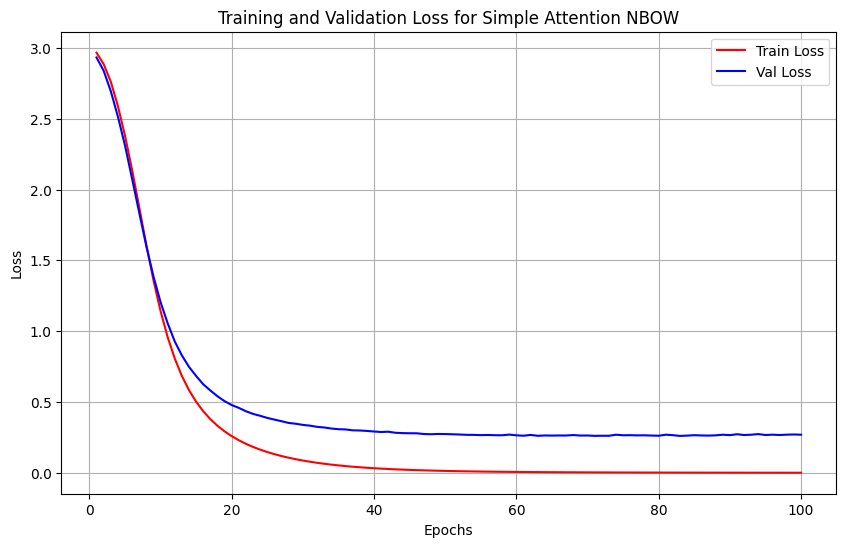

```python
# DO NOT CHANGE THIS CELL - retain the outputs in submission PDF to get credits
plot_loss(train_loss_over_time_sa, val_loss_over_time_sa, 'Simple Attention NBOW')
```

#### 5.1.3. Model Evaluation [2 points - Programming]

The final points for this will be awarded as per Gradescope's test split, which is different from the local versions. The cell below is just for a sanity check. Your metrics here may not exactly match with the ones on Gradescope, but if your model is fairly generalized, it should not be far off.

- 0 points for accuracy <= 85%
- 1 point for accuracy > 85% but <= 90%
- 2 points for accuracy > 90%

```python
# DO NOT CHANGE THIS CELL
learning_rate, epochs, embedding_dim = get_hyperparams_simple_attention()
simple_attention_model = get_simple_attention_model(vocab_size=len(train_vocab.keys()),embedding_dim=embedding_dim).to(device)
load_checkpoint(simple_attention_model, 'simple_attention', map_location=device)

true, pred, val_loss = val_loop(simple_attention_model, criterion, val_iterator)
accuracy, f1 = get_accuracy_and_f1_score(true, pred)
print(f"Final Validation Accuracy: {accuracy}")
print(f"Final Validation F1-Score: {f1}")
```

```
Final Validation Accuracy: 0.9326259946949602
Final Validation F1-Score: 0.930419219531181
```

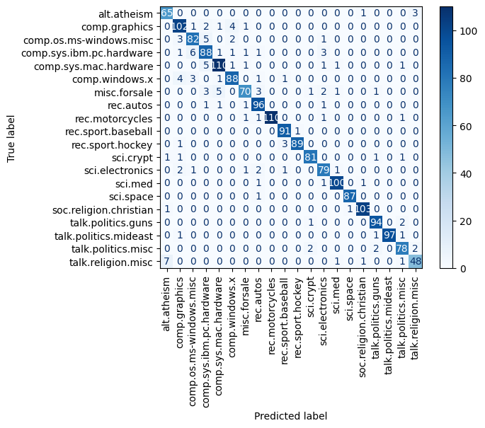

```python
# DO NOT CHANGE THIS CELL
plot_confusion_matrix(true, pred, classes=id2label.values())
```

### 5.2. MultiHead Attention NBOW [7 points - Programming + 3 points - Non-programming]

The prior model only uses a single attention function. In this section, you will implement a multi-head attention model. You will use $k$ attention heads, each with its own parameters $u_i \in R^d$ ($\forall i \in [1..k]$) and a single large vector before the classification to weight them all together $w \in R^{d \cdot k}$.

$$ \alpha_{t,i} \varpropto \exp\{cos(u_i,emb(x_t))\} $$$$ h_{att}(i) = \sum_t\alpha_{t,i} emb(x_t) $$

With the probability of a task instance belonging to class $y_i$ is given by:

$$ p(y|x) = softmax(w^T [h_{att}(1), h_{att}(2), ..., h_{att}(k)]) $$

where [a,b] is the concatenation of vectors $a$ and $b$, into a single taller vector.

#### 5.2.1. Model Definition [5 points - Programming]

Define your Multi-head attention below

```python
#export

class MultiHeadAttentionNBOW(nn.Module):
    def __init__(self, vocab_size, embedding_dim, num_heads, num_classes=20):
        ## YOUR CODE STARTS HERE ##
        super(MultiHeadAttentionNBOW, self).__init__()

        self.vocab_size = vocab_size
        self.embedding_dim = embedding_dim
        self.num_heads = num_heads
        self.num_classes = num_classes

        self.embedding = nn.Embedding(vocab_size, embedding_dim)  # Embedding layer
        # self.attention = nn.Parameter(torch.randn(num_heads, embedding_dim), requires_grad=True)
        self.attention = nn.Embedding(num_heads, embedding_dim)
        self.linear = nn.Linear(embedding_dim*num_heads, num_classes, bias=False)  # Linear layer for classification

        ## YOUR CODE ENDS HERE ##
    def forward(self, x):
        ## YOUR CODE STARTS HERE ##

        attn_matrix = self.get_attention_matrix(x)
        embeddings = self.get_embeddings(x)
        hidden = (embeddings.unsqueeze(-2) * attn_matrix.unsqueeze(-1)).sum(dim=1)  # Apply attention weights and sum over vocab
        hidden_concat = hidden.reshape(hidden.size(0), -1)  # Reshape to (BATCH_SIZE, num_heads * embedding_dim)
        predictions = self.linear(hidden_concat)

        return predictions
        ## YOUR CODE ENDS HERE ##


    def get_embeddings(self, x):
        '''
        This function returns the embeddings of the input x
        '''
        ### YOUR CODE STARTS HERE ###

        return self.embedding(x)

        ### YOUR CODE ENDS HERE ###

    def set_embedding_weight(self, weight):
        '''
        This function sets the embedding weights to the input weight ensure you aren't recording gradients for this
        Args:
            weight: torch.tensor of shape (vocab_size, embedding_dim)
        '''
        ### YOUR CODE STARTS HERE ###

        self.embedding.weight = nn.Parameter(weight, requires_grad=False)

        ### YOUR CODE ENDS HERE ###

    def set_attention_weights(self, weight):
        '''
        This function sets the attention weights to the input weight ensure you aren't recording gradients for this
        Args:
            weight: torch.tensor of shape (num_heads, embedding_dim)
        '''
        ### YOUR CODE STARTS HERE ###

        self.attention.weight.data.copy_(weight)

        ### YOUR CODE ENDS HERE ###

    def get_attention_matrix(self, x):
        '''
        This function returns the normalized attention matrix for the input x
        Args:
            x: torch.tensor of shape (BATCH_SIZE, max seq length in batch))
        Returns:
            attention_weights: torch.tensor of shape (BATCH_SIZE, max seq length in batch, num_heads))
        '''

        ### YOUR CODE STARTS HERE ###
        embeddings = self.get_embeddings(x).unsqueeze(-2) # BATCH_SIZE x max_seq_len x 1 x embedding_dim

        head_ids = torch.arange(self.num_heads, device=x.device)  # shape: [num_heads]
        attn = self.attention(head_ids)  # shape: [num_heads, embedding_dim]
        attn = attn.unsqueeze(0).unsqueeze(0)  # shape: [1, 1, num_heads, embedding_dim]

        # attn = self.attention.unsqueeze(0).unsqueeze(0)  # 1 x 1 x num_heads x embedding_dim
        cos_sim = torch.cosine_similarity(embeddings, attn, dim=-1)

        # Mask to ignore padding tokens
        mask = (x != 0)
        for i in range(self.num_heads):
            cos_sim[:, :, i] = cos_sim[:, :, i].masked_fill(~mask, float('-inf'))

        return torch.softmax(cos_sim, dim=-2)

        ### YOUR CODE ENDS HERE ###
```

```python
# local test for sanity:
# DO NOT CHANGE THIS CELL
def multihead_attn_nbow_test_local():
    embedding_dim = 10
    vocab_size = 10
    num_heads = 3
    model = MultiHeadAttentionNBOW(vocab_size=vocab_size, embedding_dim=embedding_dim, num_heads=num_heads)
    for _, module in model.named_parameters():
        if hasattr(module, "data"):
            nn.init.constant_(module, 0.3)
    input = torch.tensor([[1,2,3,4,0,0,0],
                          [5,6,7,0,0,0,0]]) % vocab_size
    expected_result = torch.tensor(
        [[2.7000, 2.7000, 2.7000, 2.7000, 2.7000, 2.7000, 2.7000, 2.7000, 2.7000,
         2.7000, 2.7000, 2.7000, 2.7000, 2.7000, 2.7000, 2.7000, 2.7000, 2.7000,
         2.7000, 2.7000],
        [2.7000, 2.7000, 2.7000, 2.7000, 2.7000, 2.7000, 2.7000, 2.7000, 2.7000,
         2.7000, 2.7000, 2.7000, 2.7000, 2.7000, 2.7000, 2.7000, 2.7000, 2.7000,
         2.7000, 2.7000]]
    )
    with torch.no_grad():
        local_result = model(input)
    if torch.allclose(expected_result, local_result, rtol=0.001):
        print("Passed local check")
    else:
        print(f"Test failed, expected value was\n{expected_result}\nbut you got:\n{local_result}")

# local test for sanity:
def multi_attention_nbow_test_local_embeddings():
    model = MultiHeadAttentionNBOW(embedding_dim=3, vocab_size=5, num_heads=4)
    model.set_embedding_weight(torch.arange(15).reshape(5,3) / 50)
    embeddings = model.get_embeddings(torch.tensor([[1,2,3,4,1],[1,2,3,0,0]]))
    correct_embeddings = torch.tensor([[[0.0600, 0.0800, 0.1000],
                                        [0.1200, 0.1400, 0.1600],
                                        [0.1800, 0.2000, 0.2200],
                                        [0.2400, 0.2600, 0.2800],
                                        [0.0600, 0.0800, 0.1000]],

                                        [[0.0600, 0.0800, 0.1000],
                                        [0.1200, 0.1400, 0.1600],
                                        [0.1800, 0.2000, 0.2200],
                                        [0.0000, 0.0200, 0.0400],
                                        [0.0000, 0.0200, 0.0400]]])
    if torch.allclose(embeddings, correct_embeddings, rtol=0.001):
        print("Passed local embedding test")
    else:
        print(f"Embedding Test failed, expected value was\n{correct_embeddings}\nbut you got:\n{embeddings}")
def multi_attention_nbow_test_local_attn():
    model = MultiHeadAttentionNBOW(embedding_dim=3, vocab_size=5, num_heads=4)
    model.set_embedding_weight(torch.arange(15).reshape(5,3) / 50)
    model.set_attention_weights(torch.tensor([[0.1, 0.2, 0.3],[0.1, 0.2, 0.3],[0.2, 0.2, 0.2],[0, 0.3, 0.3]]))
    attention_weights = model.get_attention_matrix(torch.tensor([[1,2,3,4,1],[1,2,3,0,0]]))
    correct_attention_weights = torch.tensor([[[0.2033, 0.2033, 0.1981, 0.2052],
                                                [0.1995, 0.1995, 0.2007, 0.1990],
                                                [0.1975, 0.1975, 0.2014, 0.1961],
                                                [0.1964, 0.1964, 0.2017, 0.1945],
                                                [0.2033, 0.2033, 0.1981, 0.2052]],

                                                [[0.3387, 0.3387, 0.3300, 0.3419],
                                                [0.3323, 0.3323, 0.3344, 0.3314],
                                                [0.3290, 0.3290, 0.3356, 0.3267],
                                                [0.0000, 0.0000, 0.0000, 0.0000],
                                                [0.0000, 0.0000, 0.0000, 0.0000]]])
    if torch.allclose(attention_weights, correct_attention_weights, rtol=0.001):
        print("Passed local Attn test")
    else:
        print(f"Attn Test failed, expected value was\n{correct_attention_weights}\nbut you got:\n{attention_weights}")

multi_attention_nbow_test_local_embeddings()
multi_attention_nbow_test_local_attn()
multihead_attn_nbow_test_local()
```

```
Passed local embedding test
Passed local Attn test
Passed local check
```

#### 5.2.2. Model Training [3 points - Non-Programming]

Assign and tune the below hyperparameters to optimize your model

```python
#export
# Assign hyperparameters and training parameters
# Experiment with different values for these hyperparaters to optimize your model's performance
def get_hyperparams_multihead():
    learning_rate = 0.001
    epochs = 100
    num_heads = 4
    embedding_dim = 64
    return learning_rate, epochs, num_heads, embedding_dim
```

```python
#export
def get_multihead_attention_model(vocab_size, embedding_dim, num_heads):
    """
    This function returns an instance of the MultiHeadAttentionNBOW model. Initialize the MultiHeadAttentionNBOW model here and return it.
    """

    ## YOUR CODE STARTS HERE ##
    model = MultiHeadAttentionNBOW(vocab_size=vocab_size, embedding_dim=embedding_dim, num_heads=num_heads)
    ## YOUR CODE ENDS HERE ##
    return model
```

```python
# This is the main training loop. You'll need to complete the train_loop and val_loop functions.
# You'll also need to complete the criterion and optimizer functions.
# Feel free to experiment with different optimizers and learning rates.
# Do not change anything else in this cell
learning_rate, epochs, num_heads, embedding_dim = get_hyperparams_multihead()
multihead_attention_model = get_multihead_attention_model(vocab_size=len(train_vocab.keys()),embedding_dim=embedding_dim, num_heads=num_heads).to(device)
criterion = get_criterion()
optimizer = get_optimizer(multihead_attention_model, learning_rate)
train_loss_over_time_ma = []
val_loss_over_time_ma = []
for epoch in range(epochs):
    train_loss = train_loop(multihead_attention_model, criterion, optimizer, train_iterator, epoch, save_every=2)
    true, pred, val_loss = val_loop(multihead_attention_model, criterion, val_iterator)
    accuracy, f1 = get_accuracy_and_f1_score(true, pred)
    train_loss_over_time_ma.append(train_loss)
    val_loss_over_time_ma.append(val_loss)
    print(f"Epoch {epoch+1} -- Train_Loss: {train_loss} -- Val_Loss: {val_loss} -- Val_Accuracy: {accuracy} -- Val_F1: {f1}")
save_checkpoint(multihead_attention_model, 'multihead_attention')
```

```
Epoch 1 -- Train_Loss: 2.906315944962582 -- Val_Loss: 2.8022900263468427 -- Val_Accuracy: 0.1883289124668435 -- Val_F1: 0.14729380146736817
```

```
Epoch 2 -- Train_Loss: 2.681345270851911 -- Val_Loss: 2.5555703322092693 -- Val_Accuracy: 0.29336870026525197 -- Val_F1: 0.26665702608440095
```

```
Epoch 3 -- Train_Loss: 2.3935031668614535 -- Val_Loss: 2.257174746195475 -- Val_Accuracy: 0.4259946949602122 -- Val_F1: 0.39960491031259354
```

```
Epoch 4 -- Train_Loss: 2.047711328934815 -- Val_Loss: 1.9248628934224448 -- Val_Accuracy: 0.5416445623342175 -- Val_F1: 0.5176586215357492
```

```
Epoch 5 -- Train_Loss: 1.6816964866751332 -- Val_Loss: 1.605420708656311 -- Val_Accuracy: 0.6291777188328912 -- Val_F1: 0.6101839186758002
```

```
Epoch 6 -- Train_Loss: 1.3457765953015473 -- Val_Loss: 1.3267329772313436 -- Val_Accuracy: 0.6870026525198939 -- Val_F1: 0.6737737784311368
```

```
Epoch 7 -- Train_Loss: 1.0657909259957783 -- Val_Loss: 1.1077380537986756 -- Val_Accuracy: 0.7517241379310344 -- Val_F1: 0.7458890106913765
```

```
Epoch 8 -- Train_Loss: 0.8469834065033217 -- Val_Loss: 0.9325661738713582 -- Val_Accuracy: 0.7856763925729443 -- Val_F1: 0.7818064059239169
```

```
Epoch 9 -- Train_Loss: 0.6779169551396774 -- Val_Loss: 0.806107230981191 -- Val_Accuracy: 0.8084880636604774 -- Val_F1: 0.8036511363577683
```

```
Epoch 10 -- Train_Loss: 0.549409685498577 -- Val_Loss: 0.7064006328582764 -- Val_Accuracy: 0.8244031830238727 -- Val_F1: 0.8200686941838926
```

```
Epoch 11 -- Train_Loss: 0.4503943546343658 -- Val_Loss: 0.6332040071487427 -- Val_Accuracy: 0.8392572944297082 -- Val_F1: 0.834224569455001
```

```
Epoch 12 -- Train_Loss: 0.3729341408963931 -- Val_Loss: 0.5746235052744547 -- Val_Accuracy: 0.8493368700265252 -- Val_F1: 0.8446041257259569
```

```
Epoch 13 -- Train_Loss: 0.3116878694144346 -- Val_Loss: 0.5263067285219828 -- Val_Accuracy: 0.8572944297082228 -- Val_F1: 0.8528735628256751
```

```
Epoch 14 -- Train_Loss: 0.2628349916914762 -- Val_Loss: 0.4918580949306488 -- Val_Accuracy: 0.8663129973474801 -- Val_F1: 0.862821137987296
```

```
Epoch 15 -- Train_Loss: 0.2227036891094709 -- Val_Loss: 0.46357223590215046 -- Val_Accuracy: 0.8785145888594165 -- Val_F1: 0.8751364830408956
```

```
Epoch 16 -- Train_Loss: 0.18999337821693743 -- Val_Loss: 0.44546032746632896 -- Val_Accuracy: 0.8816976127320955 -- Val_F1: 0.87881942062651
```

```
Epoch 17 -- Train_Loss: 0.16231568795392068 -- Val_Loss: 0.4182821989059448 -- Val_Accuracy: 0.8885941644562334 -- Val_F1: 0.8853542164700585
```

```
Epoch 18 -- Train_Loss: 0.1393328989713879 -- Val_Loss: 0.40321217974026996 -- Val_Accuracy: 0.8917771883289125 -- Val_F1: 0.8887787300902188
```

```
Epoch 19 -- Train_Loss: 0.11969374158119751 -- Val_Loss: 0.3891665955384572 -- Val_Accuracy: 0.8923076923076924 -- Val_F1: 0.889335470946033
```

```
Epoch 20 -- Train_Loss: 0.10353807751405036 -- Val_Loss: 0.379440838098526 -- Val_Accuracy: 0.8891246684350133 -- Val_F1: 0.8863416366303492
```

```
Epoch 21 -- Train_Loss: 0.08944737895439236 -- Val_Loss: 0.36811613937218984 -- Val_Accuracy: 0.8938992042440318 -- Val_F1: 0.8915249964577938
```

```
Epoch 22 -- Train_Loss: 0.07744861226844585 -- Val_Loss: 0.35415671368439994 -- Val_Accuracy: 0.8992042440318302 -- Val_F1: 0.8963673833889677
```

```
Epoch 23 -- Train_Loss: 0.06711955655808166 -- Val_Loss: 0.3525283853212992 -- Val_Accuracy: 0.9007957559681697 -- Val_F1: 0.8985735602679366
```

```
Epoch 24 -- Train_Loss: 0.05843756868803905 -- Val_Loss: 0.3418917119503021 -- Val_Accuracy: 0.9007957559681697 -- Val_F1: 0.8985727861603954
```

```
Epoch 25 -- Train_Loss: 0.05097273108944044 -- Val_Loss: 0.34074334700902303 -- Val_Accuracy: 0.9018567639257294 -- Val_F1: 0.8996800486784501
```

```
Epoch 26 -- Train_Loss: 0.04454391309202223 -- Val_Loss: 0.33431561291217804 -- Val_Accuracy: 0.9013262599469496 -- Val_F1: 0.8997349785083664
```

```
Epoch 27 -- Train_Loss: 0.03902800120729006 -- Val_Loss: 0.3334189693133036 -- Val_Accuracy: 0.9055702917771883 -- Val_F1: 0.9036317402288864
```

```
Epoch 28 -- Train_Loss: 0.034366293723489774 -- Val_Loss: 0.33016969660917916 -- Val_Accuracy: 0.9071618037135278 -- Val_F1: 0.9054077899980577
```

```
Epoch 29 -- Train_Loss: 0.03029059120690671 -- Val_Loss: 0.3249045670032501 -- Val_Accuracy: 0.9076923076923077 -- Val_F1: 0.9059287729964934
```

```
Epoch 30 -- Train_Loss: 0.026779088302183958 -- Val_Loss: 0.3271378586689631 -- Val_Accuracy: 0.9071618037135278 -- Val_F1: 0.9051426760660439
```

```
Epoch 31 -- Train_Loss: 0.02379984977670898 -- Val_Loss: 0.31840491890907285 -- Val_Accuracy: 0.9071618037135278 -- Val_F1: 0.9056447009320218
```

```
Epoch 32 -- Train_Loss: 0.021145720287399777 -- Val_Loss: 0.31695337692896525 -- Val_Accuracy: 0.9087533156498674 -- Val_F1: 0.9071993856744809
```

```
Epoch 33 -- Train_Loss: 0.018858387663771035 -- Val_Loss: 0.3172996282577515 -- Val_Accuracy: 0.9076923076923077 -- Val_F1: 0.9060015976370485
```

```
Epoch 34 -- Train_Loss: 0.016901373934253294 -- Val_Loss: 0.3200335254271825 -- Val_Accuracy: 0.9076923076923077 -- Val_F1: 0.9061671239732556
```

```
Epoch 35 -- Train_Loss: 0.01514874710464629 -- Val_Loss: 0.31315144697825115 -- Val_Accuracy: 0.9082228116710875 -- Val_F1: 0.9065338603119615
```

```
Epoch 36 -- Train_Loss: 0.013660704606544163 -- Val_Loss: 0.3111183057228724 -- Val_Accuracy: 0.9087533156498674 -- Val_F1: 0.9071160493481116
```

```
Epoch 37 -- Train_Loss: 0.012296315002397208 -- Val_Loss: 0.3133437126874924 -- Val_Accuracy: 0.9087533156498674 -- Val_F1: 0.9071367622362733
```

```
Epoch 38 -- Train_Loss: 0.011113244791562527 -- Val_Loss: 0.3109539916117986 -- Val_Accuracy: 0.9082228116710875 -- Val_F1: 0.906673423052214
```

```
Epoch 39 -- Train_Loss: 0.010039176981327898 -- Val_Loss: 0.31062535345554354 -- Val_Accuracy: 0.9103448275862069 -- Val_F1: 0.9083106847245961
```

```
Epoch 40 -- Train_Loss: 0.009133403663034155 -- Val_Loss: 0.3084143886963526 -- Val_Accuracy: 0.9092838196286472 -- Val_F1: 0.9075372866261102
```

```
Epoch 41 -- Train_Loss: 0.008320208496840323 -- Val_Loss: 0.30656562248865765 -- Val_Accuracy: 0.9092838196286472 -- Val_F1: 0.9077057831754083
```

```
Epoch 42 -- Train_Loss: 0.007562423314330942 -- Val_Loss: 0.30620809098084767 -- Val_Accuracy: 0.9108753315649868 -- Val_F1: 0.9089584588255564
```

```
Epoch 43 -- Train_Loss: 0.006945186641888093 -- Val_Loss: 0.3063694516817729 -- Val_Accuracy: 0.9092838196286472 -- Val_F1: 0.9072154483935637
```

```
Epoch 44 -- Train_Loss: 0.006353367421918122 -- Val_Loss: 0.30502824087937674 -- Val_Accuracy: 0.9087533156498674 -- Val_F1: 0.9068893422265386
```

```
Epoch 45 -- Train_Loss: 0.0058466836502302 -- Val_Loss: 0.3071614811817805 -- Val_Accuracy: 0.9092838196286472 -- Val_F1: 0.9073210330407655
```

```
Epoch 46 -- Train_Loss: 0.005426665489814418 -- Val_Loss: 0.30990139544010165 -- Val_Accuracy: 0.9087533156498674 -- Val_F1: 0.9068035515536218
```

```
Epoch 47 -- Train_Loss: 0.004991157248742499 -- Val_Loss: 0.30694737235705055 -- Val_Accuracy: 0.9098143236074271 -- Val_F1: 0.9077211489394112
```

```
Epoch 48 -- Train_Loss: 0.0046501420004198615 -- Val_Loss: 0.30961797138055164 -- Val_Accuracy: 0.9114058355437665 -- Val_F1: 0.9094988506888558
```

```
Epoch 49 -- Train_Loss: 0.004305384745347803 -- Val_Loss: 0.30560019810994465 -- Val_Accuracy: 0.9114058355437665 -- Val_F1: 0.9093955585073061
```

```
Epoch 50 -- Train_Loss: 0.0039866677183515815 -- Val_Loss: 0.30408838788668313 -- Val_Accuracy: 0.9108753315649868 -- Val_F1: 0.9088339478633294
```

```
Epoch 51 -- Train_Loss: 0.0037327830470561727 -- Val_Loss: 0.30624921520551046 -- Val_Accuracy: 0.9103448275862069 -- Val_F1: 0.9083436138793886
```

```
Epoch 52 -- Train_Loss: 0.003462997156637326 -- Val_Loss: 0.305225870013237 -- Val_Accuracy: 0.9119363395225464 -- Val_F1: 0.909941202777188
```

```
Epoch 53 -- Train_Loss: 0.0032342675406391084 -- Val_Loss: 0.30552170077959695 -- Val_Accuracy: 0.9140583554376658 -- Val_F1: 0.9120765565863017
```

```
Epoch 54 -- Train_Loss: 0.0030304959154356334 -- Val_Loss: 0.3082573587695758 -- Val_Accuracy: 0.9108753315649868 -- Val_F1: 0.9089265786597263
```

```
Epoch 55 -- Train_Loss: 0.002840134201737089 -- Val_Loss: 0.3057665705680847 -- Val_Accuracy: 0.9119363395225464 -- Val_F1: 0.9100903343920645
```

```
Epoch 56 -- Train_Loss: 0.0026368980445914854 -- Val_Loss: 0.30385465224583946 -- Val_Accuracy: 0.9119363395225464 -- Val_F1: 0.9098913281764107
```

```
Epoch 57 -- Train_Loss: 0.0024996567132756493 -- Val_Loss: 0.3063568303982417 -- Val_Accuracy: 0.9114058355437665 -- Val_F1: 0.9095105517309886
```

```
Epoch 58 -- Train_Loss: 0.0023372245881453915 -- Val_Loss: 0.30816385746002195 -- Val_Accuracy: 0.9108753315649868 -- Val_F1: 0.9089428249038886
```

```
Epoch 59 -- Train_Loss: 0.0021928090161162477 -- Val_Loss: 0.31112441221872966 -- Val_Accuracy: 0.9124668435013262 -- Val_F1: 0.9103644166564268
```

```
Epoch 60 -- Train_Loss: 0.0020580959419514667 -- Val_Loss: 0.30748526056607567 -- Val_Accuracy: 0.9140583554376658 -- Val_F1: 0.9119699690573034
```

```
Epoch 61 -- Train_Loss: 0.0019434302610195225 -- Val_Loss: 0.3063999722401301 -- Val_Accuracy: 0.9140583554376658 -- Val_F1: 0.9119611656596657
```

```
Epoch 62 -- Train_Loss: 0.0018440002508429904 -- Val_Loss: 0.3098096271355947 -- Val_Accuracy: 0.9140583554376658 -- Val_F1: 0.9119079388720713
```

```
Epoch 63 -- Train_Loss: 0.0017351362493157514 -- Val_Loss: 0.30745816727479297 -- Val_Accuracy: 0.9135278514588859 -- Val_F1: 0.9115315084501207
```

```
Epoch 64 -- Train_Loss: 0.001646891786318304 -- Val_Loss: 0.3111604392528534 -- Val_Accuracy: 0.9151193633952255 -- Val_F1: 0.9127954290119178
```

```
Epoch 65 -- Train_Loss: 0.0015311621413645097 -- Val_Loss: 0.311762805779775 -- Val_Accuracy: 0.9124668435013262 -- Val_F1: 0.9107229768491265
```

```
Epoch 66 -- Train_Loss: 0.0014253682377984968 -- Val_Loss: 0.30931397577126823 -- Val_Accuracy: 0.9177718832891246 -- Val_F1: 0.915734554809468
```

```
Epoch 67 -- Train_Loss: 0.00135601139864174 -- Val_Loss: 0.30922113060951234 -- Val_Accuracy: 0.9135278514588859 -- Val_F1: 0.9117080602957459
```

```
Epoch 68 -- Train_Loss: 0.0012911604983747889 -- Val_Loss: 0.3120925595362981 -- Val_Accuracy: 0.9145888594164456 -- Val_F1: 0.9124711349471196
```

```
Epoch 69 -- Train_Loss: 0.0012931191555808409 -- Val_Loss: 0.31101692815621695 -- Val_Accuracy: 0.9172413793103448 -- Val_F1: 0.9151001700502096
```

```
Epoch 70 -- Train_Loss: 0.0011450357479141963 -- Val_Loss: 0.3125666081905365 -- Val_Accuracy: 0.9145888594164456 -- Val_F1: 0.9129787957064481
```

```
Epoch 71 -- Train_Loss: 0.0011545597778838445 -- Val_Loss: 0.30831339756647747 -- Val_Accuracy: 0.916710875331565 -- Val_F1: 0.9148740158552249
```

```
Epoch 72 -- Train_Loss: 0.001035685041057088 -- Val_Loss: 0.31166556278864543 -- Val_Accuracy: 0.9156498673740053 -- Val_F1: 0.9136979651113271
```

```
Epoch 73 -- Train_Loss: 0.0010229826135801593 -- Val_Loss: 0.31293499767780303 -- Val_Accuracy: 0.9145888594164456 -- Val_F1: 0.9126081533853716
```

```
Epoch 74 -- Train_Loss: 0.0009877441864819818 -- Val_Loss: 0.3089740072687467 -- Val_Accuracy: 0.9188328912466843 -- Val_F1: 0.9168799626936638
```

```
Epoch 75 -- Train_Loss: 0.0009174552268616981 -- Val_Loss: 0.3116557647784551 -- Val_Accuracy: 0.9156498673740053 -- Val_F1: 0.9137725693453866
```

```
Epoch 76 -- Train_Loss: 0.0008367986800109621 -- Val_Loss: 0.3144735505183538 -- Val_Accuracy: 0.9151193633952255 -- Val_F1: 0.9131694183722482
```

```
Epoch 77 -- Train_Loss: 0.0008535471449357504 -- Val_Loss: 0.3142386510968208 -- Val_Accuracy: 0.916710875331565 -- Val_F1: 0.9144767265209829
```

```
Epoch 78 -- Train_Loss: 0.0007915415140598918 -- Val_Loss: 0.31176676551500954 -- Val_Accuracy: 0.9193633952254642 -- Val_F1: 0.9173479805823478
```

```
Epoch 79 -- Train_Loss: 0.0007469675934555846 -- Val_Loss: 0.3163656105597814 -- Val_Accuracy: 0.9151193633952255 -- Val_F1: 0.9130790163995005
```

```
Epoch 80 -- Train_Loss: 0.0007315173439811757 -- Val_Loss: 0.3176701903343201 -- Val_Accuracy: 0.919893899204244 -- Val_F1: 0.9179408704181753
```

```
Epoch 81 -- Train_Loss: 0.0006744802239601564 -- Val_Loss: 0.31521210769812263 -- Val_Accuracy: 0.9151193633952255 -- Val_F1: 0.9131783364044695
```

```
Epoch 82 -- Train_Loss: 0.0006374351535252911 -- Val_Loss: 0.31438962717851004 -- Val_Accuracy: 0.9172413793103448 -- Val_F1: 0.9152295974690274
```

```
Epoch 83 -- Train_Loss: 0.0006344218849859564 -- Val_Loss: 0.3143624683221181 -- Val_Accuracy: 0.9172413793103448 -- Val_F1: 0.9151653163025595
```

```
Epoch 84 -- Train_Loss: 0.0005826965710384992 -- Val_Loss: 0.3163091699282328 -- Val_Accuracy: 0.9172413793103448 -- Val_F1: 0.9151459947718574
```

```
Epoch 85 -- Train_Loss: 0.0005560624305902728 -- Val_Loss: 0.31731892029444375 -- Val_Accuracy: 0.9183023872679045 -- Val_F1: 0.9166393417748612
```

```
Epoch 86 -- Train_Loss: 0.0005562272475552904 -- Val_Loss: 0.3200887034336726 -- Val_Accuracy: 0.9188328912466843 -- Val_F1: 0.9170958442309571
```

```
Epoch 87 -- Train_Loss: 0.0005067114099678663 -- Val_Loss: 0.3191862255334854 -- Val_Accuracy: 0.9214854111405836 -- Val_F1: 0.9194518188256067
```

```
Epoch 88 -- Train_Loss: 0.0004974072266338488 -- Val_Loss: 0.318350953857104 -- Val_Accuracy: 0.9177718832891246 -- Val_F1: 0.9161316249907866
```

```
Epoch 89 -- Train_Loss: 0.0004727566655196439 -- Val_Loss: 0.3200227638085683 -- Val_Accuracy: 0.9193633952254642 -- Val_F1: 0.9175695302344961
```

```
Epoch 90 -- Train_Loss: 0.0004381134025668686 -- Val_Loss: 0.326184273759524 -- Val_Accuracy: 0.919893899204244 -- Val_F1: 0.918041432656643
```

```
Epoch 91 -- Train_Loss: 0.00045545187840924866 -- Val_Loss: 0.3198323438564936 -- Val_Accuracy: 0.9183023872679045 -- Val_F1: 0.9166347198443028
```

```
Epoch 92 -- Train_Loss: 0.000439993119887392 -- Val_Loss: 0.32055158813794454 -- Val_Accuracy: 0.9220159151193634 -- Val_F1: 0.920062945316595
```

```
Epoch 93 -- Train_Loss: 0.0004159802475611687 -- Val_Loss: 0.3169390728076299 -- Val_Accuracy: 0.9220159151193634 -- Val_F1: 0.920462158491088
```

```
Epoch 94 -- Train_Loss: 0.0003777166583227049 -- Val_Loss: 0.3280866742134094 -- Val_Accuracy: 0.9193633952254642 -- Val_F1: 0.9177531986975535
```

```
Epoch 95 -- Train_Loss: 0.00037148776619549116 -- Val_Loss: 0.32048559486865996 -- Val_Accuracy: 0.9209549071618037 -- Val_F1: 0.9194298946817746
```

```
Epoch 96 -- Train_Loss: 0.00036160931785608703 -- Val_Loss: 0.32453591922918956 -- Val_Accuracy: 0.9220159151193634 -- Val_F1: 0.920434111586923
```

```
Epoch 97 -- Train_Loss: 0.0003412980417956764 -- Val_Loss: 0.32216541667779286 -- Val_Accuracy: 0.9193633952254642 -- Val_F1: 0.917651162190458
```

```
Epoch 98 -- Train_Loss: 0.0003230847724515084 -- Val_Loss: 0.3261110832293828 -- Val_Accuracy: 0.9204244031830239 -- Val_F1: 0.9184674891815664
```

```
Epoch 99 -- Train_Loss: 0.0002971404818539267 -- Val_Loss: 0.3315272976954778 -- Val_Accuracy: 0.9193633952254642 -- Val_F1: 0.9176265830927871
```

```
Epoch 100 -- Train_Loss: 0.00029662458738608096 -- Val_Loss: 0.3253476242224375 -- Val_Accuracy: 0.9220159151193634 -- Val_F1: 0.920063065219581
Checkpoint saved to /home/jblevins32/NLP_HW1/model_weights/checkpoint_multihead_attention_ce.pt
```

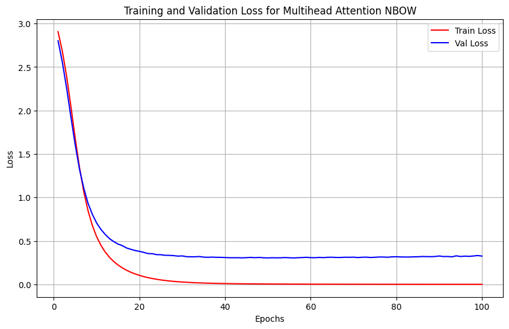

```python
# DO NOT CHANGE THIS CELL - retain the outputs in submission PDF for credits
plot_loss(train_loss_over_time_ma, val_loss_over_time_ma, 'Multihead Attention NBOW')
```

#### 5.2.3. Model Evaluation [2 points - Programming]

The final points for this will be awarded as per Gradescope's test split, which is different from the local versions. The cell below is just for a sanity check. Your metrics here may not exactly match with the ones on Gradescope, but if your model is fairly generalized, it should not be far off.

- 0 points for accuracy <= 85%
- 1 point for accuracy > 85% but <= 90%
- 2 points for accuracy > 90%

```python
# DO NOT CHANGE THIS CELL
learning_rate, epochs, num_heads, embedding_dim = get_hyperparams_multihead()
multihead_attention_model = get_multihead_attention_model(vocab_size=len(train_vocab.keys()),embedding_dim=embedding_dim, num_heads=num_heads).to(device)
load_checkpoint(multihead_attention_model, 'multihead_attention')

true, pred, val_loss = val_loop(multihead_attention_model, criterion, val_iterator)
accuracy, f1 = get_accuracy_and_f1_score(true, pred)
print(f"Final Validation Accuracy: {accuracy}")
print(f"Final Validation F1-Score: {f1}")
```

```
Final Validation Accuracy: 0.9220159151193634
Final Validation F1-Score: 0.920063065219581
```

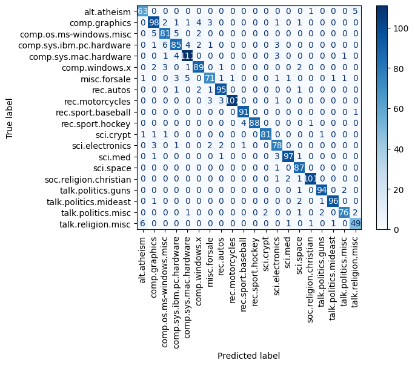

```python
# DO NOT CHANGE THIS CELL
plot_confusion_matrix(true, pred, classes=id2label.values())
```

### 5.3. Self-Attention NBOW [7 points - Programming + 3 points - Non-programming]

Self-attention is a mechanism in neural networks that enables each element in a sequence to consider and weigh the importance of every other element. This facilitates a more nuanced and context-aware representation of the sequence, greatly enhancing the capabilities of models in tasks involving sequential data, particularly in NLP. It has gained prominence with the introduction and success of Transformer models, like BERT, GPT (including GPT-3), and others. This is not a full-fledged implementation of it, but instead a conceptual flavor of the mechanism.

We will now define an encoder that uses a simple form of self-attention when producing attention weights for each word in the sentence: $$a_{ts} = emb(x_t)^Temb(x_s)$$ $$α_t \propto exp(\sum_s a_{ts})$$ $$h_{self} = \sum α_temb(x_t)$$ Then, the probability of a class is given by $$softmax(w^Th_{self})$$ The unnormalized attention weight for a word $x$ is computed using the dot product between its embedding and those for all other words in the sentence, followed by a summation and exponentiation. Unlike the model in Section 5.1., this model does not introduce any new parameters for computing the attention function, simply using the same word embeddings for the attention. Therefore, this model has the same number of parameters as the model in Section 2. For improved stability, we can also add a “residual connection”, which would change Eq. 1 to $$softmax(w^T(h_{self} + h_{avg}))$$ where $h_{avg}$ is computed as in Section 2 (though using the same word embeddings as in $h_{self}$).

#### 5.3.1. Model Definition [5 points - Programming]

Define your self attention model below

```python
#export
class SelfAttentionNBOW(nn.Module):

    def __init__(self, vocab_size, embedding_dim, num_classes=20):
        super(SelfAttentionNBOW, self).__init__()
        # YOUR CODE STARTS HERE

        self.vocab_size = vocab_size
        self.embedding_dim = embedding_dim
        self.num_classes = num_classes

        self.embedding = nn.Embedding(vocab_size, embedding_dim)
        self.linear = nn.Linear(embedding_dim, num_classes, bias=False)  # Linear layer for classification

        # YOUR CODE ENDS HERE

    def forward(self, x):
        # YOUR CODE STARTS HERE

        embeddings = self.get_embeddings(x)  # Get embeddings
        attention_matrix = self.get_attention_matrix(x)  # Get attention matrix
        h_self = (embeddings * attention_matrix.unsqueeze(-1)).sum(dim=1)
        h_avg = embeddings.mean(dim=1)  # Average over the sequence length
        predictions = self.linear(h_self+h_avg)
        return predictions

        # YOUR CODE ENDS HERE
    def get_embeddings(self, x):
        '''
        This function returns the embeddings of the input x
        '''
        ### YOUR CODE STARTS HERE ###
        return self.embedding(x)
        ### YOUR CODE ENDS HERE ###

    def set_embedding_weight(self, weight):
        '''
        This function sets the embedding weights to the input weight ensure you aren't recording gradients for this
        Args:
            weight: torch.tensor of shape (vocab_size, embedding_dim)
        '''
        ### YOUR CODE STARTS HERE ###
        self.embedding.weight = nn.Parameter(weight, requires_grad=False)
        ### YOUR CODE ENDS HERE ###

    def get_attention_matrix(self, x):
        '''
        This function returns the normalized attention matrix for the input x
        Args:
            x: torch.tensor of shape (BATCH_SIZE, max seq length in batch)
        Returns:
            attention_weights: torch.tensor of shape (BATCH_SIZE, max seq length in batch)
        '''
        ### YOUR CODE STARTS HERE ###

        embeddings = self.get_embeddings(x)  # BATCH_SIZE x max_seq_len x embedding_dim
        embeddings[x==0] = 0  # Set padding tokens to zero

        attn = torch.matmul(embeddings,embeddings.transpose(1, 2))  # BATCH_SIZE x max_seq_len x max_seq_len
        attn = attn.sum(-1)

        attn[attn == 0] = float('-inf')  # Set padding tokens to -inf

        return torch.softmax(attn, dim=-1)

        ### YOUR CODE ENDS HERE ###
```

```python
# local test for sanity:
def self_attention_nbow_test_local():
    model = SelfAttentionNBOW(vocab_size=10, embedding_dim=10)
    for _, module in model.named_parameters():
        if hasattr(module, "data"):
            nn.init.constant_(module, 0.3)
    input = torch.tensor([[1,2,3,4,0,0,0],
                          [5,6,7,0,0,0,0]]) % 10

    expected_result = torch.tensor(
        [[1.8000, 1.8000, 1.8000, 1.8000, 1.8000, 1.8000, 1.8000, 1.8000, 1.8000,
         1.8000, 1.8000, 1.8000, 1.8000, 1.8000, 1.8000, 1.8000, 1.8000, 1.8000,
         1.8000, 1.8000],
        [1.8000, 1.8000, 1.8000, 1.8000, 1.8000, 1.8000, 1.8000, 1.8000, 1.8000,
         1.8000, 1.8000, 1.8000, 1.8000, 1.8000, 1.8000, 1.8000, 1.8000, 1.8000,
         1.8000, 1.8000]]
    )
    with torch.no_grad():
        local_result = model(input)
    if torch.allclose(expected_result, local_result, rtol=0.001):
        print("Passed local check")
    else:
        print(f"Test failed, expected value was\n{expected_result}\nbut you got:\n{local_result}")

def self_attention_nbow_test_local_embeddings():
    model = SelfAttentionNBOW(vocab_size=5, embedding_dim=3)
    model.set_embedding_weight(torch.arange(15).reshape(5, 3) / 50)
    embeddings = model.get_embeddings(torch.tensor([[1, 2, 3, 4, 1], [1, 2, 3, 0, 0]]))
    correct_embeddings = torch.tensor([[[0.0600, 0.0800, 0.1000],
                                        [0.1200, 0.1400, 0.1600],
                                        [0.1800, 0.2000, 0.2200],
                                        [0.2400, 0.2600, 0.2800],
                                        [0.0600, 0.0800, 0.1000]],

                                        [[0.0600, 0.0800, 0.1000],
                                        [0.1200, 0.1400, 0.1600],
                                        [0.1800, 0.2000, 0.2200],
                                        [0.0000, 0.0200, 0.0400],
                                        [0.0000, 0.0200, 0.0400]]])
    if torch.allclose(embeddings, correct_embeddings, rtol=0.001):
        print("Passed local embedding test")
    else:
        print(f"Embedding Test failed, expected value was\n{correct_embeddings}\nbut you got:\n{embeddings}")

def self_attention_nbow_test_local_attn():
    model = SelfAttentionNBOW(vocab_size=5, embedding_dim=3)
    model.set_embedding_weight(torch.arange(15).reshape(5,3) / 50)
    attention_weights = model.get_attention_matrix(torch.tensor([[1,2,3,4,1],[1,2,3,0,0]]))
    correct_attention_weights = torch.tensor([[0.1675, 0.1921, 0.2203, 0.2526, 0.1675],
        [0.3085, 0.3327, 0.3588, 0.0000, 0.0000]])
    if torch.allclose(attention_weights, correct_attention_weights, rtol=0.001):
        print("Passed local Attn test")
    else:
        print(f"Attn Test failed, expected value was\n{correct_attention_weights}\nbut you got:\n{attention_weights}")
self_attention_nbow_test_local()
self_attention_nbow_test_local_embeddings()
self_attention_nbow_test_local_attn()
```

```
Passed local check
Passed local embedding test
Passed local Attn test
```

```python
#export
def get_self_attention_model(vocab_size, embedding_dim):
    """
    This function returns an instance of the Self Attention model. Initialize the Self Attention model here and return it.
    """
    ## YOUR CODE STARTS HERE ##

    model = SelfAttentionNBOW(vocab_size=vocab_size, embedding_dim=embedding_dim)

    ## YOUR CODE ENDS HERE ##
    return model
```

#### 5.3.2. Model Training [3 points - Non-Programming]

Assign and tune the below hyperparameters to optimize your model

```python
#export
# Assign hyperparameters and training parameters
# Experiment with different values for these hyperparaters to optimize your model's performance
def get_hyperparams_self_attn():
    learning_rate = 0.001
    epochs = 75
    embedding_dim = 325
    return learning_rate, epochs, embedding_dim
```

```python
# This is the main training loop. You'll need to complete the train_loop and val_loop functions.
# You'll also need to complete the criterion and optimizer functions.
# Feel free to experiment with different optimizers and learning rates.
# Do not change anything else in this cell
learning_rate, epochs, embedding_dim = get_hyperparams_self_attn()
self_attention_model = get_self_attention_model(len(train_vocab.keys()),embedding_dim).to(device)
criterion = get_criterion()
optimizer = get_optimizer(self_attention_model, learning_rate)
train_loss_over_time_sea = []
val_loss_over_time_sea = []
for epoch in range(epochs):
    train_loss = train_loop(self_attention_model, criterion, optimizer, train_iterator, epoch, save_every=2)
    true, pred, val_loss = val_loop(self_attention_model, criterion, val_iterator)
    accuracy, f1 = get_accuracy_and_f1_score(true, pred)
    train_loss_over_time_sea.append(train_loss)
    val_loss_over_time_sea.append(val_loss)
    print(f"Epoch {epoch+1} -- Train_Loss: {train_loss} -- Val_Loss: {val_loss} -- Val_Accuracy: {accuracy} -- Val_F1: {f1}")
save_checkpoint(self_attention_model, 'self_attention')
```

```
Epoch 1 -- Train_Loss: 2.9592467829332514 -- Val_Loss: 2.926609977086385 -- Val_Accuracy: 0.07055702917771883 -- Val_F1: 0.029097231020752796
```

```
Epoch 2 -- Train_Loss: 2.8758264719429665 -- Val_Loss: 2.8756086190541583 -- Val_Accuracy: 0.07586206896551724 -- Val_F1: 0.029952831547668334
```

```
Epoch 3 -- Train_Loss: 2.802042015528275 -- Val_Loss: 2.7731769402821858 -- Val_Accuracy: 0.2763925729442971 -- Val_F1: 0.21106017489311432
```

```
Epoch 4 -- Train_Loss: 2.69698596202721 -- Val_Loss: 2.664374589920044 -- Val_Accuracy: 0.2838196286472148 -- Val_F1: 0.2363851646067427
```

```
Epoch 5 -- Train_Loss: 2.5539582038329818 -- Val_Loss: 2.53699475924174 -- Val_Accuracy: 0.33793103448275863 -- Val_F1: 0.30667125850435056
```

```
Epoch 6 -- Train_Loss: 2.3797956725298346 -- Val_Loss: 2.3492825826009116 -- Val_Accuracy: 0.5527851458885942 -- Val_F1: 0.5336541781150704
```

```
Epoch 7 -- Train_Loss: 2.1838701044098805 -- Val_Loss: 2.1673627694447837 -- Val_Accuracy: 0.5347480106100796 -- Val_F1: 0.518859719119451
```

```
Epoch 8 -- Train_Loss: 1.9735280154115062 -- Val_Loss: 1.9608746767044067 -- Val_Accuracy: 0.6068965517241379 -- Val_F1: 0.5856346442992597
```

```
Epoch 9 -- Train_Loss: 1.758643543316146 -- Val_Loss: 1.7664338986078898 -- Val_Accuracy: 0.6997347480106101 -- Val_F1: 0.6756266602311719
```

```
Epoch 10 -- Train_Loss: 1.5495265287868047 -- Val_Loss: 1.601196527481079 -- Val_Accuracy: 0.7411140583554376 -- Val_F1: 0.7397178686904158
```

```
Epoch 11 -- Train_Loss: 1.3664675051883115 -- Val_Loss: 1.4607777039210001 -- Val_Accuracy: 0.793633952254642 -- Val_F1: 0.7917355683913417
```

```
Epoch 12 -- Train_Loss: 1.2176330796742842 -- Val_Loss: 1.3332606315612794 -- Val_Accuracy: 0.8063660477453581 -- Val_F1: 0.8047871314945445
```

```
Epoch 13 -- Train_Loss: 1.0850779995069666 -- Val_Loss: 1.232083249092102 -- Val_Accuracy: 0.8047745358090186 -- Val_F1: 0.7925063254714813
```

```
Epoch 14 -- Train_Loss: 0.9629915533429485 -- Val_Loss: 1.166469971338908 -- Val_Accuracy: 0.8259946949602122 -- Val_F1: 0.826153897410783
```

```
Epoch 15 -- Train_Loss: 0.8722849159927691 -- Val_Loss: 1.0847530563672383 -- Val_Accuracy: 0.8456233421750663 -- Val_F1: 0.843082217420968
```

```
Epoch 16 -- Train_Loss: 0.7867132096977557 -- Val_Loss: 1.0486876527468363 -- Val_Accuracy: 0.8567639257294429 -- Val_F1: 0.8525364495294167
```

```
Epoch 17 -- Train_Loss: 0.718879689351987 -- Val_Loss: 0.9888978362083435 -- Val_Accuracy: 0.8588859416445623 -- Val_F1: 0.8584190525665747
```

```
Epoch 18 -- Train_Loss: 0.6530447955858909 -- Val_Loss: 0.9513086080551147 -- Val_Accuracy: 0.8557029177718833 -- Val_F1: 0.8579015031573208
```

```
Epoch 19 -- Train_Loss: 0.5964614925748211 -- Val_Loss: 0.9185652216275533 -- Val_Accuracy: 0.8737400530503979 -- Val_F1: 0.871543126381966
```

```
Epoch 20 -- Train_Loss: 0.5486053074315443 -- Val_Loss: 0.8693795204162598 -- Val_Accuracy: 0.8790450928381963 -- Val_F1: 0.8776160977123734
```

```
Epoch 21 -- Train_Loss: 0.5071634700742819 -- Val_Loss: 0.8272573828697205 -- Val_Accuracy: 0.8923076923076924 -- Val_F1: 0.888564072328496
```

```
Epoch 22 -- Train_Loss: 0.48301961942244387 -- Val_Loss: 0.8006306330362956 -- Val_Accuracy: 0.8864721485411141 -- Val_F1: 0.8863670756835106
```

```
Epoch 23 -- Train_Loss: 0.4328869922181307 -- Val_Loss: 0.7398487210273743 -- Val_Accuracy: 0.8854111405835544 -- Val_F1: 0.8839632659382349
```

```
Epoch 24 -- Train_Loss: 0.4001784534272501 -- Val_Loss: 0.7114685535430908 -- Val_Accuracy: 0.8944297082228116 -- Val_F1: 0.8908079413584871
```

```
Epoch 25 -- Train_Loss: 0.3696012370667215 -- Val_Loss: 0.7140479207038879 -- Val_Accuracy: 0.8854111405835544 -- Val_F1: 0.8843274234966175
```

```
Epoch 26 -- Train_Loss: 0.3444178005901434 -- Val_Loss: 0.6994900325934092 -- Val_Accuracy: 0.9002652519893899 -- Val_F1: 0.898898737197162
```

```
Epoch 27 -- Train_Loss: 0.324377543087733 -- Val_Loss: 0.6731488128503164 -- Val_Accuracy: 0.89973474801061 -- Val_F1: 0.8990501251269348
```

```
Epoch 28 -- Train_Loss: 0.30121131822214287 -- Val_Loss: 0.6582881410916647 -- Val_Accuracy: 0.8981432360742706 -- Val_F1: 0.8957975429170763
```

```
Epoch 29 -- Train_Loss: 0.275690901835086 -- Val_Loss: 0.6538000841935475 -- Val_Accuracy: 0.9039787798408488 -- Val_F1: 0.9039370594199381
```

```
Epoch 30 -- Train_Loss: 0.26406015897706403 -- Val_Loss: 0.6506999691327413 -- Val_Accuracy: 0.9092838196286472 -- Val_F1: 0.9072492157115718
```

```
Epoch 31 -- Train_Loss: 0.24624966943668106 -- Val_Loss: 0.6052935818831126 -- Val_Accuracy: 0.9156498673740053 -- Val_F1: 0.911962570628009
```

```
Epoch 32 -- Train_Loss: 0.23330136237003035 -- Val_Loss: 0.60141019821167 -- Val_Accuracy: 0.9071618037135278 -- Val_F1: 0.9046887213682389
```

```
Epoch 33 -- Train_Loss: 0.21848611962997308 -- Val_Loss: 0.5911133786042532 -- Val_Accuracy: 0.9076923076923077 -- Val_F1: 0.905940287495824
```

```
Epoch 34 -- Train_Loss: 0.2151772482162815 -- Val_Loss: 0.6014670530954996 -- Val_Accuracy: 0.9135278514588859 -- Val_F1: 0.9114734777127959
```

```
Epoch 35 -- Train_Loss: 0.20677966845490164 -- Val_Loss: 0.6029410024483999 -- Val_Accuracy: 0.9145888594164456 -- Val_F1: 0.9128702019724662
```

```
Epoch 36 -- Train_Loss: 0.19625013372150518 -- Val_Loss: 0.6198497593402863 -- Val_Accuracy: 0.916710875331565 -- Val_F1: 0.9154813142210199
```

```
Epoch 37 -- Train_Loss: 0.18732975638013774 -- Val_Loss: 0.6321134746074677 -- Val_Accuracy: 0.9114058355437665 -- Val_F1: 0.9095696079912517
```

```
Epoch 38 -- Train_Loss: 0.17275003526928062 -- Val_Loss: 0.6111564417680104 -- Val_Accuracy: 0.9161803713527852 -- Val_F1: 0.914155554705393
```

```
Epoch 39 -- Train_Loss: 0.15697739854202433 -- Val_Loss: 0.5992642641067505 -- Val_Accuracy: 0.9183023872679045 -- Val_F1: 0.9163409841685155
```

```
Epoch 40 -- Train_Loss: 0.15532736202417793 -- Val_Loss: 0.5850864350795746 -- Val_Accuracy: 0.9246684350132626 -- Val_F1: 0.9221972001225145
```

```
Epoch 41 -- Train_Loss: 0.1458587940087763 -- Val_Loss: 0.577665795882543 -- Val_Accuracy: 0.9220159151193634 -- Val_F1: 0.9204458247926857
```

```
Epoch 42 -- Train_Loss: 0.14343809847862032 -- Val_Loss: 0.5881808578968049 -- Val_Accuracy: 0.9177718832891246 -- Val_F1: 0.9173320992600468
```

```
Epoch 43 -- Train_Loss: 0.13663919579427122 -- Val_Loss: 0.6516404648621877 -- Val_Accuracy: 0.9193633952254642 -- Val_F1: 0.9175621923646717
```

```
Epoch 44 -- Train_Loss: 0.12502453520388926 -- Val_Loss: 0.6074328382809957 -- Val_Accuracy: 0.9241379310344827 -- Val_F1: 0.9226807752652766
```

```
Epoch 45 -- Train_Loss: 0.11863370672247167 -- Val_Loss: 0.609367753068606 -- Val_Accuracy: 0.919893899204244 -- Val_F1: 0.9186141868584325
```

```
Epoch 46 -- Train_Loss: 0.10710506788376024 -- Val_Loss: 0.6466879864533742 -- Val_Accuracy: 0.9209549071618037 -- Val_F1: 0.9197542645910726
```

```
Epoch 47 -- Train_Loss: 0.10105909621816571 -- Val_Loss: 0.6145662218332291 -- Val_Accuracy: 0.919893899204244 -- Val_F1: 0.918247159974723
```

```
Epoch 48 -- Train_Loss: 0.1053453987874722 -- Val_Loss: 0.6242246836423874 -- Val_Accuracy: 0.9241379310344827 -- Val_F1: 0.9227301686976332
```

```
Epoch 49 -- Train_Loss: 0.09559402498021974 -- Val_Loss: 0.5051327824592591 -- Val_Accuracy: 0.9209549071618037 -- Val_F1: 0.9191953131392614
```

```
Epoch 50 -- Train_Loss: 0.0876656055639861 -- Val_Loss: 0.5080058594544729 -- Val_Accuracy: 0.919893899204244 -- Val_F1: 0.9173710442704994
```

```
Epoch 51 -- Train_Loss: 0.08173191822055033 -- Val_Loss: 0.49650386770566307 -- Val_Accuracy: 0.9241379310344827 -- Val_F1: 0.9216469320775891
```

```
Epoch 52 -- Train_Loss: 0.07748873759124239 -- Val_Loss: 0.5671000887950262 -- Val_Accuracy: 0.9230769230769231 -- Val_F1: 0.9216171731994255
```

```
Epoch 53 -- Train_Loss: 0.07235239862890566 -- Val_Loss: 0.5573825856049855 -- Val_Accuracy: 0.9246684350132626 -- Val_F1: 0.9233496687209393
```

```
Epoch 54 -- Train_Loss: 0.06907624385114443 -- Val_Loss: 0.5815749019384384 -- Val_Accuracy: 0.9241379310344827 -- Val_F1: 0.9223728829560354
```

```
Epoch 55 -- Train_Loss: 0.07139930321629774 -- Val_Loss: 0.6083996216456096 -- Val_Accuracy: 0.9204244031830239 -- Val_F1: 0.9197366902136264
```

```
Epoch 56 -- Train_Loss: 0.06291190648483018 -- Val_Loss: 0.5957271933555603 -- Val_Accuracy: 0.9257294429708223 -- Val_F1: 0.9235145530927603
```

```
Epoch 57 -- Train_Loss: 0.05838155779608731 -- Val_Loss: 0.6201493432124455 -- Val_Accuracy: 0.9236074270557029 -- Val_F1: 0.9206053523837155
```

```
Epoch 58 -- Train_Loss: 0.056585865710877765 -- Val_Loss: 0.6230511397123337 -- Val_Accuracy: 0.9236074270557029 -- Val_F1: 0.9225754070841059
```

```
Epoch 59 -- Train_Loss: 0.056782617312619243 -- Val_Loss: 0.6097996552785238 -- Val_Accuracy: 0.9236074270557029 -- Val_F1: 0.922004190308721
```

```
Epoch 60 -- Train_Loss: 0.05106931478100813 -- Val_Loss: 0.6111311544974645 -- Val_Accuracy: 0.9241379310344827 -- Val_F1: 0.9222782731040283
```

```
Epoch 61 -- Train_Loss: 0.05036725271177494 -- Val_Loss: 0.5876982460419337 -- Val_Accuracy: 0.9262599469496021 -- Val_F1: 0.924219891904668
```

```
Epoch 62 -- Train_Loss: 0.054842917295962065 -- Val_Loss: 0.5808425714572271 -- Val_Accuracy: 0.9262599469496021 -- Val_F1: 0.9244395858612549
```

```
Epoch 63 -- Train_Loss: 0.046100279995066634 -- Val_Loss: 0.5754780997832616 -- Val_Accuracy: 0.9305039787798408 -- Val_F1: 0.9287275645745948
```

```
Epoch 64 -- Train_Loss: 0.04450191647382611 -- Val_Loss: 0.6008957654237748 -- Val_Accuracy: 0.926790450928382 -- Val_F1: 0.925010244795294
```

```
Epoch 65 -- Train_Loss: 0.039733120303411605 -- Val_Loss: 0.5901280283927918 -- Val_Accuracy: 0.9241379310344827 -- Val_F1: 0.9225920514754742
```

```
Epoch 66 -- Train_Loss: 0.03918689788492807 -- Val_Loss: 0.6121596296628317 -- Val_Accuracy: 0.9246684350132626 -- Val_F1: 0.9239054177226198
```

```
Epoch 67 -- Train_Loss: 0.03613560350801227 -- Val_Loss: 0.5876810650030772 -- Val_Accuracy: 0.9251989389920424 -- Val_F1: 0.9233956970463056
```

```
Epoch 68 -- Train_Loss: 0.03589826454487392 -- Val_Loss: 0.6100352287292481 -- Val_Accuracy: 0.9315649867374005 -- Val_F1: 0.930070041378239
```

```
Epoch 69 -- Train_Loss: 0.03293700248665982 -- Val_Loss: 0.590600335597992 -- Val_Accuracy: 0.926790450928382 -- Val_F1: 0.9254261519840714
```

```
Epoch 70 -- Train_Loss: 0.042935721402577426 -- Val_Loss: 0.5858898450930913 -- Val_Accuracy: 0.9294429708222812 -- Val_F1: 0.9276821844186885
```

```
Epoch 71 -- Train_Loss: 0.03401365502090272 -- Val_Loss: 0.579642437895139 -- Val_Accuracy: 0.9273209549071618 -- Val_F1: 0.9256135619550833
```

```
Epoch 72 -- Train_Loss: 0.03154278063546803 -- Val_Loss: 0.588711041212082 -- Val_Accuracy: 0.9283819628647215 -- Val_F1: 0.9254440777483133
```

```
Epoch 73 -- Train_Loss: 0.02985863197373889 -- Val_Loss: 0.600075188279152 -- Val_Accuracy: 0.9257294429708223 -- Val_F1: 0.9235399499434086
```

```
Epoch 74 -- Train_Loss: 0.03170039189853153 -- Val_Loss: 0.5543366183837255 -- Val_Accuracy: 0.9246684350132626 -- Val_F1: 0.9221171225692139
```

```
Epoch 75 -- Train_Loss: 0.02742261810512361 -- Val_Loss: 0.5537789165973663 -- Val_Accuracy: 0.9257294429708223 -- Val_F1: 0.9244003932244397
Checkpoint saved to /home/jblevins32/NLP_HW1/model_weights/checkpoint_self_attention_ce.pt
```

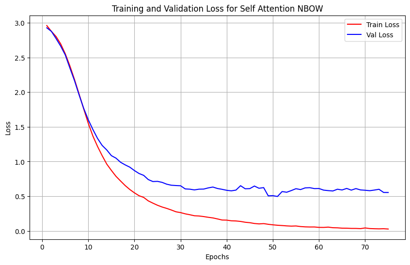

```python
# DO NOT CHANGE THIS CELL - retain the outputs in submission PDF for credits
plot_loss(train_loss_over_time_sea, val_loss_over_time_sea, 'Self Attention NBOW')
```

#### 5.3.3. Model Evaluation Model Evaluation [2 points - Programming]

The final points for this will be awarded as per Gradescope's test split, which is different from the local versions. The cell below is just for a sanity check. Your metrics here may not exactly match with the ones on Gradescope, but if your model is fairly generalized, it should not be far off.

- 0 points for accuracy <= 85%
- 1 point for accuracy > 85% but <= 90%
- 2 points for accuracy > 90%

```python
# DO NOT CHANGE THIS CELL
learning_rate, epochs, embedding_dim = get_hyperparams_self_attn()
self_attention_model = get_self_attention_model(len(train_vocab.keys()),embedding_dim).to(device)
load_checkpoint(self_attention_model, 'self_attention', map_location=device)

true, pred, val_loss = val_loop(self_attention_model, criterion, val_iterator)
accuracy, f1 = get_accuracy_and_f1_score(true, pred)
print(f"Final Validation Accuracy: {accuracy}")
print(f"Final Validation F1-Score: {f1}")
```

```
Final Validation Accuracy: 0.9257294429708223
Final Validation F1-Score: 0.9244003932244397
```

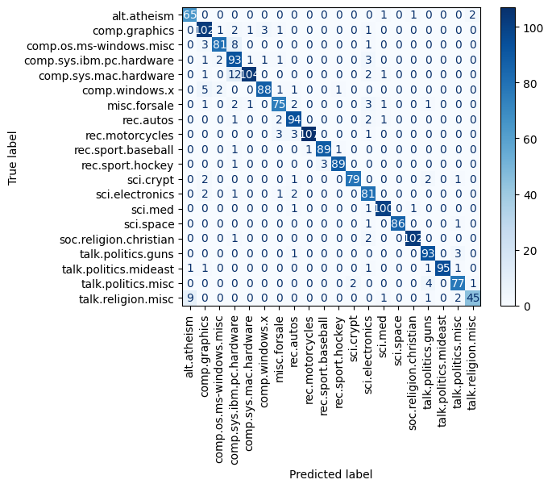

```python
# DO NOT CHANGE THIS CELL
plot_confusion_matrix(true, pred, classes=id2label.values())
```

## 6. Perceptron and Hinge Losses (16 Points - Programming)

### 6.1. Perceptron Loss (5 points - Programming)

The perceptron loss penalizes the model only when the true class is not the most confident prediction. If the model incorrectly assigns a higher score to another class, the perceptron loss encourages the model to adjust its weights to fix this mistake.

This is achieved by considering the difference between the maximum score among all other classes and the score of the true class. If the maximum incorrect score is higher than the true class score, the model receives a penalty proportional to how much worse the true class was predicted compared to the highest incorrect class.

Given a set of predictions from the perceptron model for a batch of samples, we denote:

- $ \mathbf{y} \in \mathbb{R}^{B \times C} $: The matrix of predicted scores, where $B$ is the batch size and $C$ is the number of classes. Each row represents the predicted scores for one sample.
- $\mathbf{y}_{\text{true}} \in \{0, 1, \ldots, C-1\}^{B}$: The ground truth labels, where each entry is an integer representing the correct class label for each sample.

For a given sample ( i ), let:

- $s_j $ be the score for class $j$ (from the predicted score vector).
- $ s_{\text{true}} $ be the score for the true class.

The **perceptron loss** for data instance $x_i$ is defined as:

$$ L_{\text{perceptron}}(i) = \max \left( 0, \max_{j} (s_j) - s_{\text{true}} \right) $$

For batches, we compute the loss for each sample and take the mean over the batch

Implement this PerceptronLoss in the forward method below.

NOTE: The scores are logits, the predictions of models before doing any softmax.

```python
# export

class PerceptronLoss(nn.Module):
    def __init__(self):
        super(PerceptronLoss, self).__init__()

    def forward(self, predictions, labels):
        """
        Calculate the perceptron loss between predictions and labels.

        Args:
            predictions (torch.Tensor): The predictions from the model for a batch of inputs.
                                        Shape should be (batch_size, num_classes).
            labels (torch.Tensor): The ground truth labels for each input in the batch.
                                   Shape should be (batch_size,) with each value between 0 and num_classes-1.

        Returns:
            scalar: The mean perceptron loss for the batch.
        """

        # YOUR CODE STARTS HERE

        pred_probs = torch.softmax(predictions, dim=-1)  # Convert logits to probabilities
        pred_chosen = torch.max(predictions,axis=-1).values # Choose the max prediction for each sample
        idx = torch.arange(pred_probs.size(0))
        error = pred_chosen - predictions[idx,labels] # Find error between the chosen prediction and the true label
        loss = torch.mean(torch.clamp(error, min=0))  # Calculate the mean perceptron loss

        # YOUR CODE ENDS HERE
        return loss
```

```python
# DO NOT CHANGE THIS CELL
perceptron_loss = PerceptronLoss()

def test_correct_classification():
    predictions = torch.tensor([[3.0, 2.0, 1.0],
                                [1.0, 4.0, 2.0]])
    labels = torch.tensor([0, 1])
    loss = perceptron_loss(predictions, labels).item()
    expected_loss = 0.0
    rtol = 0.001  # Relative tolerance
    if abs(expected_loss - loss) <= rtol * abs(expected_loss):
        print('Test case passed for correct classification')
    else:
        print(f"Test case failed for correct classification, expected value was\n{expected_loss}\nbut you got:\n{loss}")

# Test for incorrect classification
def test_incorrect_classification():
    predictions = torch.tensor([[1.0, 3.0, 2.0],
                                [1.0, 2.0, 4.0]])
    labels = torch.tensor([0, 1])

    expected_loss = 2.0
    loss = perceptron_loss(predictions, labels).item()

    rtol = 0.001  # Relative tolerance
    if abs(expected_loss - loss) <= rtol * abs(expected_loss):
        print('Test case passed for incorrect classification')
    else:
        print(f"Test case failed for incorrect classification, expected value was\n{expected_loss}\nbut you got:\n{loss}")

# Execute test cases
test_correct_classification()
test_incorrect_classification()
```

```
Test case passed for correct classification
Test case passed for incorrect classification
```

### 6.2. NBOW Training using Perceptron Loss (3 points - Programming)

Credits will be awarded as per the following final results on the Gradescope split -

- 0 points for accuracy <= 75%
- 1 point for accuracy > 75% but <= 80%
- 2 points for accuracy > 80%

```python
# This is the main training loop. You'll need to complete the train_loop and val_loop functions.
# You'll also need to complete the criterion and optimizer functions.
# Feel free to experiment with different optimizers and learning rates.
# Do not change anything else in this cell
learning_rate, epochs, embedding_dim = get_hyperparams_nbow()
nbow_model = get_nbow_model(vocab_size= len(train_vocab.keys()), embedding_dim = embedding_dim).to(device)
criterion = PerceptronLoss()
optimizer = get_optimizer(nbow_model, learning_rate)
train_loss_over_time_perceptron = []
val_loss_over_time_perceptron = []
for epoch in range(epochs):
    train_loss = train_loop(nbow_model, criterion, optimizer, train_iterator, epoch, save_every=2)
    true, pred, val_loss = val_loop(nbow_model, criterion, val_iterator)
    accuracy, f1 = get_accuracy_and_f1_score(true, pred)
    train_loss_over_time_perceptron.append(train_loss)
    val_loss_over_time_perceptron.append(val_loss)
    print(f"Epoch {epoch+1} -- Train_Loss: {train_loss} -- Val_Loss: {val_loss} -- Val_Accuracy: {accuracy} -- Val_F1: {f1}")

save_checkpoint(nbow_model, 'nbow', loss_fn='perceptron')
```

```
Epoch 1 -- Train_Loss: 0.07428356462110908 -- Val_Loss: 0.039916851868232094 -- Val_Accuracy: 0.17877984084880635 -- Val_F1: 0.17164694666262276
```

```
Epoch 2 -- Train_Loss: 0.028621195436660515 -- Val_Loss: 0.022973261773586273 -- Val_Accuracy: 0.29549071618037137 -- Val_F1: 0.2911820134726499
```

```
Epoch 3 -- Train_Loss: 0.01665818067741091 -- Val_Loss: 0.01585029133905967 -- Val_Accuracy: 0.38090185676392574 -- Val_F1: 0.3812149791492696
```

```
Epoch 4 -- Train_Loss: 0.010879953616788075 -- Val_Loss: 0.012452174288531145 -- Val_Accuracy: 0.4244031830238727 -- Val_F1: 0.4192382301618077
```

```
Epoch 5 -- Train_Loss: 0.007757013963566998 -- Val_Loss: 0.010088338578740755 -- Val_Accuracy: 0.46684350132625996 -- Val_F1: 0.46466601519690637
```

```
Epoch 6 -- Train_Loss: 0.005799048994588903 -- Val_Loss: 0.008264035452157259 -- Val_Accuracy: 0.4986737400530504 -- Val_F1: 0.49441500622466783
```

```
Epoch 7 -- Train_Loss: 0.004514509989580108 -- Val_Loss: 0.007123694817225138 -- Val_Accuracy: 0.5320954907161803 -- Val_F1: 0.5292133392312341
```

```
Epoch 8 -- Train_Loss: 0.003571908986116996 -- Val_Loss: 0.006546323218693336 -- Val_Accuracy: 0.5480106100795756 -- Val_F1: 0.5484142953961005
```

```
Epoch 9 -- Train_Loss: 0.0028279696589225303 -- Val_Loss: 0.0058765841027100885 -- Val_Accuracy: 0.5814323607427055 -- Val_F1: 0.5786680378545781
```

```
Epoch 10 -- Train_Loss: 0.002426973614107691 -- Val_Loss: 0.0054301772887508076 -- Val_Accuracy: 0.5941644562334217 -- Val_F1: 0.5922744322898933
```

```
Epoch 11 -- Train_Loss: 0.001899078777415078 -- Val_Loss: 0.005249048117548227 -- Val_Accuracy: 0.6143236074270557 -- Val_F1: 0.6092059729596203
```

```
Epoch 12 -- Train_Loss: 0.0016730050122270644 -- Val_Loss: 0.004723187303170562 -- Val_Accuracy: 0.6196286472148541 -- Val_F1: 0.6198079586568669
```

```
Epoch 13 -- Train_Loss: 0.0015120447329166583 -- Val_Loss: 0.004697921592742205 -- Val_Accuracy: 0.6477453580901856 -- Val_F1: 0.6423520842174137
```

```
Epoch 14 -- Train_Loss: 0.001206145521205992 -- Val_Loss: 0.004889758117496967 -- Val_Accuracy: 0.6318302387267904 -- Val_F1: 0.6276743407469704
```

```
Epoch 15 -- Train_Loss: 0.0010384224218087492 -- Val_Loss: 0.004567160472894708 -- Val_Accuracy: 0.6551724137931034 -- Val_F1: 0.6503411373307737
```

```
Epoch 16 -- Train_Loss: 0.0008786710944042494 -- Val_Loss: 0.004672664295261105 -- Val_Accuracy: 0.6535809018567639 -- Val_F1: 0.648439408101265
```

```
Epoch 17 -- Train_Loss: 0.0007757922171780808 -- Val_Loss: 0.0042598081442217035 -- Val_Accuracy: 0.6859416445623342 -- Val_F1: 0.6824559223464325
```

```
Epoch 18 -- Train_Loss: 0.0006749812887006803 -- Val_Loss: 0.004292373762776454 -- Val_Accuracy: 0.6811671087533157 -- Val_F1: 0.6775989716638184
```

```
Epoch 19 -- Train_Loss: 0.0006007965867727269 -- Val_Loss: 0.0044778754624227686 -- Val_Accuracy: 0.6694960212201592 -- Val_F1: 0.6716610314654888
```

```
Epoch 20 -- Train_Loss: 0.0005518340878583239 -- Val_Loss: 0.003936258905256788 -- Val_Accuracy: 0.6986737400530504 -- Val_F1: 0.6972800971020605
```

```
Epoch 21 -- Train_Loss: 0.00040814436671730544 -- Val_Loss: 0.004211613877365987 -- Val_Accuracy: 0.6992042440318302 -- Val_F1: 0.6945952045693446
```

```
Epoch 22 -- Train_Loss: 0.00042599365948817804 -- Val_Loss: 0.004325546976178885 -- Val_Accuracy: 0.7045092838196286 -- Val_F1: 0.7010677090994764
```

```
Epoch 23 -- Train_Loss: 0.00039881328441463093 -- Val_Loss: 0.004197209840640426 -- Val_Accuracy: 0.7082228116710876 -- Val_F1: 0.703983016514486
```

```
Epoch 24 -- Train_Loss: 0.000285159836679113 -- Val_Loss: 0.004445059038698673 -- Val_Accuracy: 0.7114058355437666 -- Val_F1: 0.7086192935476937
```

```
Epoch 25 -- Train_Loss: 0.00032390147680416703 -- Val_Loss: 0.004425371577963233 -- Val_Accuracy: 0.7198938992042441 -- Val_F1: 0.7140915219610022
```

```
Epoch 26 -- Train_Loss: 0.0003121005713059646 -- Val_Loss: 0.004803114105015993 -- Val_Accuracy: 0.7087533156498673 -- Val_F1: 0.7063698297238785
```

```
Epoch 27 -- Train_Loss: 0.0002849773338805219 -- Val_Loss: 0.004156070481985808 -- Val_Accuracy: 0.7283819628647215 -- Val_F1: 0.726098324396765
```

```
Epoch 28 -- Train_Loss: 0.00020644441222322126 -- Val_Loss: 0.00451484490185976 -- Val_Accuracy: 0.7273209549071618 -- Val_F1: 0.7228391809495204
```

```
Epoch 29 -- Train_Loss: 0.00021667904760668813 -- Val_Loss: 0.004301211129253109 -- Val_Accuracy: 0.7416445623342175 -- Val_F1: 0.741326339222148
```

```
Epoch 30 -- Train_Loss: 0.00020212969281003726 -- Val_Loss: 0.00447682742960751 -- Val_Accuracy: 0.7389920424403184 -- Val_F1: 0.7352367113635235
```

```
Epoch 31 -- Train_Loss: 0.0002478775613935333 -- Val_Loss: 0.004543438677986463 -- Val_Accuracy: 0.7374005305039788 -- Val_F1: 0.7353216803522709
```

```
Epoch 32 -- Train_Loss: 0.0001422233876606481 -- Val_Loss: 0.004503441493337353 -- Val_Accuracy: 0.7453580901856764 -- Val_F1: 0.741692619829615
```

```
Epoch 33 -- Train_Loss: 0.00022075268351712157 -- Val_Loss: 0.004499114444479346 -- Val_Accuracy: 0.7416445623342175 -- Val_F1: 0.7392170638757561
```

```
Epoch 34 -- Train_Loss: 0.0001951886409542413 -- Val_Loss: 0.0046771757149448 -- Val_Accuracy: 0.7411140583554376 -- Val_F1: 0.7396630065025513
```

```
Epoch 35 -- Train_Loss: 0.00017966330890007063 -- Val_Loss: 0.004506311239674687 -- Val_Accuracy: 0.7389920424403184 -- Val_F1: 0.7369248345236443
```

```
Epoch 36 -- Train_Loss: 0.0001332884633684752 -- Val_Loss: 0.004667209197456638 -- Val_Accuracy: 0.7389920424403184 -- Val_F1: 0.7364144995078361
```

```
Epoch 37 -- Train_Loss: 0.00015043614220596315 -- Val_Loss: 0.0046401865314692255 -- Val_Accuracy: 0.7442970822281167 -- Val_F1: 0.7427124289255167
```

```
Epoch 38 -- Train_Loss: 0.00014076671427034652 -- Val_Loss: 0.005049325448150436 -- Val_Accuracy: 0.7453580901856764 -- Val_F1: 0.7423659329435599
```

```
Epoch 39 -- Train_Loss: 0.00018967506986296878 -- Val_Loss: 0.0048699045553803446 -- Val_Accuracy: 0.7549071618037135 -- Val_F1: 0.7512407792331766
```

```
Epoch 40 -- Train_Loss: 0.00019008429573998803 -- Val_Loss: 0.004801033157855272 -- Val_Accuracy: 0.7538461538461538 -- Val_F1: 0.7527717129682865
```

```
Epoch 41 -- Train_Loss: 0.0001123924655800338 -- Val_Loss: 0.004887292875597874 -- Val_Accuracy: 0.7575596816976128 -- Val_F1: 0.7562795395502016
```

```
Epoch 42 -- Train_Loss: 0.00011554048436109798 -- Val_Loss: 0.004898572200909257 -- Val_Accuracy: 0.7618037135278515 -- Val_F1: 0.7599255112257433
```

```
Epoch 43 -- Train_Loss: 0.0001170494358382835 -- Val_Loss: 0.005136479778836171 -- Val_Accuracy: 0.746419098143236 -- Val_F1: 0.745681510044335
```

```
Epoch 44 -- Train_Loss: 0.0001248846908881313 -- Val_Loss: 0.005387051900227865 -- Val_Accuracy: 0.7623342175066313 -- Val_F1: 0.7587814908119659
```

```
Epoch 45 -- Train_Loss: 0.00014176859011798623 -- Val_Loss: 0.005063025094568729 -- Val_Accuracy: 0.7644562334217506 -- Val_F1: 0.7629717018479385
```

```
Epoch 46 -- Train_Loss: 0.0001570271718773549 -- Val_Loss: 0.005547996517270804 -- Val_Accuracy: 0.7559681697612732 -- Val_F1: 0.7565759755589607
```

```
Epoch 47 -- Train_Loss: 0.00015391808850281295 -- Val_Loss: 0.005553495821853479 -- Val_Accuracy: 0.7496021220159151 -- Val_F1: 0.7468740200031981
```

```
Epoch 48 -- Train_Loss: 0.00012670091764756746 -- Val_Loss: 0.005272466642782092 -- Val_Accuracy: 0.76657824933687 -- Val_F1: 0.7647805367900713
```

```
Epoch 49 -- Train_Loss: 0.00013530078359832198 -- Val_Loss: 0.0055748268806686 -- Val_Accuracy: 0.7676392572944297 -- Val_F1: 0.7648670611150434
```

```
Epoch 50 -- Train_Loss: 7.740798568100494e-05 -- Val_Loss: 0.005951933562755585 -- Val_Accuracy: 0.7687002652519894 -- Val_F1: 0.7679728248139861
```

```
Epoch 51 -- Train_Loss: 0.0001228387128182892 -- Val_Loss: 0.005740267224609852 -- Val_Accuracy: 0.7755968169761274 -- Val_F1: 0.773981512270913
```

```
Epoch 52 -- Train_Loss: 0.00010581866346479204 -- Val_Loss: 0.005823521688580513 -- Val_Accuracy: 0.7655172413793103 -- Val_F1: 0.7648864778518647
```

```
Epoch 53 -- Train_Loss: 6.459487368544106e-05 -- Val_Loss: 0.00560225040341417 -- Val_Accuracy: 0.7708222811671087 -- Val_F1: 0.7707811807060063
```

```
Epoch 54 -- Train_Loss: 4.453611731829153e-05 -- Val_Loss: 0.005646248006572326 -- Val_Accuracy: 0.7750663129973475 -- Val_F1: 0.7744807968990858
```

```
Epoch 55 -- Train_Loss: 7.996061235721523e-05 -- Val_Loss: 0.005759945760170619 -- Val_Accuracy: 0.7798408488063661 -- Val_F1: 0.7793663955631884
```

```
Epoch 56 -- Train_Loss: 7.640581316081807e-05 -- Val_Loss: 0.0061343511256078875 -- Val_Accuracy: 0.7798408488063661 -- Val_F1: 0.7761281552029039
```

```
Epoch 57 -- Train_Loss: 0.00012601727952241454 -- Val_Loss: 0.005779040946314732 -- Val_Accuracy: 0.7750663129973475 -- Val_F1: 0.7732272956719833
```

```
Epoch 58 -- Train_Loss: 0.00011344670152323226 -- Val_Loss: 0.0063620377021531265 -- Val_Accuracy: 0.7697612732095491 -- Val_F1: 0.7637371405395258
```

```
Epoch 59 -- Train_Loss: 0.00010190483056757623 -- Val_Loss: 0.006203734983379642 -- Val_Accuracy: 0.7771883289124668 -- Val_F1: 0.7775788693915242
```

```
Epoch 60 -- Train_Loss: 8.304514668159724e-05 -- Val_Loss: 0.006307166302576661 -- Val_Accuracy: 0.7846153846153846 -- Val_F1: 0.7837436194492956
```

```
Epoch 61 -- Train_Loss: 7.721118311303021e-05 -- Val_Loss: 0.005859738712509473 -- Val_Accuracy: 0.7851458885941645 -- Val_F1: 0.7814534590004573
```

```
Epoch 62 -- Train_Loss: 8.206157964827903e-05 -- Val_Loss: 0.006470984468857448 -- Val_Accuracy: 0.7750663129973475 -- Val_F1: 0.773821657212793
```

```
Epoch 63 -- Train_Loss: 4.8711450259453794e-05 -- Val_Loss: 0.006368144896502296 -- Val_Accuracy: 0.7782493368700265 -- Val_F1: 0.7777146154646911
```

```
Epoch 64 -- Train_Loss: 7.118880048283708e-05 -- Val_Loss: 0.006400393694639206 -- Val_Accuracy: 0.789920424403183 -- Val_F1: 0.7865328727299279
```

```
Epoch 65 -- Train_Loss: 7.14017699819879e-05 -- Val_Loss: 0.0063915176317095755 -- Val_Accuracy: 0.7814323607427056 -- Val_F1: 0.7781044530941962
```

```
Epoch 66 -- Train_Loss: 9.778942118781882e-05 -- Val_Loss: 0.006438256551822026 -- Val_Accuracy: 0.7877984084880637 -- Val_F1: 0.7876341654586758
```

```
Epoch 67 -- Train_Loss: 3.7986421745499376e-05 -- Val_Loss: 0.006704682980974515 -- Val_Accuracy: 0.7856763925729443 -- Val_F1: 0.7847812796117537
```

```
Epoch 68 -- Train_Loss: 8.568534507256857e-05 -- Val_Loss: 0.006923573246846597 -- Val_Accuracy: 0.7777188328912467 -- Val_F1: 0.7751512651032321
```

```
Epoch 69 -- Train_Loss: 9.083044815115962e-05 -- Val_Loss: 0.006922051698590319 -- Val_Accuracy: 0.7840848806366048 -- Val_F1: 0.7823252077303893
```

```
Epoch 70 -- Train_Loss: 8.013950694368173e-05 -- Val_Loss: 0.0073920352384448055 -- Val_Accuracy: 0.7835543766578249 -- Val_F1: 0.7832254891942807
```

```
Epoch 71 -- Train_Loss: 9.709182496269438e-05 -- Val_Loss: 0.007231931574642659 -- Val_Accuracy: 0.7888594164456233 -- Val_F1: 0.7887190751163384
```

```
Epoch 72 -- Train_Loss: 7.743921409108502e-05 -- Val_Loss: 0.006644200099011262 -- Val_Accuracy: 0.7957559681697612 -- Val_F1: 0.793898286125291
```

```
Epoch 73 -- Train_Loss: 4.500830575618577e-05 -- Val_Loss: 0.007092565375690659 -- Val_Accuracy: 0.7904509283819628 -- Val_F1: 0.7901792497526949
```

```
Epoch 74 -- Train_Loss: 5.670876013120228e-05 -- Val_Loss: 0.007489223716159662 -- Val_Accuracy: 0.7761273209549071 -- Val_F1: 0.7751151037751366
```

```
Epoch 75 -- Train_Loss: 6.34166652285415e-05 -- Val_Loss: 0.007306805470337471 -- Val_Accuracy: 0.7872679045092839 -- Val_F1: 0.7861083806875192
```

```
Epoch 76 -- Train_Loss: 9.360414678359137e-05 -- Val_Loss: 0.006773955685396989 -- Val_Accuracy: 0.793633952254642 -- Val_F1: 0.7919516342631262
```

```
Epoch 77 -- Train_Loss: 7.049370432761892e-05 -- Val_Loss: 0.006843552583207687 -- Val_Accuracy: 0.7984084880636605 -- Val_F1: 0.7989857289804114
```

```
Epoch 78 -- Train_Loss: 3.652454312432999e-05 -- Val_Loss: 0.006740667577832937 -- Val_Accuracy: 0.7941644562334218 -- Val_F1: 0.7951673343431307
```

```
Epoch 79 -- Train_Loss: 3.2039925380081125e-05 -- Val_Loss: 0.007335215589652459 -- Val_Accuracy: 0.7904509283819628 -- Val_F1: 0.7893896050232858
```

```
Epoch 80 -- Train_Loss: 6.558609829418424e-05 -- Val_Loss: 0.006969801336526871 -- Val_Accuracy: 0.8010610079575596 -- Val_F1: 0.8003271284869715
```

```
Epoch 81 -- Train_Loss: 3.2880664132219756e-05 -- Val_Loss: 0.007428899873048067 -- Val_Accuracy: 0.7952254641909814 -- Val_F1: 0.7931700071271751
```

```
Epoch 82 -- Train_Loss: 9.880554574981758e-05 -- Val_Loss: 0.007726054110874733 -- Val_Accuracy: 0.7994694960212202 -- Val_F1: 0.7996757157418718
```

```
Epoch 83 -- Train_Loss: 0.0001416678849451828 -- Val_Loss: 0.008028526231646538 -- Val_Accuracy: 0.7904509283819628 -- Val_F1: 0.7880699332577816
```

```
Epoch 84 -- Train_Loss: 7.025085062072692e-05 -- Val_Loss: 0.007860257104039193 -- Val_Accuracy: 0.7941644562334218 -- Val_F1: 0.7920414611380534
```

```
Epoch 85 -- Train_Loss: 3.942068921741477e-05 -- Val_Loss: 0.007442522281780839 -- Val_Accuracy: 0.8063660477453581 -- Val_F1: 0.8052505971383624
```

```
Epoch 86 -- Train_Loss: 7.289798705349282e-06 -- Val_Loss: 0.0076367588092883425 -- Val_Accuracy: 0.8 -- Val_F1: 0.7986033979189544
```

```
Epoch 87 -- Train_Loss: 1.0935636039949575e-05 -- Val_Loss: 0.007812485269581278 -- Val_Accuracy: 0.8047745358090186 -- Val_F1: 0.8032583880628514
```

```
Epoch 88 -- Train_Loss: 1.1785289073378732e-05 -- Val_Loss: 0.007385191010932128 -- Val_Accuracy: 0.7989389920424403 -- Val_F1: 0.7966219127672854
```

```
Epoch 89 -- Train_Loss: 2.0981563173305497e-05 -- Val_Loss: 0.007976745876173178 -- Val_Accuracy: 0.7973474801061008 -- Val_F1: 0.797926794146923
```

```
Epoch 90 -- Train_Loss: 3.116952661835289e-05 -- Val_Loss: 0.008221654283503691 -- Val_Accuracy: 0.7957559681697612 -- Val_F1: 0.7934481194492767
```

```
Epoch 91 -- Train_Loss: 4.8044028887288425e-05 -- Val_Loss: 0.008073656571408112 -- Val_Accuracy: 0.7920424403183024 -- Val_F1: 0.7911635330584026
```

```
Epoch 92 -- Train_Loss: 8.684236444562469e-05 -- Val_Loss: 0.008171933920433123 -- Val_Accuracy: 0.7962864721485411 -- Val_F1: 0.795139571128179
```

```
Epoch 93 -- Train_Loss: 0.000162896214440757 -- Val_Loss: 0.008769496033589045 -- Val_Accuracy: 0.7968169761273209 -- Val_F1: 0.7945700329827043
```

```
Epoch 94 -- Train_Loss: 6.338348735510609e-05 -- Val_Loss: 0.008608879055827856 -- Val_Accuracy: 0.793633952254642 -- Val_F1: 0.7949195445955051
```

```
Epoch 95 -- Train_Loss: 5.6552598064210883e-05 -- Val_Loss: 0.008172308700159192 -- Val_Accuracy: 0.7994694960212202 -- Val_F1: 0.7986549990621986
```

```
Epoch 96 -- Train_Loss: 3.3690344287729745e-05 -- Val_Loss: 0.008420789831628401 -- Val_Accuracy: 0.7989389920424403 -- Val_F1: 0.7992454489051836
```

```
Epoch 97 -- Train_Loss: 3.4991090414824625e-05 -- Val_Loss: 0.008532540686428548 -- Val_Accuracy: 0.8005305039787799 -- Val_F1: 0.7989879682556321
```

```
Epoch 98 -- Train_Loss: 4.580716257019588e-05 -- Val_Loss: 0.00868071091050903 -- Val_Accuracy: 0.7925729442970822 -- Val_F1: 0.7895594875959254
```

```
Epoch 99 -- Train_Loss: 0.000120491401087177 -- Val_Loss: 0.008744334460546573 -- Val_Accuracy: 0.7962864721485411 -- Val_F1: 0.7935469857480074
```

```
Epoch 100 -- Train_Loss: 7.794068986155345e-05 -- Val_Loss: 0.008402210536102454 -- Val_Accuracy: 0.810079575596817 -- Val_F1: 0.8082680718368216
```

```
Epoch 101 -- Train_Loss: 1.316033801955755e-05 -- Val_Loss: 0.00884016922985514 -- Val_Accuracy: 0.8084880636604774 -- Val_F1: 0.8077485397086578
```

```
Epoch 102 -- Train_Loss: 2.111429476842158e-05 -- Val_Loss: 0.008519686510165532 -- Val_Accuracy: 0.8122015915119364 -- Val_F1: 0.8103581650577538
```

```
Epoch 103 -- Train_Loss: 5.3648472372916036e-05 -- Val_Loss: 0.008420874116321404 -- Val_Accuracy: 0.8068965517241379 -- Val_F1: 0.8048222848530424
```

```
Epoch 104 -- Train_Loss: 2.477667565749548e-05 -- Val_Loss: 0.008954392094165087 -- Val_Accuracy: 0.8010610079575596 -- Val_F1: 0.8020369980503919
```

```
Epoch 105 -- Train_Loss: 8.584220175457708e-06 -- Val_Loss: 0.00832031313329935 -- Val_Accuracy: 0.8127320954907162 -- Val_F1: 0.8129622318289875
```

```
Epoch 106 -- Train_Loss: 8.689939361721696e-06 -- Val_Loss: 0.00832986794412136 -- Val_Accuracy: 0.8122015915119364 -- Val_F1: 0.8110847418506746
```

```
Epoch 107 -- Train_Loss: 2.6981958969480405e-05 -- Val_Loss: 0.009157393717517455 -- Val_Accuracy: 0.8053050397877984 -- Val_F1: 0.8040057241685397
```

```
Epoch 108 -- Train_Loss: 1.920915975322221e-05 -- Val_Loss: 0.00886489146699508 -- Val_Accuracy: 0.8095490716180371 -- Val_F1: 0.8091349486227767
```

```
Epoch 109 -- Train_Loss: 2.703242531979567e-05 -- Val_Loss: 0.009100378335764011 -- Val_Accuracy: 0.8047745358090186 -- Val_F1: 0.803451922932507
```

```
Epoch 110 -- Train_Loss: 7.875493068595307e-05 -- Val_Loss: 0.009800689636419217 -- Val_Accuracy: 0.7968169761273209 -- Val_F1: 0.7960933474141181
```

```
Epoch 111 -- Train_Loss: 5.304255158743047e-05 -- Val_Loss: 0.009151063269625108 -- Val_Accuracy: 0.8116710875331565 -- Val_F1: 0.8080840439400656
```

```
Epoch 112 -- Train_Loss: 2.1016795703178365e-05 -- Val_Loss: 0.009598137127856414 -- Val_Accuracy: 0.8074270557029177 -- Val_F1: 0.8044811452011279
```

```
Epoch 113 -- Train_Loss: 3.931037805406219e-05 -- Val_Loss: 0.009540882675598066 -- Val_Accuracy: 0.8116710875331565 -- Val_F1: 0.8086011250899656
```

```
Epoch 114 -- Train_Loss: 2.745731331218602e-05 -- Val_Loss: 0.009172012936323881 -- Val_Accuracy: 0.8164456233421751 -- Val_F1: 0.8149488419999573
```

```
Epoch 115 -- Train_Loss: 2.507488312341778e-05 -- Val_Loss: 0.009383609580496947 -- Val_Accuracy: 0.8111405835543767 -- Val_F1: 0.8098615524652686
```

```
Epoch 116 -- Train_Loss: 3.4454979359614266e-05 -- Val_Loss: 0.00935486820526421 -- Val_Accuracy: 0.8148541114058355 -- Val_F1: 0.8151696455110455
```

```
Epoch 117 -- Train_Loss: 5.681168655983283e-05 -- Val_Loss: 0.009656000944475333 -- Val_Accuracy: 0.8058355437665783 -- Val_F1: 0.8052975195997863
```

```
Epoch 118 -- Train_Loss: 8.626145871071997e-05 -- Val_Loss: 0.009900377690792083 -- Val_Accuracy: 0.8143236074270557 -- Val_F1: 0.8123801763013935
```

```
Epoch 119 -- Train_Loss: 0.00011960120691120687 -- Val_Loss: 0.009483167467017968 -- Val_Accuracy: 0.8201591511936339 -- Val_F1: 0.8195267407136223
```

```
Epoch 120 -- Train_Loss: 1.6118243920727302e-05 -- Val_Loss: 0.009383765577028195 -- Val_Accuracy: 0.8148541114058355 -- Val_F1: 0.8140909742212534
```

```
Epoch 121 -- Train_Loss: 2.6724403388640386e-05 -- Val_Loss: 0.009897180957098801 -- Val_Accuracy: 0.8053050397877984 -- Val_F1: 0.8054698507278374
```

```
Epoch 122 -- Train_Loss: 6.12887823204431e-05 -- Val_Loss: 0.00995968608185649 -- Val_Accuracy: 0.8058355437665783 -- Val_F1: 0.8046857296520133
```

```
Epoch 123 -- Train_Loss: 2.860063509384202e-05 -- Val_Loss: 0.009410075439761082 -- Val_Accuracy: 0.8074270557029177 -- Val_F1: 0.8066251722202791
```

```
Epoch 124 -- Train_Loss: 6.161699706877945e-06 -- Val_Loss: 0.009710028953850269 -- Val_Accuracy: 0.813262599469496 -- Val_F1: 0.8127696760873327
```

```
Epoch 125 -- Train_Loss: 8.309769821037553e-06 -- Val_Loss: 0.009499704123785098 -- Val_Accuracy: 0.8122015915119364 -- Val_F1: 0.8117826232236635
```

```
Epoch 126 -- Train_Loss: 1.7804694480373194e-05 -- Val_Loss: 0.009512803827722868 -- Val_Accuracy: 0.803183023872679 -- Val_F1: 0.8028527477836143
```

```
Epoch 127 -- Train_Loss: 1.4522637021570009e-05 -- Val_Loss: 0.0096346455005308 -- Val_Accuracy: 0.8079575596816976 -- Val_F1: 0.8064229908073075
```

```
Epoch 128 -- Train_Loss: 3.8177812110901006e-05 -- Val_Loss: 0.009879695841421683 -- Val_Accuracy: 0.8106100795755968 -- Val_F1: 0.8107444054229462
```

```
Epoch 129 -- Train_Loss: 4.1061813767478504e-05 -- Val_Loss: 0.010126721113920212 -- Val_Accuracy: 0.8026525198938992 -- Val_F1: 0.8004926744765217
```

```
Epoch 130 -- Train_Loss: 4.492884539304522e-05 -- Val_Loss: 0.009963524341583253 -- Val_Accuracy: 0.8153846153846154 -- Val_F1: 0.8140560752699939
```

```
Epoch 131 -- Train_Loss: 6.118445002110833e-06 -- Val_Loss: 0.010037674972166618 -- Val_Accuracy: 0.813262599469496 -- Val_F1: 0.8113632122514325
```

```
Epoch 132 -- Train_Loss: 4.826305962909581e-06 -- Val_Loss: 0.009737941746910414 -- Val_Accuracy: 0.8180371352785146 -- Val_F1: 0.8169500461886342
```

```
Epoch 133 -- Train_Loss: 5.634391573810224e-06 -- Val_Loss: 0.009895954125871262 -- Val_Accuracy: 0.8116710875331565 -- Val_F1: 0.8101180954619915
```

```
Epoch 134 -- Train_Loss: 4.560855844736857e-06 -- Val_Loss: 0.010188478728135426 -- Val_Accuracy: 0.8084880636604774 -- Val_F1: 0.8070122362412862
```

```
Epoch 135 -- Train_Loss: 5.568955803952985e-06 -- Val_Loss: 0.009821911187221607 -- Val_Accuracy: 0.8190981432360742 -- Val_F1: 0.8179070550019925
```

```
Epoch 136 -- Train_Loss: 1.4638036422399899e-05 -- Val_Loss: 0.0101483433196942 -- Val_Accuracy: 0.8116710875331565 -- Val_F1: 0.8093842038327212
```

```
Epoch 137 -- Train_Loss: 9.59524684546168e-05 -- Val_Loss: 0.010011993627995253 -- Val_Accuracy: 0.8111405835543767 -- Val_F1: 0.8093272078554247
```

```
Epoch 138 -- Train_Loss: 0.00012042736032804064 -- Val_Loss: 0.010546121435860792 -- Val_Accuracy: 0.8084880636604774 -- Val_F1: 0.8078406862603688
```

```
Epoch 139 -- Train_Loss: 2.4994898891329008e-05 -- Val_Loss: 0.010528809949755668 -- Val_Accuracy: 0.8111405835543767 -- Val_F1: 0.8084770356439257
```

```
Epoch 140 -- Train_Loss: 4.947068114465071e-06 -- Val_Loss: 0.010314954134325186 -- Val_Accuracy: 0.8196286472148541 -- Val_F1: 0.8186284910925299
```

```
Epoch 141 -- Train_Loss: 2.6081973204381323e-05 -- Val_Loss: 0.010315640363842249 -- Val_Accuracy: 0.8137931034482758 -- Val_F1: 0.8108538313330665
```

```
Epoch 142 -- Train_Loss: 1.2809965945484305e-05 -- Val_Loss: 0.010262213399012883 -- Val_Accuracy: 0.8137931034482758 -- Val_F1: 0.8114376980266647
```

```
Epoch 143 -- Train_Loss: 6.732269586359892e-05 -- Val_Loss: 0.010741666456063588 -- Val_Accuracy: 0.8169761273209549 -- Val_F1: 0.8155703509513451
```

```
Epoch 144 -- Train_Loss: 4.318254058628138e-05 -- Val_Loss: 0.010956840900083384 -- Val_Accuracy: 0.8164456233421751 -- Val_F1: 0.8138442029041911
```

```
Epoch 145 -- Train_Loss: 6.679793739872905e-05 -- Val_Loss: 0.011418364321192106 -- Val_Accuracy: 0.8106100795755968 -- Val_F1: 0.8090334563711034
```

```
Epoch 146 -- Train_Loss: 8.640534607535702e-06 -- Val_Loss: 0.011039747763425112 -- Val_Accuracy: 0.8169761273209549 -- Val_F1: 0.8143967553568553
```

```
Epoch 147 -- Train_Loss: 1.1391690596780282e-05 -- Val_Loss: 0.011944501971205076 -- Val_Accuracy: 0.8116710875331565 -- Val_F1: 0.8091274316774296
```

```
Epoch 148 -- Train_Loss: 1.3658146460745799e-05 -- Val_Loss: 0.010941754685093959 -- Val_Accuracy: 0.8148541114058355 -- Val_F1: 0.8137034128436202
```

```
Epoch 149 -- Train_Loss: 4.606325449658779e-05 -- Val_Loss: 0.01095170086870591 -- Val_Accuracy: 0.8185676392572945 -- Val_F1: 0.8160877942056096
```

```
Epoch 150 -- Train_Loss: 1.2031708492786956e-05 -- Val_Loss: 0.010838674350331227 -- Val_Accuracy: 0.8153846153846154 -- Val_F1: 0.8135148079466141
Checkpoint saved to /home/jblevins32/NLP_HW1/model_weights/checkpoint_nbow_perceptron.pt
```

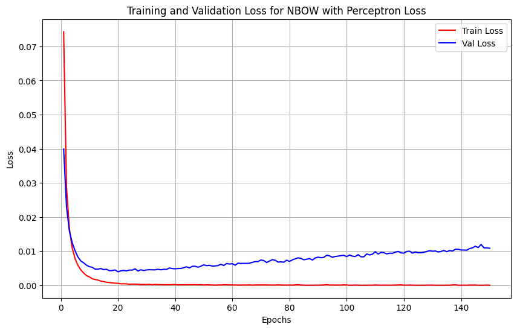

```python
# DO NOT CHANGE THIS CELL
plot_loss(train_loss_over_time_perceptron, val_loss_over_time_perceptron, 'NBOW with Perceptron Loss')
```

```python
# DO NOT CHANGE THIS CELL
# load best model from checkpoint
learning_rate, epochs, embedding_dim = get_hyperparams_nbow()
nbow_model = get_nbow_model(vocab_size= len(train_vocab.keys()), embedding_dim = embedding_dim).to(device)
load_checkpoint(nbow_model, 'nbow', 'perceptron', map_location=device)

# evaluate model
true, pred, val_loss = val_loop(nbow_model, criterion, val_iterator)
accuracy, f1 = get_accuracy_and_f1_score(true, pred)
print(f"Final Validation Accuracy: {accuracy}")
print(f"Final Validation F1-Score: {f1}")
```

```
Final Validation Accuracy: 0.8153846153846154
Final Validation F1-Score: 0.8135148079466141
```

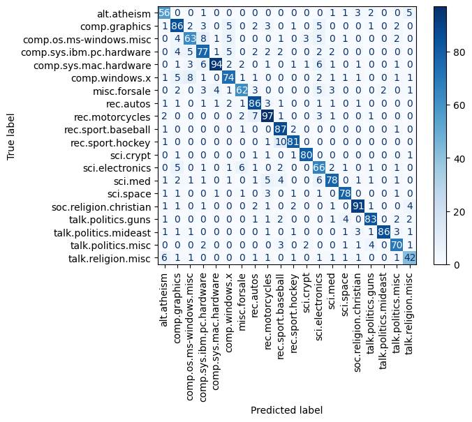

```python
# DO NOT CHANGE THIS CELL
plot_confusion_matrix(true, pred, classes=id2label.values())
```

### 6.3. Hinge Loss (5 points - Programming)

Read through the dataset documentation link provided with this notebook, or feel free to Google and read about 20 Newsgroups dataset, it's quite popular. If you try to understand the labels, they are more similar to some of them than others, semantically. For example, `talk.politics.mideast` is more closer to `talk.politics.misc` than `sci.space`.

Mathematically speaking, it means that misclassification of a label to some classes may be less penalizable than some other classes. This is the perfect scenario of using hinge loss.

The **hinge loss** is another loss function commonly used for classification, especially in **support vector machines (SVMs)**. It is designed to maximize the margin between the decision boundary and the closest data points from each class.

The hinge loss penalizes predictions based on how confident the model is about the correct class relative to other classes. It aims to push the score of the true class far above the scores of all other classes, ensuring that the model not only predicts the correct class but does so confidently.

For each input sample $x_i$, the model computes a score for each class. The hinge loss compares the score for the true class to the scores for all other classes and penalizes the model if the true class score is not sufficiently higher than the scores for the other classes.

Given a set of predictions from the model for a batch of samples, we denote:

- $\mathbf{y} \in \mathbb{R}^{B \times C}$: The matrix of predicted scores, where $B$ is the batch size and $C$ is the number of classes. Each row represents the predicted scores for one sample.
- $\mathbf{y}_{\text{true}} \in \{0, 1, \ldots, C-1\}^{B}$: The ground truth labels, where each entry is an integer representing the correct class label for each sample.

For a given sample ( i ), let:

- $s_j$ be the score for class $j$ (from the predicted score vector).
- $s_{\text{true}}$ be the score for the true class.
- $l(j, true)$ be the cost if a task instance belonging to $true$ has highest score for $j$

The **hinge loss** for a task instance ( x_i ) is defined as:

$$ L_{\text{hinge}}(i) = \max \left( 0, \max_j\left(s_j + l(j, true)\right) - s_{\text{true}}\right) $$

For batches, we compute the loss for each sample and take the mean over the batch to obtain a scalar value representing the average hinge loss.

HINT: The non-recommended solution is to use one loop. However, it is highly recommended to not do that for efficiency reasons. `torch.gather()` should be helpful.

```python
# export
class HingeLoss(nn.Module):
    def __init__(self, cost_matrix, device):
        super(HingeLoss, self).__init__()
        """
        cost_matrix is a 2D list. Convert it to a tensor on appropriate device.
        """
        # YOUR CODE STARTS HERE
        self.cost_matrix = torch.tensor(cost_matrix, device=device)
        # YOUR CODE ENDS HERE

    def forward(self, predictions, labels):
        """
        Calculate the hinge loss between predictions and labels, adjusting for cost.

        Args:
            predictions (torch.Tensor): The predictions from the model for a batch of inputs.
                                        Shape should be (batch_size, num_classes).
            labels (torch.Tensor): The ground truth labels for each input in the batch.
                                   Shape should be (batch_size,) with each value between 0 and num_classes-1.

        Returns:
            scalar: The mean hinge loss for the batch, adjusted for the defined cost.
        """
        # YOUR CODE STARTS HERE

        # Get the scores for the true labels with gather
        true_scores = predictions.gather(1, labels.unsqueeze(1))
        sample_cost = self.cost_matrix[labels]

        new_scores = predictions + sample_cost

        max_scores = torch.max(new_scores,axis=-1).values # Choose the max prediction for each sample

        error = max_scores.unsqueeze(-1) - true_scores # Find error between the chosen prediction and the true label
        loss = torch.mean(torch.clamp(error, min=0))  # Calculate the mean perceptron loss

        # YOUR CODE ENDS HERE
        return loss
```

```python
# DO NOT CHANGE THIS CELL
def test_correct_classification(hinge_loss):
    """
    Test case where the true class has the highest score.
    The loss should be 0.
    """
    rtol = 0.0001
    predictions = torch.tensor([[3.0, 2.0, 1.0],
                                [1.0, 4.0, 2.0]])
    labels = torch.tensor([0, 1])
    loss = hinge_loss(predictions, labels).item()
    expected_loss = 0.0
    if abs(expected_loss - loss) <= rtol * abs(expected_loss):
        print('Test case 1 passed')
    else:
        print(f"Test case 1 failed, expected value was\n{expected_loss}\nbut you got:\n{loss}")

def test_incorrect_classification(hinge_loss):
    """
    Test case where the true class does not have the highest score.
    The loss should be greater than 0.
    """
    rtol = 0.0001
    predictions = torch.tensor([[1.0, 3.0, 2.0],
                                [1.0, 2.0, 4.0]])
    labels = torch.tensor([0, 1])

    expected_loss = 3.0
    loss = hinge_loss(predictions, labels).item()

    if abs(expected_loss - loss) <= rtol * abs(expected_loss):
        print('Test case 2 passed')
    else:
        print(f"Test case 2 failed, expected value was\n{expected_loss}\nbut you got:\n{loss}")

cost_matrix = [[0, 1, 1], [1, 0, 1], [1, 1, 0]]
hinge_loss = HingeLoss(cost_matrix, device='cpu')
test_correct_classification(hinge_loss)
test_incorrect_classification(hinge_loss)
```

```
Test case 1 passed
Test case 2 passed
```

### 6.4. NBOW Training using Hinge Loss [3 points - Programming]

First, define a cost matrix. Take inspiration from the confusion matrix of `PerceptronLoss` results, `id2label` map and your knowledge of what dataset labels are. This will help is constructing a good cost matrix.

Credits will be awarded on the following cutoffs on Gradescope split -

- 0 points for accuracy <= 84%,
- 1 point for accuracy > 84% but <= 88%,
- 2 points for accuracy > 88%

```python
# export
def get_cost_matrix(num_classes=20):
    """
    Generates a cost matrix for a specified number of classes using Python lists.

    Args:
        num_classes (int): The number of classes for which the cost matrix is to be created.

    Returns:
        list of lists: A 2D list where element (i, j) is the absolute difference between i and j,
                       set to zero if i equals j.
    """

    # YOUR CODE STARTS HERE

    cost_matrix = [[0 if i == j else abs(i - j) for j in range(num_classes)] for i in range(num_classes)]

    # YOUR CODE ENDS HERE
    return cost_matrix
```

```python
# DO NOT CHANGE THIS CELL
def test_cost(matrix):
    n = len(matrix)

    # Check if the matrix is square
    for row in matrix:
        if len(row) != n:
            print('Incorrect cost matrix: Not a square matrix.')

    # Check for symmetry and zero diagonal elements
    for i in range(n):
        if matrix[i][i] != 0:
            print('Incorrect cost matrix: Diagonal elements are not zero.')

        for j in range(i + 1, n):
            if matrix[i][j] != matrix[j][i]:
                print('Incorrect cost matrix: Not a symmetric matrix.')

    print('Valid cost matrix')

cost_matrix = get_cost_matrix()
test_cost(cost_matrix)
```

```
Valid cost matrix
```

```python
# This is the main training loop. You'll need to complete the train_loop and val_loop functions.
# You'll also need to complete the criterion and optimizer functions.
# Feel free to experiment with different optimizers and learning rates.
# Do not change anything else in this cell
learning_rate, epochs, embedding_dim = get_hyperparams_nbow()
nbow_model = get_nbow_model(vocab_size= len(train_vocab.keys()), embedding_dim = embedding_dim).to(device)
cost_matrix = get_cost_matrix()
criterion = HingeLoss(cost_matrix, device=device)
optimizer = get_optimizer(nbow_model, learning_rate)
train_loss_over_time_hinge = []
val_loss_over_time_hinge = []
for epoch in range(epochs):
    train_loss = train_loop(nbow_model, criterion, optimizer, train_iterator, epoch, save_every=2)
    true, pred, val_loss = val_loop(nbow_model, criterion, val_iterator)
    accuracy, f1 = get_accuracy_and_f1_score(true, pred)
    train_loss_over_time_hinge.append(train_loss)
    val_loss_over_time_hinge.append(val_loss)
    print(f"Epoch {epoch+1} -- Train_Loss: {train_loss} -- Val_Loss: {val_loss} -- Val_Accuracy: {accuracy} -- Val_F1: {f1}")

save_checkpoint(nbow_model, 'nbow', loss_fn='hinge')
```

```
Epoch 1 -- Train_Loss: 12.822567858938443 -- Val_Loss: 11.315492757161458 -- Val_Accuracy: 0.06578249336870026 -- Val_F1: 0.028334500300375577
```

```
Epoch 2 -- Train_Loss: 10.227837748446706 -- Val_Loss: 9.876809946695964 -- Val_Accuracy: 0.04880636604774536 -- Val_F1: 0.0046535154274152755
```

```
Epoch 3 -- Train_Loss: 9.621304544351869 -- Val_Loss: 9.715019162495931 -- Val_Accuracy: 0.04880636604774536 -- Val_F1: 0.0046582278481012655
```

```
Epoch 4 -- Train_Loss: 9.455626495813918 -- Val_Loss: 9.507156244913737 -- Val_Accuracy: 0.0493368700265252 -- Val_F1: 0.0069675629534784456
```

```
Epoch 5 -- Train_Loss: 9.236305091340663 -- Val_Loss: 9.269581031799316 -- Val_Accuracy: 0.05994694960212202 -- Val_F1: 0.014336147015025818
```

```
Epoch 6 -- Train_Loss: 8.925018961146726 -- Val_Loss: 8.901194445292155 -- Val_Accuracy: 0.06843501326259947 -- Val_F1: 0.02118774125236837
```

```
Epoch 7 -- Train_Loss: 8.529544066574614 -- Val_Loss: 8.47425724665324 -- Val_Accuracy: 0.1013262599469496 -- Val_F1: 0.053993900012006435
```

```
Epoch 8 -- Train_Loss: 8.065474102052592 -- Val_Loss: 7.979003524780273 -- Val_Accuracy: 0.14376657824933686 -- Val_F1: 0.06660189766547467
```

```
Epoch 9 -- Train_Loss: 7.590197643991244 -- Val_Loss: 7.540601476033529 -- Val_Accuracy: 0.1559681697612732 -- Val_F1: 0.0785962169615626
```

```
Epoch 10 -- Train_Loss: 7.132045123536708 -- Val_Loss: 7.087942759195964 -- Val_Accuracy: 0.1830238726790451 -- Val_F1: 0.10261463870369032
```

```
Epoch 11 -- Train_Loss: 6.645686832524962 -- Val_Loss: 6.619022496541342 -- Val_Accuracy: 0.21644562334217507 -- Val_F1: 0.13996005200145795
```

```
Epoch 12 -- Train_Loss: 6.132586786302469 -- Val_Loss: 6.104597568511963 -- Val_Accuracy: 0.26790450928381965 -- Val_F1: 0.19043593464880174
```

```
Epoch 13 -- Train_Loss: 5.621441247099537 -- Val_Loss: 5.610317230224609 -- Val_Accuracy: 0.3363395225464191 -- Val_F1: 0.23963314348049486
```

```
Epoch 14 -- Train_Loss: 5.1399625782239236 -- Val_Loss: 5.185934003194173 -- Val_Accuracy: 0.37984084880636604 -- Val_F1: 0.28639972329253066
```

```
Epoch 15 -- Train_Loss: 4.709426101991686 -- Val_Loss: 4.833316135406494 -- Val_Accuracy: 0.4307692307692308 -- Val_F1: 0.3409039193258467
```

```
Epoch 16 -- Train_Loss: 4.321439484418449 -- Val_Loss: 4.530300521850586 -- Val_Accuracy: 0.48116710875331564 -- Val_F1: 0.39329292209079786
```

```
Epoch 17 -- Train_Loss: 3.97265469219725 -- Val_Loss: 4.244301478068034 -- Val_Accuracy: 0.5156498673740053 -- Val_F1: 0.42867972606501387
```

```
Epoch 18 -- Train_Loss: 3.660446365000838 -- Val_Loss: 3.98353541692098 -- Val_Accuracy: 0.5559681697612732 -- Val_F1: 0.4672736660548959
```

```
Epoch 19 -- Train_Loss: 3.3769614555067937 -- Val_Loss: 3.7657691637674966 -- Val_Accuracy: 0.5803713527851458 -- Val_F1: 0.49283309914134643
```

```
Epoch 20 -- Train_Loss: 3.1218702186972407 -- Val_Loss: 3.5820656140645344 -- Val_Accuracy: 0.6005305039787798 -- Val_F1: 0.51707411569615
```

```
Epoch 21 -- Train_Loss: 2.8851845365459634 -- Val_Loss: 3.396574529012044 -- Val_Accuracy: 0.6228116710875331 -- Val_F1: 0.542121640581216
```

```
Epoch 22 -- Train_Loss: 2.668440206576202 -- Val_Loss: 3.234607235590617 -- Val_Accuracy: 0.6440318302387268 -- Val_F1: 0.5682064535650978
```

```
Epoch 23 -- Train_Loss: 2.4634364014964993 -- Val_Loss: 3.0924575169881185 -- Val_Accuracy: 0.6673740053050398 -- Val_F1: 0.6011343373229306
```

```
Epoch 24 -- Train_Loss: 2.2737783638097473 -- Val_Loss: 2.9619792540868124 -- Val_Accuracy: 0.683289124668435 -- Val_F1: 0.6256985303751431
```

```
Epoch 25 -- Train_Loss: 2.1006125484482716 -- Val_Loss: 2.831187907854716 -- Val_Accuracy: 0.6970822281167108 -- Val_F1: 0.6420699836045758
```

```
Epoch 26 -- Train_Loss: 1.9416542800806336 -- Val_Loss: 2.711762221654256 -- Val_Accuracy: 0.7050397877984085 -- Val_F1: 0.6532449474528486
```

```
Epoch 27 -- Train_Loss: 1.7975223034115162 -- Val_Loss: 2.604963254928589 -- Val_Accuracy: 0.7278514588859416 -- Val_F1: 0.6805184323657405
```

```
Epoch 28 -- Train_Loss: 1.6619035823870514 -- Val_Loss: 2.537539807955424 -- Val_Accuracy: 0.7411140583554376 -- Val_F1: 0.7003706985413231
```

```
Epoch 29 -- Train_Loss: 1.5371674157805362 -- Val_Loss: 2.422160251935323 -- Val_Accuracy: 0.7522546419098143 -- Val_F1: 0.714330402185371
```

```
Epoch 30 -- Train_Loss: 1.4223532984822482 -- Val_Loss: 2.347158257166545 -- Val_Accuracy: 0.7660477453580902 -- Val_F1: 0.7317755460381139
```

```
Epoch 31 -- Train_Loss: 1.3141013126252061 -- Val_Loss: 2.2960458596547446 -- Val_Accuracy: 0.7851458885941645 -- Val_F1: 0.7537730157341909
```

```
Epoch 32 -- Train_Loss: 1.2169737669370941 -- Val_Loss: 2.2162313063939414 -- Val_Accuracy: 0.7984084880636605 -- Val_F1: 0.7713635895725425
```

```
Epoch 33 -- Train_Loss: 1.1278830291861195 -- Val_Loss: 2.1627811431884765 -- Val_Accuracy: 0.8090185676392573 -- Val_F1: 0.7860114483469818
```

```
Epoch 34 -- Train_Loss: 1.0450439821865598 -- Val_Loss: 2.1177306254704793 -- Val_Accuracy: 0.8249336870026526 -- Val_F1: 0.8053948148560572
```

```
Epoch 35 -- Train_Loss: 0.9693592746379012 -- Val_Loss: 2.080010946591695 -- Val_Accuracy: 0.83342175066313 -- Val_F1: 0.8175594754058318
```

```
Epoch 36 -- Train_Loss: 0.9002076119689618 -- Val_Loss: 2.0215991894404093 -- Val_Accuracy: 0.8392572944297082 -- Val_F1: 0.8229918029865649
```

```
Epoch 37 -- Train_Loss: 0.8372303835921369 -- Val_Loss: 1.9719367345174155 -- Val_Accuracy: 0.8424403183023873 -- Val_F1: 0.8301876995036708
```

```
Epoch 38 -- Train_Loss: 0.7758314197851439 -- Val_Loss: 1.9317633549372355 -- Val_Accuracy: 0.8456233421750663 -- Val_F1: 0.8339794168954455
```

```
Epoch 39 -- Train_Loss: 0.7233235088445372 -- Val_Loss: 1.9111244599024455 -- Val_Accuracy: 0.8503978779840848 -- Val_F1: 0.8386651970908346
```

```
Epoch 40 -- Train_Loss: 0.6739362372180163 -- Val_Loss: 1.8780554453531901 -- Val_Accuracy: 0.8525198938992042 -- Val_F1: 0.8411286971579948
```

```
Epoch 41 -- Train_Loss: 0.6285440851066072 -- Val_Loss: 1.859329382578532 -- Val_Accuracy: 0.8572944297082228 -- Val_F1: 0.8483577197301049
```

```
Epoch 42 -- Train_Loss: 0.5869158748853005 -- Val_Loss: 1.8368451992670696 -- Val_Accuracy: 0.859946949602122 -- Val_F1: 0.8527675922650442
```

```
Epoch 43 -- Train_Loss: 0.54797674475585 -- Val_Loss: 1.8099033991495768 -- Val_Accuracy: 0.8647214854111406 -- Val_F1: 0.8576254021135681
```

```
Epoch 44 -- Train_Loss: 0.5110856795967635 -- Val_Loss: 1.7870356559753418 -- Val_Accuracy: 0.8657824933687003 -- Val_F1: 0.8593644372546434
```

```
Epoch 45 -- Train_Loss: 0.47692262722274004 -- Val_Loss: 1.7676843484242757 -- Val_Accuracy: 0.8647214854111406 -- Val_F1: 0.858298612829039
```

```
Epoch 46 -- Train_Loss: 0.4455988092695252 -- Val_Loss: 1.7694646835327148 -- Val_Accuracy: 0.8641909814323607 -- Val_F1: 0.858702731939055
```

```
Epoch 47 -- Train_Loss: 0.41715533494696777 -- Val_Loss: 1.735552461942037 -- Val_Accuracy: 0.8657824933687003 -- Val_F1: 0.8609219413615925
```

```
Epoch 48 -- Train_Loss: 0.38936222199413734 -- Val_Loss: 1.7347072919209798 -- Val_Accuracy: 0.8679045092838197 -- Val_F1: 0.8633196657283791
```

```
Epoch 49 -- Train_Loss: 0.36409571735283075 -- Val_Loss: 1.7220308462778726 -- Val_Accuracy: 0.8694960212201591 -- Val_F1: 0.8658649085838706
```

```
Epoch 50 -- Train_Loss: 0.3403160308756061 -- Val_Loss: 1.7102900266647338 -- Val_Accuracy: 0.8710875331564987 -- Val_F1: 0.8676827035635156
```

```
Epoch 51 -- Train_Loss: 0.31771525974243375 -- Val_Loss: 1.6984666506449382 -- Val_Accuracy: 0.8716180371352785 -- Val_F1: 0.8681201634563788
```

```
Epoch 52 -- Train_Loss: 0.29704461619257927 -- Val_Loss: 1.681996258099874 -- Val_Accuracy: 0.8748010610079575 -- Val_F1: 0.8711577387699562
```

```
Epoch 53 -- Train_Loss: 0.27714476336614563 -- Val_Loss: 1.6844743728637694 -- Val_Accuracy: 0.8763925729442971 -- Val_F1: 0.87379756000275
```

```
Epoch 54 -- Train_Loss: 0.2587659497571699 -- Val_Loss: 1.6744562149047852 -- Val_Accuracy: 0.880106100795756 -- Val_F1: 0.8780824017173211
```

```
Epoch 55 -- Train_Loss: 0.2415712497875852 -- Val_Loss: 1.6553011894226075 -- Val_Accuracy: 0.880106100795756 -- Val_F1: 0.8781711859481887
```

```
Epoch 56 -- Train_Loss: 0.2262439762194783 -- Val_Loss: 1.6381324648857116 -- Val_Accuracy: 0.8816976127320955 -- Val_F1: 0.8801976050178626
```

```
Epoch 57 -- Train_Loss: 0.21095782865659665 -- Val_Loss: 1.6448908964792888 -- Val_Accuracy: 0.8822281167108753 -- Val_F1: 0.8808142332074504
```

```
Epoch 58 -- Train_Loss: 0.1973757110220396 -- Val_Loss: 1.6412116130193075 -- Val_Accuracy: 0.8822281167108753 -- Val_F1: 0.8810307380284705
```

```
Epoch 59 -- Train_Loss: 0.18470371454575304 -- Val_Loss: 1.6318106969197592 -- Val_Accuracy: 0.883289124668435 -- Val_F1: 0.8823604990121993
```

```
Epoch 60 -- Train_Loss: 0.17268368971171016 -- Val_Loss: 1.6220127105712892 -- Val_Accuracy: 0.8838196286472149 -- Val_F1: 0.8827406287349172
```

```
Epoch 61 -- Train_Loss: 0.1615501434810586 -- Val_Loss: 1.6225858211517334 -- Val_Accuracy: 0.8854111405835544 -- Val_F1: 0.8844915109207108
```

```
Epoch 62 -- Train_Loss: 0.1512136942059812 -- Val_Loss: 1.6227510452270508 -- Val_Accuracy: 0.8870026525198939 -- Val_F1: 0.8862715181800664
```

```
Epoch 63 -- Train_Loss: 0.1410648625470319 -- Val_Loss: 1.6081034262975058 -- Val_Accuracy: 0.8891246684350133 -- Val_F1: 0.8884729192296582
```

```
Epoch 64 -- Train_Loss: 0.131885875647856 -- Val_Loss: 1.6126112858454387 -- Val_Accuracy: 0.890185676392573 -- Val_F1: 0.889679267667265
```

```
Epoch 65 -- Train_Loss: 0.12371887279263998 -- Val_Loss: 1.5908252477645874 -- Val_Accuracy: 0.8896551724137931 -- Val_F1: 0.8887858552216817
```

```
Epoch 66 -- Train_Loss: 0.11541184328370176 -- Val_Loss: 1.5925499121348063 -- Val_Accuracy: 0.8864721485411141 -- Val_F1: 0.8858224864612201
```

```
Epoch 67 -- Train_Loss: 0.1084232124168489 -- Val_Loss: 1.581755805015564 -- Val_Accuracy: 0.8880636604774536 -- Val_F1: 0.8872174063423894
```

```
Epoch 68 -- Train_Loss: 0.1019464998932208 -- Val_Loss: 1.5769067366917928 -- Val_Accuracy: 0.8864721485411141 -- Val_F1: 0.8857624643763391
```

```
Epoch 69 -- Train_Loss: 0.09529034872302565 -- Val_Loss: 1.5723983287811278 -- Val_Accuracy: 0.8896551724137931 -- Val_F1: 0.8886882215933616
```

```
Epoch 70 -- Train_Loss: 0.08924342938146348 -- Val_Loss: 1.560322066148122 -- Val_Accuracy: 0.8885941644562334 -- Val_F1: 0.887253475987188
```

```
Epoch 71 -- Train_Loss: 0.08376437410222903 -- Val_Loss: 1.5867279887199401 -- Val_Accuracy: 0.8891246684350133 -- Val_F1: 0.8883917634511953
```

```
Epoch 72 -- Train_Loss: 0.07857971630548521 -- Val_Loss: 1.5585437933603923 -- Val_Accuracy: 0.8896551724137931 -- Val_F1: 0.8882395001454324
```

```
Epoch 73 -- Train_Loss: 0.07392802627725621 -- Val_Loss: 1.5640965342521667 -- Val_Accuracy: 0.890185676392573 -- Val_F1: 0.8893560081236622
```

```
Epoch 74 -- Train_Loss: 0.06937333272170212 -- Val_Loss: 1.557248632113139 -- Val_Accuracy: 0.8912466843501327 -- Val_F1: 0.8900064193438789
```

```
Epoch 75 -- Train_Loss: 0.06561267821086665 -- Val_Loss: 1.5668368021647134 -- Val_Accuracy: 0.8928381962864721 -- Val_F1: 0.8916623351382411
```

```
Epoch 76 -- Train_Loss: 0.06178874759224512 -- Val_Loss: 1.5516162872314454 -- Val_Accuracy: 0.890185676392573 -- Val_F1: 0.8891773386560409
```

```
Epoch 77 -- Train_Loss: 0.057689710336705766 -- Val_Loss: 1.5519156614939371 -- Val_Accuracy: 0.8907161803713528 -- Val_F1: 0.8898743830343875
```

```
Epoch 78 -- Train_Loss: 0.05444035166085272 -- Val_Loss: 1.5502276460329691 -- Val_Accuracy: 0.8917771883289125 -- Val_F1: 0.8906587321171948
```

```
Epoch 79 -- Train_Loss: 0.05149908228067018 -- Val_Loss: 1.5518574158350626 -- Val_Accuracy: 0.8907161803713528 -- Val_F1: 0.8894268359938234
```

```
Epoch 80 -- Train_Loss: 0.0481814430845049 -- Val_Loss: 1.5418299674987792 -- Val_Accuracy: 0.8907161803713528 -- Val_F1: 0.8898418586525525
```

```
Epoch 81 -- Train_Loss: 0.0457786554648241 -- Val_Loss: 1.5554577271143595 -- Val_Accuracy: 0.8907161803713528 -- Val_F1: 0.8897630522810255
```

```
Epoch 82 -- Train_Loss: 0.043425491805803976 -- Val_Loss: 1.5374003370602927 -- Val_Accuracy: 0.890185676392573 -- Val_F1: 0.8886680048267742
```

```
Epoch 83 -- Train_Loss: 0.04076593938903682 -- Val_Loss: 1.5474582274754842 -- Val_Accuracy: 0.890185676392573 -- Val_F1: 0.8886767376079545
```

```
Epoch 84 -- Train_Loss: 0.03877464429301731 -- Val_Loss: 1.539605196317037 -- Val_Accuracy: 0.8885941644562334 -- Val_F1: 0.887109237006604
```

```
Epoch 85 -- Train_Loss: 0.03709093096145129 -- Val_Loss: 1.5439618825912476 -- Val_Accuracy: 0.8891246684350133 -- Val_F1: 0.8875084960628443
```

```
Epoch 86 -- Train_Loss: 0.034817406970818164 -- Val_Loss: 1.5207699894905091 -- Val_Accuracy: 0.8880636604774536 -- Val_F1: 0.8866201231590475
```

```
Epoch 87 -- Train_Loss: 0.033337472764364745 -- Val_Loss: 1.5323675711949667 -- Val_Accuracy: 0.8891246684350133 -- Val_F1: 0.8876197302595334
```

```
Epoch 88 -- Train_Loss: 0.031697671986737494 -- Val_Loss: 1.5377460718154907 -- Val_Accuracy: 0.8896551724137931 -- Val_F1: 0.8882194835603597
```

```
Epoch 89 -- Train_Loss: 0.030311842938348398 -- Val_Loss: 1.5158949335416159 -- Val_Accuracy: 0.8885941644562334 -- Val_F1: 0.8872108568903296
```

```
Epoch 90 -- Train_Loss: 0.028670933823716844 -- Val_Loss: 1.5150840322176615 -- Val_Accuracy: 0.8875331564986737 -- Val_F1: 0.8861003726336584
```

```
Epoch 91 -- Train_Loss: 0.02722621001934601 -- Val_Loss: 1.5269769271214804 -- Val_Accuracy: 0.8885941644562334 -- Val_F1: 0.887144306510487
```

```
Epoch 92 -- Train_Loss: 0.026208929389259398 -- Val_Loss: 1.5148270050684611 -- Val_Accuracy: 0.8880636604774536 -- Val_F1: 0.8865941074138204
```

```
Epoch 93 -- Train_Loss: 0.025216618108847257 -- Val_Loss: 1.529653529326121 -- Val_Accuracy: 0.8859416445623343 -- Val_F1: 0.8845718165431722
```

```
Epoch 94 -- Train_Loss: 0.024218814605373448 -- Val_Loss: 1.5122645934422811 -- Val_Accuracy: 0.8843501326259947 -- Val_F1: 0.8828435083604826
```

```
Epoch 95 -- Train_Loss: 0.023577132941050044 -- Val_Loss: 1.5102603832880657 -- Val_Accuracy: 0.8875331564986737 -- Val_F1: 0.8861351844065121
```

```
Epoch 96 -- Train_Loss: 0.022864919061125335 -- Val_Loss: 1.5120897968610127 -- Val_Accuracy: 0.8880636604774536 -- Val_F1: 0.8867443741081132
```

```
Epoch 97 -- Train_Loss: 0.022281317419167293 -- Val_Loss: 1.519298529624939 -- Val_Accuracy: 0.8875331564986737 -- Val_F1: 0.8860195388651683
```

```
Epoch 98 -- Train_Loss: 0.021572538351608536 -- Val_Loss: 1.5060020287831624 -- Val_Accuracy: 0.8880636604774536 -- Val_F1: 0.8868141770701303
```

```
Epoch 99 -- Train_Loss: 0.02126987995106285 -- Val_Loss: 1.5051746845245362 -- Val_Accuracy: 0.8880636604774536 -- Val_F1: 0.8866244143351555
```

```
Epoch 100 -- Train_Loss: 0.02062991709779885 -- Val_Loss: 1.5019494652748109 -- Val_Accuracy: 0.883289124668435 -- Val_F1: 0.8818884730417642
```

```
Epoch 101 -- Train_Loss: 0.02018899950435606 -- Val_Loss: 1.4917221625645956 -- Val_Accuracy: 0.8864721485411141 -- Val_F1: 0.8855407865621656
```

```
Epoch 102 -- Train_Loss: 0.01960382140162638 -- Val_Loss: 1.5116058309872946 -- Val_Accuracy: 0.8891246684350133 -- Val_F1: 0.8879598806273273
```

```
Epoch 103 -- Train_Loss: 0.019384468321577978 -- Val_Loss: 1.5104292392730714 -- Val_Accuracy: 0.8859416445623343 -- Val_F1: 0.8846542132326352
```

```
Epoch 104 -- Train_Loss: 0.018890473960062205 -- Val_Loss: 1.4894563198089599 -- Val_Accuracy: 0.8864721485411141 -- Val_F1: 0.8847154919137422
```

```
Epoch 105 -- Train_Loss: 0.018374615048958085 -- Val_Loss: 1.4866228540738424 -- Val_Accuracy: 0.8859416445623343 -- Val_F1: 0.8849105533682735
```

```
Epoch 106 -- Train_Loss: 0.018081123009324074 -- Val_Loss: 1.5025888125101725 -- Val_Accuracy: 0.8875331564986737 -- Val_F1: 0.8862514540603812
```

```
Epoch 107 -- Train_Loss: 0.017689797184976992 -- Val_Loss: 1.4780930161476136 -- Val_Accuracy: 0.8859416445623343 -- Val_F1: 0.884879067378234
```

```
Epoch 108 -- Train_Loss: 0.017278889446692952 -- Val_Loss: 1.4771368662516275 -- Val_Accuracy: 0.8891246684350133 -- Val_F1: 0.8874627078072095
```

```
Epoch 109 -- Train_Loss: 0.016923258128433913 -- Val_Loss: 1.4803272803624472 -- Val_Accuracy: 0.8885941644562334 -- Val_F1: 0.8871463658644746
```

```
Epoch 110 -- Train_Loss: 0.01650916305133852 -- Val_Loss: 1.4850383520126342 -- Val_Accuracy: 0.8848806366047746 -- Val_F1: 0.8834770380016822
```

```
Epoch 111 -- Train_Loss: 0.015939774433687583 -- Val_Loss: 1.4773202498753866 -- Val_Accuracy: 0.8854111405835544 -- Val_F1: 0.8839502998960196
```

```
Epoch 112 -- Train_Loss: 0.015427805199208906 -- Val_Loss: 1.4802019039789835 -- Val_Accuracy: 0.8875331564986737 -- Val_F1: 0.8867598946026624
```

```
Epoch 113 -- Train_Loss: 0.015105267513101385 -- Val_Loss: 1.4682840347290038 -- Val_Accuracy: 0.8880636604774536 -- Val_F1: 0.8865139791104596
```

```
Epoch 114 -- Train_Loss: 0.014936470284552897 -- Val_Loss: 1.4723984360694886 -- Val_Accuracy: 0.8864721485411141 -- Val_F1: 0.885276964304861
```

```
Epoch 115 -- Train_Loss: 0.014532025240487972 -- Val_Loss: 1.4733437498410542 -- Val_Accuracy: 0.8864721485411141 -- Val_F1: 0.8855116542783286
```

```
Epoch 116 -- Train_Loss: 0.014395200663198859 -- Val_Loss: 1.4768187522888183 -- Val_Accuracy: 0.8848806366047746 -- Val_F1: 0.8838260292631782
```

```
Epoch 117 -- Train_Loss: 0.013848761696431596 -- Val_Loss: 1.4680209159851074 -- Val_Accuracy: 0.883289124668435 -- Val_F1: 0.8820857765256018
```

```
Epoch 118 -- Train_Loss: 0.013842197766495963 -- Val_Loss: 1.4508552471796672 -- Val_Accuracy: 0.8864721485411141 -- Val_F1: 0.8850206370520581
```

```
Epoch 119 -- Train_Loss: 0.01334609249725117 -- Val_Loss: 1.4597716649373373 -- Val_Accuracy: 0.8854111405835544 -- Val_F1: 0.8840806805343895
```

```
Epoch 120 -- Train_Loss: 0.013126693129286928 -- Val_Loss: 1.4553979992866517 -- Val_Accuracy: 0.8870026525198939 -- Val_F1: 0.8862268192122388
```

```
Epoch 121 -- Train_Loss: 0.012785037379648726 -- Val_Loss: 1.4695375363032024 -- Val_Accuracy: 0.8885941644562334 -- Val_F1: 0.8874652309529202
```

```
Epoch 122 -- Train_Loss: 0.012551663980140524 -- Val_Loss: 1.4609747807184854 -- Val_Accuracy: 0.8885941644562334 -- Val_F1: 0.8874431789517401
```

```
Epoch 123 -- Train_Loss: 0.012410041643306613 -- Val_Loss: 1.4487648447354635 -- Val_Accuracy: 0.8875331564986737 -- Val_F1: 0.8865175121306563
```

```
Epoch 124 -- Train_Loss: 0.011954858772835489 -- Val_Loss: 1.4454883694648744 -- Val_Accuracy: 0.8891246684350133 -- Val_F1: 0.8876763026539691
```

```
Epoch 125 -- Train_Loss: 0.011719915005615202 -- Val_Loss: 1.4507636030515034 -- Val_Accuracy: 0.8880636604774536 -- Val_F1: 0.8865964051052158
```

```
Epoch 126 -- Train_Loss: 0.011148395395632518 -- Val_Loss: 1.4577593525250754 -- Val_Accuracy: 0.8891246684350133 -- Val_F1: 0.8877229119657786
```

```
Epoch 127 -- Train_Loss: 0.011058673862431008 -- Val_Loss: 1.4627264102300008 -- Val_Accuracy: 0.8880636604774536 -- Val_F1: 0.8873939146943991
```

```
Epoch 128 -- Train_Loss: 0.010845343313984951 -- Val_Loss: 1.4351863702138266 -- Val_Accuracy: 0.8875331564986737 -- Val_F1: 0.8862011934018053
```

```
Epoch 129 -- Train_Loss: 0.01028039641046928 -- Val_Loss: 1.439449127515157 -- Val_Accuracy: 0.8880636604774536 -- Val_F1: 0.8869718917088344
```

```
Epoch 130 -- Train_Loss: 0.010041915259118808 -- Val_Loss: 1.4564919153849283 -- Val_Accuracy: 0.8885941644562334 -- Val_F1: 0.8875903361044193
```

```
Epoch 131 -- Train_Loss: 0.009867274819259626 -- Val_Loss: 1.4285914659500123 -- Val_Accuracy: 0.8838196286472149 -- Val_F1: 0.8822869011543671
```

```
Epoch 132 -- Train_Loss: 0.0095541342122133 -- Val_Loss: 1.435871962706248 -- Val_Accuracy: 0.8885941644562334 -- Val_F1: 0.8876892774061889
```

```
Epoch 133 -- Train_Loss: 0.009157378100237604 -- Val_Loss: 1.4472602009773254 -- Val_Accuracy: 0.8848806366047746 -- Val_F1: 0.8831459643143699
```

```
Epoch 134 -- Train_Loss: 0.00879663439226826 -- Val_Loss: 1.426039711634318 -- Val_Accuracy: 0.8859416445623343 -- Val_F1: 0.8845021205125564
```

```
Epoch 135 -- Train_Loss: 0.008558241939527315 -- Val_Loss: 1.4203874349594117 -- Val_Accuracy: 0.8880636604774536 -- Val_F1: 0.8864849174135232
```

```
Epoch 136 -- Train_Loss: 0.008547875525082573 -- Val_Loss: 1.4362435738245647 -- Val_Accuracy: 0.8880636604774536 -- Val_F1: 0.886037694462747
```

```
Epoch 137 -- Train_Loss: 0.00782985499097129 -- Val_Loss: 1.4389426231384277 -- Val_Accuracy: 0.8848806366047746 -- Val_F1: 0.8830898003799197
```

```
Epoch 138 -- Train_Loss: 0.007788790989730318 -- Val_Loss: 1.4249824682871501 -- Val_Accuracy: 0.8859416445623343 -- Val_F1: 0.8849443727473915
```

```
Epoch 139 -- Train_Loss: 0.007581018227136741 -- Val_Loss: 1.4327728748321533 -- Val_Accuracy: 0.8864721485411141 -- Val_F1: 0.8853222807233525
```

```
Epoch 140 -- Train_Loss: 0.00726679466285948 -- Val_Loss: 1.4420618454615275 -- Val_Accuracy: 0.8875331564986737 -- Val_F1: 0.8861577926271351
```

```
Epoch 141 -- Train_Loss: 0.007251345789280988 -- Val_Loss: 1.434883419672648 -- Val_Accuracy: 0.8875331564986737 -- Val_F1: 0.8861125916116336
```

```
Epoch 142 -- Train_Loss: 0.006897121131167573 -- Val_Loss: 1.4210756222407024 -- Val_Accuracy: 0.8870026525198939 -- Val_F1: 0.8857772462371196
```

```
Epoch 143 -- Train_Loss: 0.006405512028831547 -- Val_Loss: 1.4268697222073874 -- Val_Accuracy: 0.8864721485411141 -- Val_F1: 0.8845944966085544
```

```
Epoch 144 -- Train_Loss: 0.006222364192796966 -- Val_Loss: 1.4277719974517822 -- Val_Accuracy: 0.8880636604774536 -- Val_F1: 0.8868972638142468
```

```
Epoch 145 -- Train_Loss: 0.00586615045065597 -- Val_Loss: 1.4265238364537558 -- Val_Accuracy: 0.8880636604774536 -- Val_F1: 0.8871168867605711
```

```
Epoch 146 -- Train_Loss: 0.005846796746728784 -- Val_Loss: 1.4457480470339457 -- Val_Accuracy: 0.8891246684350133 -- Val_F1: 0.8878839567009793
```

```
Epoch 147 -- Train_Loss: 0.005466785345037105 -- Val_Loss: 1.4385912497838338 -- Val_Accuracy: 0.8870026525198939 -- Val_F1: 0.885393481879912
```

```
Epoch 148 -- Train_Loss: 0.005253101746409626 -- Val_Loss: 1.4205718080202738 -- Val_Accuracy: 0.8885941644562334 -- Val_F1: 0.8868235058663927
```

```
Epoch 149 -- Train_Loss: 0.005126863939024635 -- Val_Loss: 1.4109139283498129 -- Val_Accuracy: 0.8864721485411141 -- Val_F1: 0.8851317793872351
```

```
Epoch 150 -- Train_Loss: 0.004988150702694715 -- Val_Loss: 1.4203922112782796 -- Val_Accuracy: 0.8854111405835544 -- Val_F1: 0.8841921418865224
Checkpoint saved to /home/jblevins32/NLP_HW1/model_weights/checkpoint_nbow_hinge.pt
```

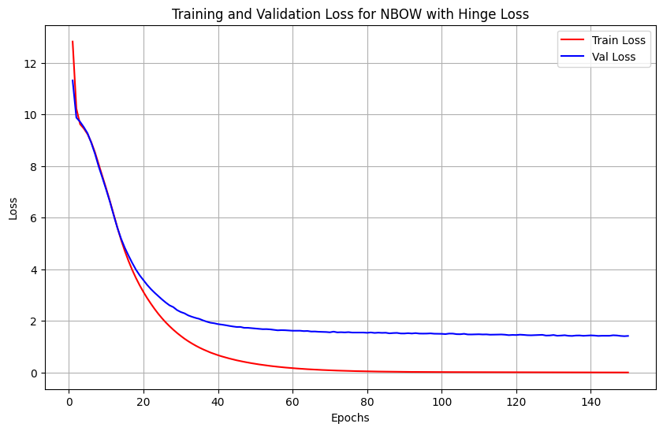

```python
# DO NOT CHANGE THIS CELL
plot_loss(train_loss_over_time_hinge, val_loss_over_time_hinge, 'NBOW with Hinge Loss')
```

```python
# DO NOT CHANGE THIS CELL
# load best model from checkpoint
learning_rate, epochs, embedding_dim = get_hyperparams_nbow()
nbow_model = get_nbow_model(vocab_size= len(train_vocab.keys()), embedding_dim = embedding_dim).to(device)
load_checkpoint(nbow_model, 'nbow', 'hinge', map_location=device)

# evaluate model
true, pred, val_loss = val_loop(nbow_model, criterion, val_iterator)
accuracy, f1 = get_accuracy_and_f1_score(true, pred)
print(f"Final Validation Accuracy: {accuracy}")
print(f"Final Validation F1-Score: {f1}")
```

```
Final Validation Accuracy: 0.8854111405835544
Final Validation F1-Score: 0.8841921418865224
```

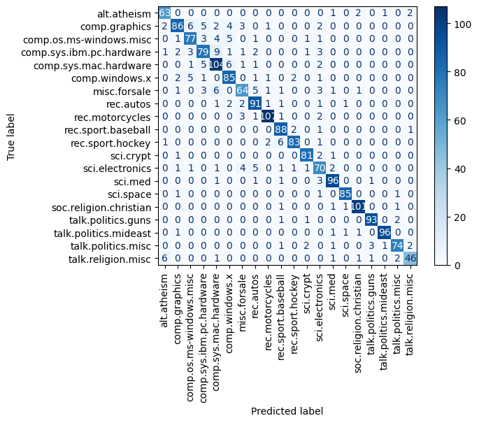

```python
# DO NOT CHANGE THIS CELL
plot_confusion_matrix(true, pred, classes=id2label.values())
```